# Análisis base de datos reducida

Daniel Miranda, Julio Iturra, Anaís Herrera y Kevin Carrasco

26-01-2021

```r
pacman::p_load(stargazer, ggplot2, sjmisc, car, sjlabelled, haven, cowplot,
               sjPlot, summarytools, kableExtra, corrplot, coefplot, ltm, polycor,
               psych, lme4, ppcor, texreg, skimr, gtools, bda, lmerTest, Matrix, extrafont, sessioninfo, dplyr,
               mediation, fastDummies)
```

# Cargar base

```r
load("../input/data-proc/data.rda")
```

```r
data_proc=data %>%
  dplyr::select(
    igualdad.est,
    esp_publico.est,
    esp_privado.est,
    Sexo,
    ap_discusion,
    mean_discusion,
    num_fem,
    RBD,
    igualdad.pad,
    esp_publico.pad,
    esp_privado.pad,
    Educacion,
    Libros_apod,
    Libros_apod_rec,
    quintiles_ingresos_pc_factor,
    dependencia,
    REGION,
    c_civic
  ) %>% as.data.frame()
data_proc <- na.omit(data_proc)
save(data_proc, file = "../input/data-proc/data_proc.rda")
```

# Descriptivos

```r
data_proc$igualdad.est <- set_label(x = data_proc$igualdad.est,label = "Actitudes del estudiante hacia la igualdad de género")
data_proc$esp_publico.est <- set_label(x = data_proc$esp_publico.est,label = "Actitudes del estudiante hacia la distribución igualitaria de roles en la esfera pública")
data_proc$esp_privado.est <- set_label(x = data_proc$esp_privado.est,label = "Actitudes del estudiante hacia la distribución igualitaria de roles en la esfera privada")
data_proc$igualdad.pad <- set_label(x = data_proc$igualdad.pad,label = "Actitudes del apoderado hacia la igualdad de género")
data_proc$esp_publico.pad <- set_label(x = data_proc$esp_publico.pad,label = "Actitudes del apoderado hacia la distribución igualitaria de roles en la esfera pública")
data_proc$esp_privado.pad <- set_label(x = data_proc$esp_privado.pad,label = "Actitudes del apoderado hacia la distribución igualitaria de roles en la esfera privada")
data_proc$Sexo <- set_label(x = data_proc$Sexo,label = "Sexo del estudiante")
data_proc$Educacion <- set_label(x = data_proc$Educacion,label = "Nivel educacional apoderado/a") # Etiquetar variable
data_proc$Libros_apod_rec <- set_label(x = data_proc$Libros_apod_rec,label = "Cantidad de libros en el hogar")
data_proc$quintiles_ingresos_pc_factor <- set_label(x = data_proc$quintiles_ingresos_pc_factor, label = "Ingresos per cápita del hogar en quintiles")
data_proc$ap_discusion <- set_label(x = data_proc$ap_discusion,label = "Percepción individual sobre la apertura a la discusión en el aula")
data_proc$mean_discusion <- set_label(x = data_proc$mean_discusion,label = "Percepción promedio del curso sobre la apertura a la discusión en el aula")
data_proc$num_fem <- set_label(x = data_proc$num_fem,label = "Proporción de niñas en el aula")
data_proc$dependencia <- set_label(x=data_proc$dependencia, label = "Dependencia administrativa de la escuela")
data_proc$REGION <- set_label(x=data_proc$REGION, label = "Región")
data_proc$c_civic <- set_label(x = data_proc$c_civic, label = "Conocimiento cívico conceptual")

descr <-
  data_proc %>%
  dplyr::select(
    igualdad.est,
    esp_publico.est,
    esp_privado.est,
    Sexo,
    ap_discusion,
    mean_discusion,
    num_fem,
    igualdad.pad,
    esp_publico.pad,
    esp_privado.pad,
    Educacion,
    Libros_apod_rec,
    quintiles_ingresos_pc_factor,
    dependencia,
    REGION,
    c_civic
  ) %>% ungroup()
st_css()
```

```r
print(dfSummary(descr,
               plain.ascii = FALSE,
               style = "grid",
               tmp.img.dir = "/tmp",
               graph.magnif = 0.75,
               headings = F,  # encabezado
               varnumbers = F, # num variable
               labels.col = T, # etiquetas
               na.col = T,    # missing
               graph.col = T, # plot
               valid.col = T, # n valido
               # col.widths = c(5,5,10,10,10,10)
               ),
     method = "render")
```

| **Variable** | **Label** | **Stats / Values** | **Freqs (% of Valid)** | **Graph** | **Valid** | **Missing** |
| --- | --- | --- | --- | --- | --- | --- |
| igualdad.est [numeric] | Actitudes del estudiante hacia la igualdad de género | Mean (sd) : 0.1 (0.4) min < med < max: -2.2 < 0.3 < 0.3 IQR (CV) : 0.4 (5) | 276 distinct values |  | 629 (100.0%) | 0 (0.0%) |
| esp_publico.est [numeric] | Actitudes del estudiante hacia la distribución igualitaria de roles en la esfera pública | Mean (sd) : 0.1 (0.5) min < med < max: -1.8 < 0.2 < 0.5 IQR (CV) : 0.7 (7.2) | 276 distinct values |  | 629 (100.0%) | 0 (0.0%) |
| esp_privado.est [numeric] | Actitudes del estudiante hacia la distribución igualitaria de roles en la esfera privada | Mean (sd) : 0.1 (0.6) min < med < max: -2.1 < 0.3 < 0.6 IQR (CV) : 0.9 (7.9) | 276 distinct values |  | 629 (100.0%) | 0 (0.0%) |
| Sexo [factor] | Sexo del estudiante | 1. Niño 2. Niña | 324 ( 51.5% ) 305 ( 48.5% ) |  | 629 (100.0%) | 0 (0.0%) |
| ap_discusion [numeric] | Percepción individual sobre la apertura a la discusión en el aula | Mean (sd) : 0 (0.6) min < med < max: -2 < 0.1 < 1.6 IQR (CV) : 0.8 (25.4) | 519 distinct values |  | 629 (100.0%) | 0 (0.0%) |
| mean_discusion [numeric] | Percepción promedio del curso sobre la apertura a la discusión en el aula | Mean (sd) : 0 (0.3) min < med < max: -0.7 < 0.1 < 0.4 IQR (CV) : 0.4 (5.7) | 60 distinct values |  | 629 (100.0%) | 0 (0.0%) |
| num_fem [numeric] | Proporción de niñas en el aula | Mean (sd) : 0.5 (0.2) min < med < max: 0 < 0.5 < 1 IQR (CV) : 0.2 (0.5) | 45 distinct values |  | 629 (100.0%) | 0 (0.0%) |
| igualdad.pad [numeric] | Actitudes del apoderado hacia la igualdad de género | Mean (sd) : 0 (0.3) min < med < max: -1.9 < 0.2 < 0.2 IQR (CV) : 0.3 (40.6) | 271 distinct values |  | 629 (100.0%) | 0 (0.0%) |
| esp_publico.pad [numeric] | Actitudes del apoderado hacia la distribución igualitaria de roles en la esfera pública | Mean (sd) : 0 (0.4) min < med < max: -1.8 < 0.1 < 0.4 IQR (CV) : 0.7 (42.4) | 271 distinct values |  | 629 (100.0%) | 0 (0.0%) |
| esp_privado.pad [numeric] | Actitudes del apoderado hacia la distribución igualitaria de roles en la esfera privada | Mean (sd) : 0 (0.4) min < med < max: -2 < 0.1 < 0.4 IQR (CV) : 0.6 (35.6) | 271 distinct values |  | 629 (100.0%) | 0 (0.0%) |
| Educacion [factor] | Nivel educacional apoderado/a | 1. 8vo básico o menos 2. Educación Media 3. Educación Téc.Superior 4. Universidad o Posgrado | 69 ( 11.0% ) 284 ( 45.2% ) 163 ( 25.9% ) 113 ( 18.0% ) |  | 629 (100.0%) | 0 (0.0%) |
| Libros_apod_rec [factor] | Cantidad de libros en el hogar | 1. Entre 0 y 10 libros 2. Entre 11 y 25 libros 3. Entre 26 y 100 libros 4. Más de 100 libros | 119 ( 18.9% ) 180 ( 28.6% ) 227 ( 36.1% ) 103 ( 16.4% ) |  | 629 (100.0%) | 0 (0.0%) |
| quintiles_ingresos_pc_factor [factor] | Ingresos per cápita del hogar en quintiles | 1. Quintil 1 2. Quintil 2 3. Quintil 3 4. Quintil 4 5. Quintil 5 6. Ns/Nr | 97 ( 15.4% ) 109 ( 17.3% ) 105 ( 16.7% ) 108 ( 17.2% ) 100 ( 15.9% ) 110 ( 17.5% ) |  | 629 (100.0%) | 0 (0.0%) |
| dependencia [factor] | Dependencia administrativa de la escuela | 1. Municipal 2. Part. Subvencionado 3. Part. Pagado | 195 ( 31.0% ) 354 ( 56.3% ) 80 ( 12.7% ) |  | 629 (100.0%) | 0 (0.0%) |
| REGION [factor] | Región | 1. Región de Antofagasta 2. Región del Maule 3. Región Metropolitana | 105 ( 16.7% ) 192 ( 30.5% ) 332 ( 52.8% ) |  | 629 (100.0%) | 0 (0.0%) |
| c_civic [numeric] | Conocimiento cívico conceptual | Mean (sd) : 5 (2.1) min < med < max: 0 < 5 < 8 IQR (CV) : 3 (0.4) | 0 : 11 ( 1.7% ) 1 : 30 ( 4.8% ) 2 : 45 ( 7.2% ) 3 : 62 ( 9.9% ) 4 : 94 ( 14.9% ) 5 : 85 ( 13.5% ) 6 : 118 ( 18.8% ) 7 : 111 ( 17.6% ) 8 : 73 ( 11.6% ) |  | 629 (100.0%) | 0 (0.0%) |

Generated by summarytools 0.9.8 ([R](https://www.r-project.org/) version 4.0.2)  
2021-05-30

# Bivariados

## Correlaciones

### Hipótesis 1.

*H1: Las niñas presentarán actitudes más positivas hacia la igualdad de género que los niños.*

```r
# Igualdad de derechos y oportunidades
# level = 2 es la categoría a utilizar, en este caso mujer (2)
biserial.cor(data_proc$igualdad.est,data_proc$Sexo, use = c("complete.obs"), level = 2)
```

```
## [1] 0.1659404
```

```r
corr.test(data_proc$igualdad.est, as.numeric(data_proc$Sexo))$p
```

```
## [1] 2.882978e-05
```

```r
# Distribución igualitaria en el espacio público
biserial.cor(data_proc$esp_publico.est,data_proc$Sexo, use = c("complete.obs"), level = 2)
```

```
## [1] 0.2003309
```

```r
corr.test(data_proc$esp_publico.est, as.numeric(data_proc$Sexo))$p
```

```
## [1] 4.06858e-07
```

```r
# Distribución igualitaria en el espacio privado
biserial.cor(data_proc$esp_privado.est,data_proc$Sexo, use = c("complete.obs"), level = 2)
```

```
## [1] 0.1970246
```

```r
corr.test(data_proc$esp_privado.est, as.numeric(data_proc$Sexo))$p
```

```
## [1] 6.344613e-07
```

### Hipótesis 2.

*H2: Estudiantes que provienen de familias con mayores recursos socioeconómicos presentarán actitudes más positivas hacia la igualdad de género.*

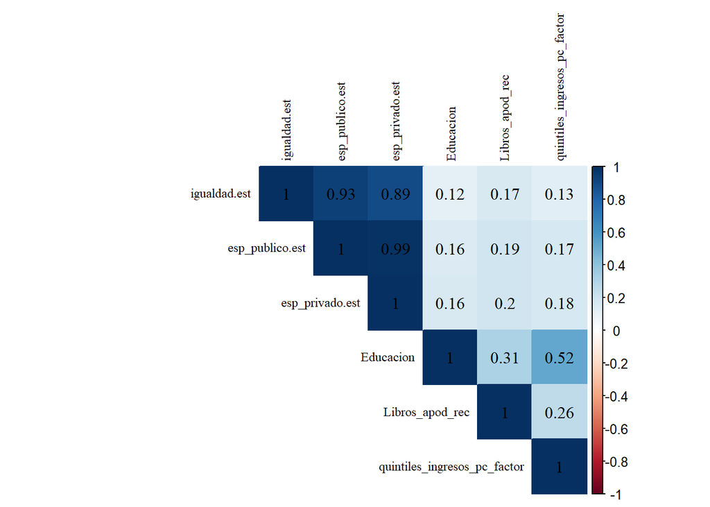

```r
windowsFonts(A = windowsFont("Times New Roman"))
cormat <- cor(dplyr::select(data_cor, igualdad.est, esp_publico.est, esp_privado.est, Educacion, Libros_apod_rec, quintiles_ingresos_pc_factor),
                   method="spearman",
                   use = "na.or.complete")
corrplot(
cormat,
  method = "color",
  type = "upper",
  tl.col = "black",
  addCoef.col = "black",
  diag = TRUE,
  family = "A",
  number.font = 6,
  tl.cex =0.75,
  number.cex = 1)
```

### Hipótesis 3.

*H3: Estudiantes con apoderados que poseen actitudes más positivas hacia la igualdad de género presentarán actitudes más positivas hacia la igualdad de género.*

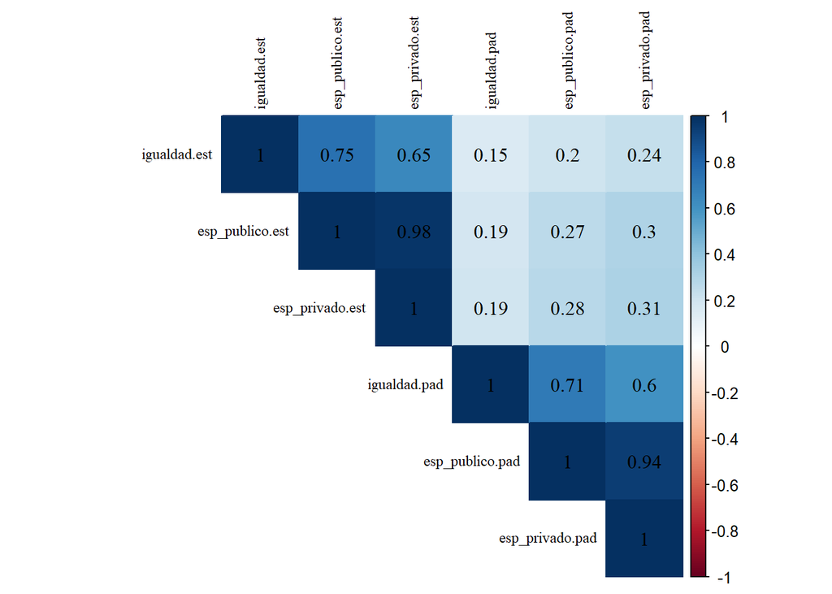

```r
windowsFonts(A = windowsFont("Times New Roman"))
cormat <- cor(dplyr::select(data_cor, igualdad.est, esp_publico.est, esp_privado.est, igualdad.pad, esp_publico.pad, esp_privado.pad),
                   use = "na.or.complete")

corrplot(
cormat,
  method = "color",
  type = "upper",
  tl.col = "black",
  addCoef.col = "black",
  diag = TRUE,
  family = "A",
  number.font = 6,
  tl.cex =0.75,
  number.cex = 1)
```

### Hipótesis 4.

*H4: Apoderados con mayores recursos socioeconómicos presentarán actitudes más positivas hacia la igualdad de género.*

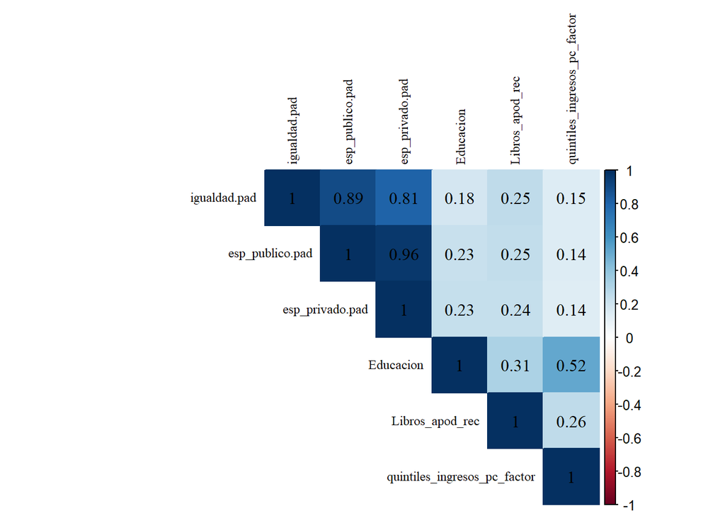

```r
windowsFonts(A = windowsFont("Times New Roman"))
cormat <- cor(dplyr::select(data_cor, igualdad.pad, esp_publico.pad, esp_privado.pad, Educacion, Libros_apod_rec, quintiles_ingresos_pc_factor),
                   method="spearman",
                   use = "na.or.complete")

corrplot(
cormat,
  method = "color",
  type = "upper",
  tl.col = "black",
  addCoef.col = "black",
  diag = TRUE,
  family = "A",
  number.font = 6,
  tl.cex =0.75,
  number.cex = 1)
```

### Hipótesis 4a.

*H4a: La relación entre los recursos de la familia y las actitudes de los estudiantes hacia la igualdad de género estará mediada por las actitudes de sus apoderados hacia la igualdad de género.*

```r
# derechos y oportunidades
## Educacion
data_cor %>% dplyr::select(igualdad.est, Educacion, igualdad.pad) %>%
  pcor(method="spearman")
```

```
## $estimate
##              igualdad.est Educacion igualdad.pad
## igualdad.est    1.0000000 0.1054223    0.2187885
## Educacion       0.1054223 1.0000000    0.1745815
## igualdad.pad    0.2187885 0.1745815    1.0000000
##
## $p.value
##              igualdad.est    Educacion igualdad.pad
## igualdad.est 0.000000e+00 8.193691e-03 3.039495e-08
## Educacion    8.193691e-03 0.000000e+00 1.081916e-05
## igualdad.pad 3.039495e-08 1.081916e-05 0.000000e+00
##
## $statistic
##              igualdad.est Educacion igualdad.pad
## igualdad.est     0.000000  2.652445     5.610003
## Educacion        2.652445  0.000000     4.436155
## igualdad.pad     5.610003  4.436155     0.000000
##
## $n
## [1] 629
##
## $gp
## [1] 1
##
## $method
## [1] "spearman"
```

```r
## Libros
data_cor %>% filter(!is.na(quintiles_ingresos_pc_factor)) %>%
  dplyr::select(igualdad.est, Libros_apod_rec, igualdad.pad) %>%
  pcor(method="spearman")
```

```
## $estimate
##                 igualdad.est Libros_apod_rec igualdad.pad
## igualdad.est       1.0000000       0.1207039    0.1826079
## Libros_apod_rec    0.1207039       1.0000000    0.2222344
## igualdad.pad       0.1826079       0.2222344    1.0000000
##
## $p.value
##                 igualdad.est Libros_apod_rec igualdad.pad
## igualdad.est    0.000000e+00    5.948603e-03 2.899083e-05
## Libros_apod_rec 5.948603e-03    0.000000e+00 3.225254e-07
## igualdad.pad    2.899083e-05    3.225254e-07 0.000000e+00
##
## $statistic
##                 igualdad.est Libros_apod_rec igualdad.pad
## igualdad.est        0.000000        2.762061     4.218993
## Libros_apod_rec     2.762061        0.000000     5.177672
## igualdad.pad        4.218993        5.177672     0.000000
##
## $n
## [1] 519
##
## $gp
## [1] 1
##
## $method
## [1] "spearman"
```

```r
## Ingresos
data_cor %>% filter(!is.na(quintiles_ingresos_pc_factor)) %>%
  dplyr::select(igualdad.est, quintiles_ingresos_pc_factor, igualdad.pad) %>%
  pcor(method="spearman")
```

```
## $estimate
##                              igualdad.est quintiles_ingresos_pc_factor
## igualdad.est                    1.0000000                    0.1001134
## quintiles_ingresos_pc_factor    0.1001134                    1.0000000
## igualdad.pad                    0.2010680                    0.1252213
##                              igualdad.pad
## igualdad.est                    0.2010680
## quintiles_ingresos_pc_factor    0.1252213
## igualdad.pad                    1.0000000
##
## $p.value
##                              igualdad.est quintiles_ingresos_pc_factor
## igualdad.est                 0.000000e+00                  0.022680977
## quintiles_ingresos_pc_factor 2.268098e-02                  0.000000000
## igualdad.pad                 3.981199e-06                  0.004312558
##                              igualdad.pad
## igualdad.est                 3.981199e-06
## quintiles_ingresos_pc_factor 4.312558e-03
## igualdad.pad                 0.000000e+00
##
## $statistic
##                              igualdad.est quintiles_ingresos_pc_factor
## igualdad.est                     0.000000                     2.285623
## quintiles_ingresos_pc_factor     2.285623                     0.000000
## igualdad.pad                     4.662610                     2.867048
##                              igualdad.pad
## igualdad.est                     4.662610
## quintiles_ingresos_pc_factor     2.867048
## igualdad.pad                     0.000000
##
## $n
## [1] 519
##
## $gp
## [1] 1
##
## $method
## [1] "spearman"
```

```r
# Espacio publico
## Educacion
data_cor %>% dplyr::select(esp_publico.est, Educacion,  esp_publico.pad) %>%
  pcor(method="spearman")
```

```
## $estimate
##                 esp_publico.est Educacion esp_publico.pad
## esp_publico.est       1.0000000 0.1335386       0.2536945
## Educacion             0.1335386 1.0000000       0.1957820
## esp_publico.pad       0.2536945 0.1957820       1.0000000
##
## $p.value
##                 esp_publico.est    Educacion esp_publico.pad
## esp_publico.est    0.000000e+00 7.941171e-04    1.113153e-10
## Educacion          7.941171e-04 0.000000e+00    7.636493e-07
## esp_publico.pad    1.113153e-10 7.636493e-07    0.000000e+00
##
## $statistic
##                 esp_publico.est Educacion esp_publico.pad
## esp_publico.est        0.000000  3.371329        6.562118
## Educacion              3.371329  0.000000        4.995132
## esp_publico.pad        6.562118  4.995132        0.000000
##
## $n
## [1] 629
##
## $gp
## [1] 1
##
## $method
## [1] "spearman"
```

```r
## Libros
data_cor %>% dplyr::select(esp_publico.est, Libros_apod_rec, esp_publico.pad) %>%
  pcor(method="spearman")
```

```
## $estimate
##                 esp_publico.est Libros_apod_rec esp_publico.pad
## esp_publico.est       1.0000000       0.1447717       0.2507049
## Libros_apod_rec       0.1447717       1.0000000       0.1974890
## esp_publico.pad       0.2507049       0.1974890       1.0000000
##
## $p.value
##                 esp_publico.est Libros_apod_rec esp_publico.pad
## esp_publico.est    0.000000e+00    2.727095e-04    1.863714e-10
## Libros_apod_rec    2.727095e-04    0.000000e+00    6.087798e-07
## esp_publico.pad    1.863714e-10    6.087798e-07    0.000000e+00
##
## $statistic
##                 esp_publico.est Libros_apod_rec esp_publico.pad
## esp_publico.est        0.000000        3.660752        6.479568
## Libros_apod_rec        3.660752        0.000000        5.040444
## esp_publico.pad        6.479568        5.040444        0.000000
##
## $n
## [1] 629
##
## $gp
## [1] 1
##
## $method
## [1] "spearman"
```

```r
## Ingresos
data_cor %>% filter(!is.na(quintiles_ingresos_pc_factor)) %>%
  dplyr::select(esp_publico.est, quintiles_ingresos_pc_factor, esp_publico.pad) %>%
  pcor(method="spearman")
```

```
## $estimate
##                              esp_publico.est quintiles_ingresos_pc_factor
## esp_publico.est                    1.0000000                    0.1388250
## quintiles_ingresos_pc_factor       0.1388250                    1.0000000
## esp_publico.pad                    0.2466721                    0.1022936
##                              esp_publico.pad
## esp_publico.est                    0.2466721
## quintiles_ingresos_pc_factor       0.1022936
## esp_publico.pad                    1.0000000
##
## $p.value
##                              esp_publico.est quintiles_ingresos_pc_factor
## esp_publico.est                 0.000000e+00                  0.001538511
## quintiles_ingresos_pc_factor    1.538511e-03                  0.000000000
## esp_publico.pad                 1.279817e-08                  0.019877678
##                              esp_publico.pad
## esp_publico.est                 1.279817e-08
## quintiles_ingresos_pc_factor    1.987768e-02
## esp_publico.pad                 0.000000e+00
##
## $statistic
##                              esp_publico.est quintiles_ingresos_pc_factor
## esp_publico.est                     0.000000                     3.184332
## quintiles_ingresos_pc_factor        3.184332                     0.000000
## esp_publico.pad                     5.781983                     2.335917
##                              esp_publico.pad
## esp_publico.est                     5.781983
## quintiles_ingresos_pc_factor        2.335917
## esp_publico.pad                     0.000000
##
## $n
## [1] 519
##
## $gp
## [1] 1
##
## $method
## [1] "spearman"
```

```r
# Espacio privado
##Educacion
data_cor %>% dplyr::select(esp_privado.est, Educacion, esp_privado.pad) %>%
  pcor(method="spearman")
```

```
## $estimate
##                 esp_privado.est Educacion esp_privado.pad
## esp_privado.est       1.0000000 0.1316331       0.2798573
## Educacion             0.1316331 1.0000000       0.1935195
## esp_privado.pad       0.2798573 0.1935195       1.0000000
##
## $p.value
##                 esp_privado.est    Educacion esp_privado.pad
## esp_privado.est    0.000000e+00 9.445514e-04    9.169185e-13
## Educacion          9.445514e-04 0.000000e+00    1.028081e-06
## esp_privado.pad    9.169185e-13 1.028081e-06    0.000000e+00
##
## $statistic
##                 esp_privado.est Educacion esp_privado.pad
## esp_privado.est        0.000000  3.322368        7.293462
## Educacion              3.322368  0.000000        4.935148
## esp_privado.pad        7.293462  4.935148        0.000000
##
## $n
## [1] 629
##
## $gp
## [1] 1
##
## $method
## [1] "spearman"
```

```r
## Libros
data_cor %>% dplyr::select(esp_privado.est, Libros_apod_rec, esp_privado.pad) %>%
  pcor(method="spearman")
```

```
## $estimate
##                 esp_privado.est Libros_apod_rec esp_privado.pad
## esp_privado.est       1.0000000       0.1461465       0.2773376
## Libros_apod_rec       0.1461465       1.0000000       0.1890880
## esp_privado.pad       0.2773376       0.1890880       1.0000000
##
## $p.value
##                 esp_privado.est Libros_apod_rec esp_privado.pad
## esp_privado.est    0.000000e+00    2.379663e-04    1.489425e-12
## Libros_apod_rec    2.379663e-04    0.000000e+00    1.822174e-06
## esp_privado.pad    1.489425e-12    1.822174e-06    0.000000e+00
##
## $statistic
##                 esp_privado.est Libros_apod_rec esp_privado.pad
## esp_privado.est        0.000000        3.696273        7.222296
## Libros_apod_rec        3.696273        0.000000        4.817895
## esp_privado.pad        7.222296        4.817895        0.000000
##
## $n
## [1] 629
##
## $gp
## [1] 1
##
## $method
## [1] "spearman"
```

```r
## Ingresos
data_cor %>% filter(!is.na(quintiles_ingresos_pc_factor)) %>%
  dplyr::select(esp_privado.est, quintiles_ingresos_pc_factor, esp_privado.pad) %>%
  pcor(method="spearman")
```

```
## $estimate
##                              esp_privado.est quintiles_ingresos_pc_factor
## esp_privado.est                    1.0000000                   0.14270293
## quintiles_ingresos_pc_factor       0.1427029                   1.00000000
## esp_privado.pad                    0.2813089                   0.08815381
##                              esp_privado.pad
## esp_privado.est                   0.28130886
## quintiles_ingresos_pc_factor      0.08815381
## esp_privado.pad                   1.00000000
##
## $p.value
##                              esp_privado.est quintiles_ingresos_pc_factor
## esp_privado.est                 0.000000e+00                  0.001127157
## quintiles_ingresos_pc_factor    1.127157e-03                  0.000000000
## esp_privado.pad                 7.072252e-11                  0.044919735
##                              esp_privado.pad
## esp_privado.est                 7.072252e-11
## quintiles_ingresos_pc_factor    4.491974e-02
## esp_privado.pad                 0.000000e+00
##
## $statistic
##                              esp_privado.est quintiles_ingresos_pc_factor
## esp_privado.est                     0.000000                     3.275106
## quintiles_ingresos_pc_factor        3.275106                     0.000000
## esp_privado.pad                     6.659018                     2.010296
##                              esp_privado.pad
## esp_privado.est                     6.659018
## quintiles_ingresos_pc_factor        2.010296
## esp_privado.pad                     0.000000
##
## $n
## [1] 519
##
## $gp
## [1] 1
##
## $method
## [1] "spearman"
```

### Hipótesis 5.

*H5: Las características de la escuela (proporción de niñas; apertura a la discusión en el aula) se asocian positivamente con las actitudes de los estudiantes hacia la igualdad de género.*

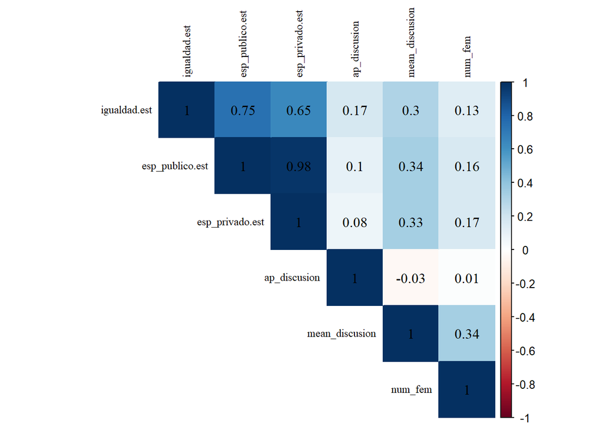

```r
windowsFonts(A = windowsFont("Times New Roman"))
cormat <- cor(dplyr::select(data_cor, igualdad.est, esp_publico.est, esp_privado.est, ap_discusion, mean_discusion, num_fem),
                   use = "na.or.complete")

corrplot(
cormat,
  method = "color",
  type = "upper",
  tl.col = "black",
  addCoef.col = "black",
  diag = TRUE,
  family = "A",
  number.font = 6,
  tl.cex =0.75,
  number.cex = 1)
```

## Gráficos

```r
# Calculo promedios por grupo
mean_ig <- mean(data_proc$igualdad.est)
mean_pub <- mean(data_proc$esp_publico.est)
mean_priv <- mean(data_proc$esp_privado.est)
```

### Hipótesis 1.

*H1: Las niñas presentarán actitudes más positivas hacia la igualdad de género que los niños.*

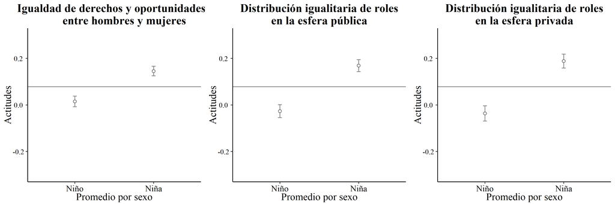

```r
general <- cowplot::plot_grid(plot_ig_sexo,plot_pub_sexo,plot_priv_sexo, ncol=3)
ggsave(general, file = "../output/general_h1.png",device = "png",width = 30,height = 10,dpi = "retina",units = "cm")
```

### Hipótesis 2.

*H2: Estudiantes que provienen de familias con mayores recursos socioeconómicos presentarán actitudes más positivas hacia la igualdad de género.*

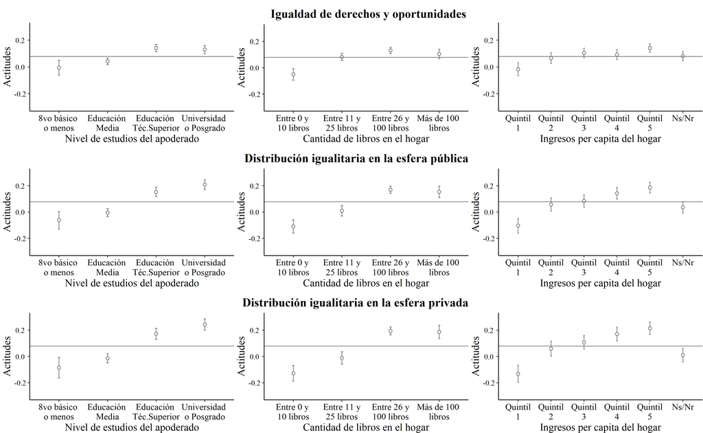

```r
ggsave(plot = plot_grid(list(plot_ig_educ,plot_ig_lib,plot_ig_ing,plot_pub_educ,plot_pub_lib,plot_pub_ing,plot_priv_educ,plot_priv_lib,plot_priv_ing),
                        margin = c(0.01,0.01,0.01,0.01,0.01,0.01,0.01,0.01,0.01),
                        tags = c(" ", " ", " "," ", " ", " ", " ", " ", " ")),
       filename = "../output/general_h2.png", width = 13, height = 8, dpi= "retina")
```

### Hipótesis 3.

*H3: Estudiantes con apoderados que poseen actitudes más positivas hacia la igualdad de género presentarán actitudes más positivas hacia la igualdad de género.*

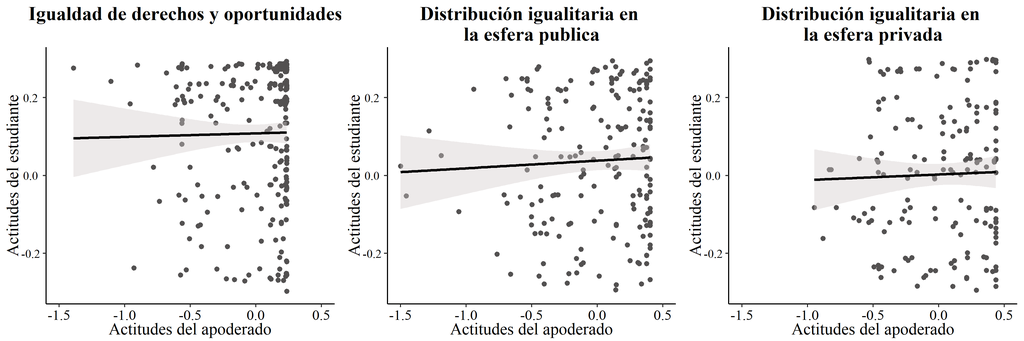

```r
general <- cowplot::plot_grid(plot_ig_act_apod,plot_pub_act_apod,plot_priv_act_apod, ncol=3)
ggsave(general, file = "../output/general_h3.png",device = "png",width = 30,height = 10,dpi = "retina",units = "cm")
```

### Hipótesis 5.

*H5: Las características de la escuela (proporción de niñas; apertura a la discusión en el aula) se asocian positivamente con las actitudes de los estudiantes hacia la igualdad de género*

[figure not shown]

```r
ggsave(plot = plot_grid(list(plot_ig_prop_ninas,plot_ig_ap_discusion,plot_ig_ap_discusion_prom,plot_pub_prop_ninas,plot_pub_ap_discusion,plot_pub_ap_discusion_prom,plot_priv_prop_ninas,plot_priv_ap_discusion,plot_priv_ap_discusion_prom),
                        margin = c(0.01,0.01,0.01,0.01,0.01,0.01,0.01,0.01,0.01),
                        tags = c(" ", " ", " "," ", " ", " ", " ", " ", " ")),
       filename = "../output/general_h5.png", width = 13, height = 8, dpi= "retina")
```

# Modelos de regresión: Base de datos reducida

## Modelo nulo

```r
data_proc$RBD <- as.factor(data_proc$RBD)

reg0_igualdad <- lme4::lmer(igualdad.est ~ 1 + (1 | RBD), data=data_proc)
reg0_pub <- lme4::lmer(esp_publico.est ~ 1 + (1 | RBD), data=data_proc)
reg0_priv <- lme4::lmer(esp_privado.est ~ 1 + (1 | RBD), data=data_proc)

#stargazer::stargazer(reg0_igualdad,reg0_pub, reg0_priv,
 # column.labels=c("Igualdad","Espacio público", "Espacio privado"),
  #type ='text')

##screenreg(list(reg0_igualdad,reg0_pub, reg0_priv))
```

```r
htmlreg(list(reg0_igualdad,reg0_pub, reg0_priv), custom.model.names = c("Actitudes del estudiante hacia la igualdad de derechos y oportunidades", "Actitudes del estudiante hacia la distribución igualitaria de roles en la esfera pública", "Actitudes del estudiante hacia la distribución igualitaria de roles en la esfera privada"), custom.note = "$***p <$ 0.001, $**p <$ 0.01, $*p <$ 0.05",  custom.coef.names = c("Intercepto"))
```

Statistical models

|  | Actitudes del estudiante hacia la igualdad de derechos y oportunidades | Actitudes del estudiante hacia la distribución igualitaria de roles en la esfera pública | Actitudes del estudiante hacia la distribución igualitaria de roles en la esfera privada |
| --- | --- | --- | --- |
| Intercepto | 0.03 | 0.01 | 0.01 |
|  | (0.03) | (0.04) | (0.04) |
| AIC | 559.62 | 817.12 | 1012.77 |
| BIC | 572.95 | 830.45 | 1026.11 |
| Log Likelihood | -276.81 | -405.56 | -503.39 |
| Num. obs. | 629 | 629 | 629 |
| Num. groups: RBD | 60 | 60 | 60 |
| Var: RBD (Intercept) | 0.04 | 0.06 | 0.08 |
| Var: Residual | 0.12 | 0.19 | 0.25 |

$***p <$ 0.001, $**p <$ 0.01, $*p <$ 0.05

### Correlación intra-clase

#### Igualdad de derechos y oportunidades

```r
reghelper::ICC(reg0_igualdad)
```

```
## [1] 0.2379867
```

#### Distribución igualitaria en el espacio público

```r
reghelper::ICC(reg0_pub)
```

```
## [1] 0.2577153
```

#### Distribución igualitaria en el espacio privada

```r
reghelper::ICC(reg0_priv)
```

```
## [1] 0.2471286
```

## Modelos de regresión

```r
reg_igualdad <- lmer(igualdad.est ~ 1 + Sexo + factor(Educacion) + factor(Libros_apod_rec) + factor(quintiles_ingresos_pc_factor) + igualdad.pad + ap_discusion + mean_discusion + num_fem + factor(dependencia) + factor(REGION) + c_civic + (1 | RBD), data=data_proc)
reg_esp.pub <- lmer(esp_publico.est ~ 1 + Sexo + factor(Educacion) + factor(Libros_apod_rec) + factor(quintiles_ingresos_pc_factor) + esp_publico.pad + ap_discusion + mean_discusion + num_fem + factor(dependencia) + factor(REGION) + c_civic + (1 | RBD), data=data_proc)
reg_esp.priv <- lmer(esp_privado.est ~ 1 + Sexo + factor(Educacion) + factor(Libros_apod_rec) + factor(quintiles_ingresos_pc_factor) + esp_privado.pad + ap_discusion + mean_discusion + num_fem + factor(dependencia) + factor(REGION) + c_civic + (1 | RBD), data=data_proc)
##screenreg(list(reg_igualdad,reg_esp.pub,reg_esp.priv))

#para evaluar la significación de la variable dependencia administrativa al no ser controlada por el resto de las variables del modelo
reg_igualdad54 <- lmer(igualdad.est ~ 1 + factor(dependencia) + (1 | RBD), data=data_proc)
reg_esp.pub54 <- lmer(esp_publico.est ~ 1 + factor(dependencia) + (1 | RBD), data=data_proc)
reg_esp.priv54 <- lmer(esp_privado.est ~ 1 + factor(dependencia) + (1 | RBD), data=data_proc)
##screenreg(list(reg_igualdad54,reg_esp.pub54,reg_esp.priv54))

#para evaluar la significación de la variable región al no ser controlada por el resto de las variables del modelo
reg_igualdad54 <- lmer(igualdad.est ~ 1 + factor(REGION) + (1 | RBD), data=data_proc)
reg_esp.pub54 <- lmer(esp_publico.est ~ 1 + factor(REGION) + (1 | RBD), data=data_proc)
reg_esp.priv54 <- lmer(esp_privado.est ~ 1 + factor(REGION) + (1 | RBD), data=data_proc)
##screenreg(list(reg_igualdad54,reg_esp.pub54,reg_esp.priv54))
```

### Hipótesis 1.

*H1: Las niñas presentarán actitudes más positivas hacia la igualdad de género que los niños.*

```r
htmlreg(list(reg_igualdad,reg_esp.pub,reg_esp.priv), custom.model.names = c("Actitudes del estudiante hacia la igualdad de derechos y oportunidades", "Actitudes del estudiante hacia la distribución igualitaria de roles en la esfera pública", "Actitudes del estudiante hacia la distribución igualitaria de roles en la esfera privada"), omit.coef = "(Educacion)|(Libros_apod_rec)|(quintiles_ingresos_pc_factor)|(igualdad.pad)|(esp_publico.pad)|(esp_privado.pad)|(ap_discusion)|(mean_discusion)|(num_fem)|(dependencia)|(REGION)|(c_civic)", custom.note = "$***p <$ 0.001, $**p <$ 0.01, $*p <$ 0.05 <br> Todos los modelos están controlados por el resto de las variables analizadas, la dependencia administrativa de la escuela, la región y el nivel de conocimiento cívico del estudiante.",  custom.coef.names = c("Intercepto", "Sexo <br> <i>(Ref. Niño)</i>"))
```

Statistical models

|  | Actitudes del estudiante hacia la igualdad de derechos y oportunidades | Actitudes del estudiante hacia la distribución igualitaria de roles en la esfera pública | Actitudes del estudiante hacia la distribución igualitaria de roles en la esfera privada |
| --- | --- | --- | --- |
| Intercepto | -0.33*** | -0.59*** | -0.65*** |
|  | (0.10) | (0.11) | (0.12) |
| Sexo *(Ref. Niño)* | 0.08* | 0.15*** | 0.17*** |
|  | (0.03) | (0.04) | (0.04) |
| AIC | 598.61 | 799.11 | 981.31 |
| BIC | 705.27 | 905.77 | 1087.97 |
| Log Likelihood | -275.31 | -375.56 | -466.65 |
| Num. obs. | 629 | 629 | 629 |
| Num. groups: RBD | 60 | 60 | 60 |
| Var: RBD (Intercept) | 0.01 | 0.01 | 0.01 |
| Var: Residual | 0.12 | 0.16 | 0.22 |

$***p <$ 0.001, $**p <$ 0.01, $*p <$ 0.05 Todos los modelos están controlados por el resto de las variables analizadas, la dependencia administrativa de la escuela, la región y el nivel de conocimiento cívico del estudiante.

### Hipótesis 2.

*H2: Estudiantes que provienen de familias con mayores recursos socioeconómicos presentarán actitudes más positivas hacia la igualdad de género.*

#### Educación

```r
htmlreg(list(reg_igualdad,reg_esp.pub,reg_esp.priv), custom.model.names = c("Actitudes del estudiante hacia la igualdad de derechos y oportunidades", "Actitudes del estudiante hacia la distribución igualitaria de roles en la esfera pública", "Actitudes del estudiante hacia la distribución igualitaria de roles en la esfera privada"), omit.coef = "(Sexo)|(Libros_apod_rec)|(quintiles_ingresos_pc_factor)|(igualdad.pad)|(esp_publico.pad)|(esp_privado.pad)|(ap_discusion)|(mean_discusion)|(num_fem)|(dependencia)|(REGION)|(c_civic)", custom.note = "$***p <$ 0.001, $**p <$ 0.01, $*p <$ 0.05 <br> Todos los modelos están controlados por el resto de las variables analizadas, la dependencia administrativa de la escuela, la región y el nivel de conocimiento cívico del estudiante.",  custom.coef.names = c("Intercepto", "Educación Media <br> <i>(Ref. 8vo básico o menos)</i>", "Educación Técnica Superior (IP o CFT)", "Una carrera en la Universidad o estudios de Posgrado"))
```

Statistical models

|  | Actitudes del estudiante hacia la igualdad de derechos y oportunidades | Actitudes del estudiante hacia la distribución igualitaria de roles en la esfera pública | Actitudes del estudiante hacia la distribución igualitaria de roles en la esfera privada |
| --- | --- | --- | --- |
| Intercepto | -0.33*** | -0.59*** | -0.65*** |
|  | (0.10) | (0.11) | (0.12) |
| Educación Media *(Ref. 8vo básico o menos)* | -0.01 | -0.02 | -0.03 |
|  | (0.05) | (0.06) | (0.07) |
| Educación Técnica Superior (IP o CFT) | -0.00 | -0.02 | -0.03 |
|  | (0.05) | (0.06) | (0.08) |
| Una carrera en la Universidad o estudios de Posgrado | -0.00 | 0.01 | 0.01 |
|  | (0.06) | (0.08) | (0.09) |
| AIC | 598.61 | 799.11 | 981.31 |
| BIC | 705.27 | 905.77 | 1087.97 |
| Log Likelihood | -275.31 | -375.56 | -466.65 |
| Num. obs. | 629 | 629 | 629 |
| Num. groups: RBD | 60 | 60 | 60 |
| Var: RBD (Intercept) | 0.01 | 0.01 | 0.01 |
| Var: Residual | 0.12 | 0.16 | 0.22 |

$***p <$ 0.001, $**p <$ 0.01, $*p <$ 0.05 Todos los modelos están controlados por el resto de las variables analizadas, la dependencia administrativa de la escuela, la región y el nivel de conocimiento cívico del estudiante.

#### Cantidad de libros en el hogar

```r
htmlreg(list(reg_igualdad,reg_esp.pub,reg_esp.priv), custom.model.names = c("Actitudes del estudiante hacia la igualdad de derechos y oportunidades", "Actitudes del estudiante hacia la distribución igualitaria de roles en la esfera pública", "Actitudes del estudiante hacia la distribución igualitaria de roles en la esfera privada"), omit.coef = "(Sexo)|(Educacion)|(quintiles_ingresos_pc_factor)|(igualdad.pad)|(esp_publico.pad)|(esp_privado.pad)|(ap_discusion)|(mean_discusion)|(num_fem)|(dependencia)|(REGION)|(c_civic)", custom.note = "$***p <$ 0.001, $**p <$ 0.01, $*p <$ 0.05 <br> Todos los modelos están controlados por el resto de las variables analizadas, la dependencia administrativa de la escuela, la región y el nivel de conocimiento cívico del estudiante.",  custom.coef.names = c("Intercepto", "Entre 11 y 25 libros <br> <i>(Ref. Entre 0 y 10 libros)</i>", "Entre 26 y 100 libros", "Más de 100 libros"))
```

Statistical models

|  | Actitudes del estudiante hacia la igualdad de derechos y oportunidades | Actitudes del estudiante hacia la distribución igualitaria de roles en la esfera pública | Actitudes del estudiante hacia la distribución igualitaria de roles en la esfera privada |
| --- | --- | --- | --- |
| Intercepto | -0.33*** | -0.59*** | -0.65*** |
|  | (0.10) | (0.11) | (0.12) |
| Entre 11 y 25 libros *(Ref. Entre 0 y 10 libros)* | 0.09* | 0.04 | 0.02 |
|  | (0.04) | (0.05) | (0.06) |
| Entre 26 y 100 libros | 0.04 | 0.05 | 0.05 |
|  | (0.04) | (0.05) | (0.06) |
| Más de 100 libros | 0.03 | 0.02 | 0.02 |
|  | (0.05) | (0.06) | (0.07) |
| AIC | 598.61 | 799.11 | 981.31 |
| BIC | 705.27 | 905.77 | 1087.97 |
| Log Likelihood | -275.31 | -375.56 | -466.65 |
| Num. obs. | 629 | 629 | 629 |
| Num. groups: RBD | 60 | 60 | 60 |
| Var: RBD (Intercept) | 0.01 | 0.01 | 0.01 |
| Var: Residual | 0.12 | 0.16 | 0.22 |

$***p <$ 0.001, $**p <$ 0.01, $*p <$ 0.05 Todos los modelos están controlados por el resto de las variables analizadas, la dependencia administrativa de la escuela, la región y el nivel de conocimiento cívico del estudiante.

#### Ingresos

```r
htmlreg(list(reg_igualdad,reg_esp.pub,reg_esp.priv), custom.model.names = c("Actitudes del estudiante hacia la igualdad de derechos y oportunidades", "Actitudes del estudiante hacia la distribución igualitaria de roles en la esfera pública", "Actitudes del estudiante hacia la distribución igualitaria de roles en la esfera privada"), omit.coef = "(Sexo)|(Educacion)|(Libros_apod_rec)|(igualdad.pad)|(esp_publico.pad)|(esp_privado.pad)|(ap_discusion)|(mean_discusion)|(num_fem)|(dependencia)|(REGION)|(c_civic)", custom.note = "$***p <$ 0.001, $**p <$ 0.01, $*p <$ 0.05 <br> Todos los modelos están controlados por el resto de las variables analizadas, la dependencia administrativa de la escuela, la región y el nivel de conocimiento cívico del estudiante.",  custom.coef.names = c("Intercepto", "Quintil 2 <br> <i>(Ref. Quintil 1)</i>", "Quintil 3", "Quintil 4", "Quintil 5", "No sabe / No responde"))
```

Statistical models

|  | Actitudes del estudiante hacia la igualdad de derechos y oportunidades | Actitudes del estudiante hacia la distribución igualitaria de roles en la esfera pública | Actitudes del estudiante hacia la distribución igualitaria de roles en la esfera privada |
| --- | --- | --- | --- |
| Intercepto | -0.33*** | -0.59*** | -0.65*** |
|  | (0.10) | (0.11) | (0.12) |
| Quintil 2 *(Ref. Quintil 1)* | 0.07 | 0.15** | 0.18** |
|  | (0.05) | (0.06) | (0.07) |
| Quintil 3 | 0.11* | 0.15* | 0.20** |
|  | (0.05) | (0.06) | (0.07) |
| Quintil 4 | 0.03 | 0.12* | 0.16* |
|  | (0.05) | (0.06) | (0.07) |
| Quintil 5 | 0.09 | 0.12 | 0.15 |
|  | (0.06) | (0.07) | (0.08) |
| No sabe / No responde | 0.09 | 0.13* | 0.13 |
|  | (0.05) | (0.06) | (0.07) |
| AIC | 598.61 | 799.11 | 981.31 |
| BIC | 705.27 | 905.77 | 1087.97 |
| Log Likelihood | -275.31 | -375.56 | -466.65 |
| Num. obs. | 629 | 629 | 629 |
| Num. groups: RBD | 60 | 60 | 60 |
| Var: RBD (Intercept) | 0.01 | 0.01 | 0.01 |
| Var: Residual | 0.12 | 0.16 | 0.22 |

$***p <$ 0.001, $**p <$ 0.01, $*p <$ 0.05 Todos los modelos están controlados por el resto de las variables analizadas, la dependencia administrativa de la escuela, la región y el nivel de conocimiento cívico del estudiante.

### Hipótesis 3.

*H3: Estudiantes con apoderados que poseen actitudes más positivas hacia la igualdad de género presentarán actitudes más positivas hacia la igualdad de género.*

```r
htmlreg(list(reg_igualdad,reg_esp.pub,reg_esp.priv), custom.model.names = c("Actitudes del estudiante hacia la igualdad de derechos y oportunidades", "Actitudes del estudiante hacia la distribución igualitaria de roles en la esfera pública", "Actitudes del estudiante hacia la distribución igualitaria de roles en la esfera privada"), omit.coef = "(Sexo)|(Educacion)|(Libros_apod_rec)|(quintiles_ingresos_pc_factor)|(ap_discusion)|(mean_discusion)|(num_fem)|(dependencia)|(REGION)|(c_civic)", custom.note = "$***p <$ 0.001, $**p <$ 0.01, $*p <$ 0.05 <br> Todos los modelos están controlados por el resto de las variables analizadas, la dependencia administrativa de la escuela, la región y el nivel de conocimiento cívico del estudiante.",  custom.coef.names = c("Intercepto", "Actitudes del apoderado hacia la igualdad de derechos y oportunidades", "Actitudes del apoderado hacia la distribución igualitaria de roles en la esfera pública", "Actitudes del apoderado hacia la distribución igualitaria de roles en la esfera privada"))
```

Statistical models

|  | Actitudes del estudiante hacia la igualdad de derechos y oportunidades | Actitudes del estudiante hacia la distribución igualitaria de roles en la esfera pública | Actitudes del estudiante hacia la distribución igualitaria de roles en la esfera privada |
| --- | --- | --- | --- |
| Intercepto | -0.33*** | -0.59*** | -0.65*** |
|  | (0.10) | (0.11) | (0.12) |
| Actitudes del apoderado hacia la igualdad de derechos y oportunidades | 0.09* |  |  |
|  | (0.04) |  |  |
| Actitudes del apoderado hacia la distribución igualitaria de roles en la esfera pública |  | 0.16*** |  |
|  |  | (0.04) |  |
| Actitudes del apoderado hacia la distribución igualitaria de roles en la esfera privada |  |  | 0.24*** |
|  |  |  | (0.05) |
| AIC | 598.61 | 799.11 | 981.31 |
| BIC | 705.27 | 905.77 | 1087.97 |
| Log Likelihood | -275.31 | -375.56 | -466.65 |
| Num. obs. | 629 | 629 | 629 |
| Num. groups: RBD | 60 | 60 | 60 |
| Var: RBD (Intercept) | 0.01 | 0.01 | 0.01 |
| Var: Residual | 0.12 | 0.16 | 0.22 |

$***p <$ 0.001, $**p <$ 0.01, $*p <$ 0.05 Todos los modelos están controlados por el resto de las variables analizadas, la dependencia administrativa de la escuela, la región y el nivel de conocimiento cívico del estudiante.

### Hipótesis 4.

*H4: Apoderados con mayores recursos socioeconómicos presentarán actitudes más positivas hacia la igualdad de género.*

```r
h4_igualdad.apod <- lmer(igualdad.pad ~ 1 + factor(Educacion) + factor(Libros_apod_rec) + factor(quintiles_ingresos_pc_factor) + factor(REGION) + (1 | RBD), data=data)
h4_esp_pub.apod <- lmer(esp_publico.pad ~ 1 + factor(Educacion) + factor(Libros_apod_rec) + factor(quintiles_ingresos_pc_factor) + factor(REGION) + (1 | RBD), data=data)
h4_esp_priv.apod <- lmer(esp_privado.pad ~ 1 + factor(Educacion) + factor(Libros_apod_rec) + factor(quintiles_ingresos_pc_factor) + factor(REGION) + (1 | RBD), data=data)
#screenreg(list(h4_igualdad.apod,h4_esp_pub.apod,h4_esp_priv.apod))
```

#### Educación

```r
htmlreg(list(h4_igualdad.apod,h4_esp_pub.apod,h4_esp_priv.apod), custom.model.names = c("Actitudes del apoderado hacia  la igualdad de derechos  y oportunidades", "Actitudes del apoderado hacia  la distribución igualitaria de roles en la esfera pública", "Actitudes del apoderado hacia  la distribución igualitaria de roles en la esfera privada"), omit.coef = "(Libros_apod_rec)|(quintiles_ingresos_pc_factor)|(REGION)", custom.note = "$***p <$ 0.001, $**p <$ 0.01, $*p <$ 0.05 <br> Los modelos están controlados por la cantidad de libros en el hogar, los ingresos mensuales de los miembros del hogar y la región en que residen.",  custom.coef.names = c("Intercepto", "Educación Media <br> <i>(Ref. 8vo básico o menos)</i>", "Educación Técnica Superior (IP o CFT)", "Una carrera en la Universidad o  estudios de Posgrado"))
```

Statistical models

|  | Actitudes del apoderado hacia la igualdad de derechos y oportunidades | Actitudes del apoderado hacia la distribución igualitaria de roles en la esfera pública | Actitudes del apoderado hacia la distribución igualitaria de roles en la esfera privada |
| --- | --- | --- | --- |
| Intercepto | -0.25*** | -0.30*** | -0.36*** |
|  | (0.06) | (0.07) | (0.08) |
| Educación Media *(Ref. 8vo básico o menos)* | 0.13** | 0.13* | 0.13* |
|  | (0.04) | (0.05) | (0.06) |
| Educación Técnica Superior (IP o CFT) | 0.15** | 0.20*** | 0.21*** |
|  | (0.05) | (0.06) | (0.06) |
| Una carrera en la Universidad o estudios de Posgrado | 0.16** | 0.24*** | 0.24*** |
|  | (0.06) | (0.07) | (0.07) |
| AIC | 518.46 | 779.40 | 823.02 |
| BIC | 590.72 | 851.66 | 895.28 |
| Log Likelihood | -243.23 | -373.70 | -395.51 |
| Num. obs. | 676 | 676 | 676 |
| Num. groups: RBD | 60 | 60 | 60 |
| Var: RBD (Intercept) | 0.00 | 0.01 | 0.01 |
| Var: Residual | 0.11 | 0.16 | 0.17 |

$***p <$ 0.001, $**p <$ 0.01, $*p <$ 0.05 Los modelos están controlados por la cantidad de libros en el hogar, los ingresos mensuales de los miembros del hogar y la región en que residen.

#### Cantidad de libros en el hogar

```r
htmlreg(list(h4_igualdad.apod,h4_esp_pub.apod,h4_esp_priv.apod), custom.model.names = c("Actitudes del apoderado hacia  la igualdad de derechos  y oportunidades", "Actitudes del apoderado hacia  la distribución igualitaria de roles en la esfera pública", "Actitudes del apoderado hacia  la distribución igualitaria de roles en la esfera privada"), omit.coef = "(Educacion)|(quintiles_ingresos_pc_factor)|(REGION)", custom.note = "$***p <$ 0.001, $**p <$ 0.01, $*p <$ 0.05 <br> Los modelos están controlados por el nivel educativo del apoderado, los ingresos mensuales de los miembros del hogar y la región en que residen.",  custom.coef.names = c("Intercepto", "Entre 11 y 25 libros <br> <i>(Ref. Entre 0 y 10 libros)</i>", "Entre 26 y 100 libros", "Más de 100 libros"))
```

Statistical models

|  | Actitudes del apoderado hacia la igualdad de derechos y oportunidades | Actitudes del apoderado hacia la distribución igualitaria de roles en la esfera pública | Actitudes del apoderado hacia la distribución igualitaria de roles en la esfera privada |
| --- | --- | --- | --- |
| Intercepto | -0.25*** | -0.30*** | -0.36*** |
|  | (0.06) | (0.07) | (0.08) |
| Entre 11 y 25 libros *(Ref. Entre 0 y 10 libros)* | 0.08* | 0.10* | 0.10* |
|  | (0.04) | (0.05) | (0.05) |
| Entre 26 y 100 libros | 0.13*** | 0.19*** | 0.21*** |
|  | (0.04) | (0.05) | (0.05) |
| Más de 100 libros | 0.19*** | 0.23*** | 0.22*** |
|  | (0.05) | (0.06) | (0.06) |
| AIC | 518.46 | 779.40 | 823.02 |
| BIC | 590.72 | 851.66 | 895.28 |
| Log Likelihood | -243.23 | -373.70 | -395.51 |
| Num. obs. | 676 | 676 | 676 |
| Num. groups: RBD | 60 | 60 | 60 |
| Var: RBD (Intercept) | 0.00 | 0.01 | 0.01 |
| Var: Residual | 0.11 | 0.16 | 0.17 |

$***p <$ 0.001, $**p <$ 0.01, $*p <$ 0.05 Los modelos están controlados por el nivel educativo del apoderado, los ingresos mensuales de los miembros del hogar y la región en que residen.

#### Ingresos

```r
htmlreg(list(h4_igualdad.apod,h4_esp_pub.apod,h4_esp_priv.apod), custom.model.names = c("Actitudes del apoderado hacia  la igualdad de derechos  y oportunidades", "Actitudes del apoderado hacia  la distribución igualitaria de roles en la esfera pública", "Actitudes del apoderado hacia  la distribución igualitaria de roles en la esfera privada"), omit.coef = "(Libros_apod_rec)|(Educacion)|(REGION)", custom.note = "$***p <$ 0.001, $**p <$ 0.01, $*p <$ 0.05 <br> Los modelos están controlados por el nivel educativo del apoderado, la cantidad de libros en el hogar y la región en que residen.",  custom.coef.names = c("Intercepto", "Quintil 2 <br> <i>(Ref. Quintil 1)</i>", "Quintil 3", "Quintil 4", "Quintil 5", "No sabe / No responde"))
```

Statistical models

|  | Actitudes del apoderado hacia la igualdad de derechos y oportunidades | Actitudes del apoderado hacia la distribución igualitaria de roles en la esfera pública | Actitudes del apoderado hacia la distribución igualitaria de roles en la esfera privada |
| --- | --- | --- | --- |
| Intercepto | -0.25*** | -0.30*** | -0.36*** |
|  | (0.06) | (0.07) | (0.08) |
| Quintil 2 *(Ref. Quintil 1)* | -0.06 | -0.07 | -0.06 |
|  | (0.05) | (0.06) | (0.06) |
| Quintil 3 | -0.05 | -0.04 | -0.03 |
|  | (0.05) | (0.06) | (0.06) |
| Quintil 4 | 0.04 | 0.01 | 0.00 |
|  | (0.05) | (0.06) | (0.06) |
| Quintil 5 | 0.00 | -0.03 | -0.01 |
|  | (0.05) | (0.06) | (0.07) |
| No sabe / No responde | 0.04 | -0.03 | -0.02 |
|  | (0.05) | (0.06) | (0.06) |
| AIC | 518.46 | 779.40 | 823.02 |
| BIC | 590.72 | 851.66 | 895.28 |
| Log Likelihood | -243.23 | -373.70 | -395.51 |
| Num. obs. | 676 | 676 | 676 |
| Num. groups: RBD | 60 | 60 | 60 |
| Var: RBD (Intercept) | 0.00 | 0.01 | 0.01 |
| Var: Residual | 0.11 | 0.16 | 0.17 |

$***p <$ 0.001, $**p <$ 0.01, $*p <$ 0.05 Los modelos están controlados por el nivel educativo del apoderado, la cantidad de libros en el hogar y la región en que residen.

#### Modelo H4 completo

```r
htmlreg(list(h4_igualdad.apod,h4_esp_pub.apod,h4_esp_priv.apod), custom.model.names = c("Actitudes del apoderado hacia  la igualdad de derechos  y oportunidades", "Actitudes del apoderado hacia  la distribución igualitaria de roles en la esfera pública", "Actitudes del apoderado hacia  la distribución igualitaria de roles en la esfera privada"), custom.note = "$***p <$ 0.001, $**p <$ 0.01, $*p <$ 0.05",  custom.coef.names = c("Intercepto", "Educación Media <br> <i>(Ref. 8vo básico o menos)</i>", "Educación Técnica Superior (IP o CFT)", "Una carrera en la Universidad o  estudios de Posgrado", "Entre 11 y 25 libros <br> <i>(Ref. Entre 0 y 10 libros)</i>", "Entre 26 y 100 libros", "Más de 100 libros", "Quintil 2 <br> <i>(Ref. Quintil 1)</i>", "Quintil 3", "Quintil 4", "Quintil 5", "No sabe / No responde", "Reg. del Maule <br> <i>(Ref. Reg. de Antofagasta)</i>", "Reg. Metropolitana"))
```

Statistical models

|  | Actitudes del apoderado hacia la igualdad de derechos y oportunidades | Actitudes del apoderado hacia la distribución igualitaria de roles en la esfera pública | Actitudes del apoderado hacia la distribución igualitaria de roles en la esfera privada |
| --- | --- | --- | --- |
| Intercepto | -0.25*** | -0.30*** | -0.36*** |
|  | (0.06) | (0.07) | (0.08) |
| Educación Media *(Ref. 8vo básico o menos)* | 0.13** | 0.13* | 0.13* |
|  | (0.04) | (0.05) | (0.06) |
| Educación Técnica Superior (IP o CFT) | 0.15** | 0.20*** | 0.21*** |
|  | (0.05) | (0.06) | (0.06) |
| Una carrera en la Universidad o estudios de Posgrado | 0.16** | 0.24*** | 0.24*** |
|  | (0.06) | (0.07) | (0.07) |
| Entre 11 y 25 libros *(Ref. Entre 0 y 10 libros)* | 0.08* | 0.10* | 0.10* |
|  | (0.04) | (0.05) | (0.05) |
| Entre 26 y 100 libros | 0.13*** | 0.19*** | 0.21*** |
|  | (0.04) | (0.05) | (0.05) |
| Más de 100 libros | 0.19*** | 0.23*** | 0.22*** |
|  | (0.05) | (0.06) | (0.06) |
| Quintil 2 *(Ref. Quintil 1)* | -0.06 | -0.07 | -0.06 |
|  | (0.05) | (0.06) | (0.06) |
| Quintil 3 | -0.05 | -0.04 | -0.03 |
|  | (0.05) | (0.06) | (0.06) |
| Quintil 4 | 0.04 | 0.01 | 0.00 |
|  | (0.05) | (0.06) | (0.06) |
| Quintil 5 | 0.00 | -0.03 | -0.01 |
|  | (0.05) | (0.06) | (0.07) |
| No sabe / No responde | 0.04 | -0.03 | -0.02 |
|  | (0.05) | (0.06) | (0.06) |
| Reg. del Maule *(Ref. Reg. de Antofagasta)* | -0.01 | -0.03 | 0.03 |
|  | (0.05) | (0.06) | (0.06) |
| Reg. Metropolitana | 0.06 | 0.11* | 0.16** |
|  | (0.04) | (0.05) | (0.06) |
| AIC | 518.46 | 779.40 | 823.02 |
| BIC | 590.72 | 851.66 | 895.28 |
| Log Likelihood | -243.23 | -373.70 | -395.51 |
| Num. obs. | 676 | 676 | 676 |
| Num. groups: RBD | 60 | 60 | 60 |
| Var: RBD (Intercept) | 0.00 | 0.01 | 0.01 |
| Var: Residual | 0.11 | 0.16 | 0.17 |

$***p <$ 0.001, $**p <$ 0.01, $*p <$ 0.05

### Hipótesis 5.

*H5: Las características de la escuela (proporción de niñas; apertura a la discusión en el aula) se asocian positivamente con las actitudes de los estudiantes hacia la igualdad de género.*

#### Apertura a la discusión en el aula

```r
htmlreg(list(reg_igualdad,reg_esp.pub,reg_esp.priv), custom.model.names = c("Actitudes del estudiante hacia  la igualdad de derechos  y oportunidades", "Actitudes del estudiante hacia  la distribución igualitaria de roles en la esfera pública", "Actitudes del estudiante hacia  la distribución igualitaria de roles en la esfera privada"), omit.coef = "(Sexo)|(Educacion)|(Libros_apod_rec)|(quintiles_ingresos_pc_factor)|(igualdad.pad)|(esp_publico.pad)|(esp_privado.pad)|(num_fem)|(dependencia)|(REGION)|(c_civic)", custom.note = "$***p <$ 0.001, $**p <$ 0.01, $*p <$ 0.05 <br> Todos los modelos están controlados por el resto de las variables analizadas, la dependencia administrativa de la escuela, la región y el nivel de conocimiento cívico del estudiante.",  custom.coef.names = c("Intercepto", "Percepción individual sobre la apertura  a la discusión en el aula", "Percepción general sobre la apertura  a la discusión en el aula"))
```

Statistical models

|  | Actitudes del estudiante hacia la igualdad de derechos y oportunidades | Actitudes del estudiante hacia la distribución igualitaria de roles en la esfera pública | Actitudes del estudiante hacia la distribución igualitaria de roles en la esfera privada |
| --- | --- | --- | --- |
| Intercepto | -0.33*** | -0.59*** | -0.65*** |
|  | (0.10) | (0.11) | (0.12) |
| Percepción individual sobre la apertura a la discusión en el aula | 0.12*** | 0.07* | 0.05 |
|  | (0.03) | (0.03) | (0.03) |
| Percepción general sobre la apertura a la discusión en el aula | 0.36*** | 0.34*** | 0.37*** |
|  | (0.09) | (0.09) | (0.10) |
| AIC | 598.61 | 799.11 | 981.31 |
| BIC | 705.27 | 905.77 | 1087.97 |
| Log Likelihood | -275.31 | -375.56 | -466.65 |
| Num. obs. | 629 | 629 | 629 |
| Num. groups: RBD | 60 | 60 | 60 |
| Var: RBD (Intercept) | 0.01 | 0.01 | 0.01 |
| Var: Residual | 0.12 | 0.16 | 0.22 |

$***p <$ 0.001, $**p <$ 0.01, $*p <$ 0.05 Todos los modelos están controlados por el resto de las variables analizadas, la dependencia administrativa de la escuela, la región y el nivel de conocimiento cívico del estudiante.

#### Proporción de niñas

```r
htmlreg(list(reg_igualdad,reg_esp.pub,reg_esp.priv), custom.model.names = c("Actitudes del estudiante hacia  la igualdad de derechos  y oportunidades", "Actitudes del estudiante hacia  la distribución igualitaria de roles en la esfera pública", "Actitudes del estudiante hacia  la distribución igualitaria de roles en la esfera privada"), omit.coef = "(Sexo)|(Educacion)|(Libros_apod_rec)|(quintiles_ingresos_pc_factor)|(igualdad.pad)|(esp_publico.pad)|(esp_privado.pad)|(ap_discusion)|(mean_discusion)|(dependencia)|(REGION)|(c_civic)", custom.note = "$***p <$ 0.001, $**p <$ 0.01, $*p <$ 0.05 <br> Todos los modelos están controlados por el resto de las variables analizadas, la dependencia administrativa de la escuela, la región y el nivel de conocimiento cívico del estudiante.",  custom.coef.names = c("Intercepto", "Proporción de niñas en el aula"))
```

Statistical models

|  | Actitudes del estudiante hacia la igualdad de derechos y oportunidades | Actitudes del estudiante hacia la distribución igualitaria de roles en la esfera pública | Actitudes del estudiante hacia la distribución igualitaria de roles en la esfera privada |
| --- | --- | --- | --- |
| Intercepto | -0.33*** | -0.59*** | -0.65*** |
|  | (0.10) | (0.11) | (0.12) |
| Proporción de niñas en el aula | 0.05 | -0.03 | -0.02 |
|  | (0.12) | (0.12) | (0.14) |
| AIC | 598.61 | 799.11 | 981.31 |
| BIC | 705.27 | 905.77 | 1087.97 |
| Log Likelihood | -275.31 | -375.56 | -466.65 |
| Num. obs. | 629 | 629 | 629 |
| Num. groups: RBD | 60 | 60 | 60 |
| Var: RBD (Intercept) | 0.01 | 0.01 | 0.01 |
| Var: Residual | 0.12 | 0.16 | 0.22 |

$***p <$ 0.001, $**p <$ 0.01, $*p <$ 0.05 Todos los modelos están controlados por el resto de las variables analizadas, la dependencia administrativa de la escuela, la región y el nivel de conocimiento cívico del estudiante.

### Pendientes fijas y aleatorias

#### Igualdad de género

```r
reg_igualdad_pf <- lmer(igualdad.est ~ 1 + Sexo + factor(Educacion) + factor(Libros_apod_rec) + factor(quintiles_ingresos_pc_factor) + igualdad.pad + ap_discusion + mean_discusion + num_fem + factor(dependencia) + factor(REGION) + c_civic + (1 | RBD), data=data_proc)
# Educación
reg_igualdad_pa1 <- lmer(igualdad.est ~ 1 + Sexo + factor(Educacion) + factor(Libros_apod_rec) + factor(quintiles_ingresos_pc_factor) + igualdad.pad + ap_discusion + mean_discusion + num_fem + factor(dependencia) + factor(REGION) + c_civic + (1 + factor(Educacion) | RBD), data=data_proc)
anova(reg_igualdad_pf,reg_igualdad_pa1) #no
```

```
## Data: data_proc
## Models:
## reg_igualdad_pf: igualdad.est ~ 1 + Sexo + factor(Educacion) + factor(Libros_apod_rec) +
## reg_igualdad_pf:     factor(quintiles_ingresos_pc_factor) + igualdad.pad + ap_discusion +
## reg_igualdad_pf:     mean_discusion + num_fem + factor(dependencia) + factor(REGION) +
## reg_igualdad_pf:     c_civic + (1 | RBD)
## reg_igualdad_pa1: igualdad.est ~ 1 + Sexo + factor(Educacion) + factor(Libros_apod_rec) +
## reg_igualdad_pa1:     factor(quintiles_ingresos_pc_factor) + igualdad.pad + ap_discusion +
## reg_igualdad_pa1:     mean_discusion + num_fem + factor(dependencia) + factor(REGION) +
## reg_igualdad_pa1:     c_civic + (1 + factor(Educacion) | RBD)
##                  npar    AIC    BIC  logLik deviance  Chisq Df Pr(>Chisq)
## reg_igualdad_pf    24 496.77 603.43 -224.39   448.77
## reg_igualdad_pa1   33 508.01 654.67 -221.01   442.01 6.7615  9     0.6619
```

```r
# Libros
reg_igualdad_pa2 <- lmer(igualdad.est ~ 1 + Sexo + factor(Educacion) + factor(Libros_apod_rec) + factor(quintiles_ingresos_pc_factor) + igualdad.pad + ap_discusion + mean_discusion + num_fem + factor(dependencia) + factor(REGION) + c_civic + (1 + factor(Libros_apod_rec) | RBD), data=data_proc)
anova(reg_igualdad_pf,reg_igualdad_pa2) #no
```

```
## Data: data_proc
## Models:
## reg_igualdad_pf: igualdad.est ~ 1 + Sexo + factor(Educacion) + factor(Libros_apod_rec) +
## reg_igualdad_pf:     factor(quintiles_ingresos_pc_factor) + igualdad.pad + ap_discusion +
## reg_igualdad_pf:     mean_discusion + num_fem + factor(dependencia) + factor(REGION) +
## reg_igualdad_pf:     c_civic + (1 | RBD)
## reg_igualdad_pa2: igualdad.est ~ 1 + Sexo + factor(Educacion) + factor(Libros_apod_rec) +
## reg_igualdad_pa2:     factor(quintiles_ingresos_pc_factor) + igualdad.pad + ap_discusion +
## reg_igualdad_pa2:     mean_discusion + num_fem + factor(dependencia) + factor(REGION) +
## reg_igualdad_pa2:     c_civic + (1 + factor(Libros_apod_rec) | RBD)
##                  npar    AIC    BIC  logLik deviance Chisq Df Pr(>Chisq)
## reg_igualdad_pf    24 496.77 603.43 -224.39   448.77
## reg_igualdad_pa2   33 507.43 654.09 -220.72   441.43 7.344  9     0.6014
```

```r
# Ingresos
#reg_igualdad_pa3 <- lmer(igualdad.est ~ 1 + Sexo + factor(Educacion) + factor(Libros_apod_rec) + factor(quintiles_ingresos_pc_factor) + igualdad.pad + ap_discusion + mean_discusion + num_fem + factor(dependencia) + factor(REGION) + c_civic + (1 + factor(quintiles_ingresos_pc_factor) | RBD), data=data_proc) ###no es posible estimar el modelo: "Error: number of observations (=627) <= number of random effects (=720) for term (1 + factor(ingresos_tramos) | RBD); the random-effects parameters and the residual variance (or scale parameter) are probably unidentifiable"
# Actitudes del apoderado
reg_igualdad_pa4 <- lmer(igualdad.est ~ 1 + Sexo + factor(Educacion) + factor(Libros_apod_rec) + factor(quintiles_ingresos_pc_factor) + igualdad.pad + ap_discusion + mean_discusion + num_fem + factor(dependencia) + factor(REGION) + c_civic + (1 + igualdad.pad | RBD), data=data_proc)
anova(reg_igualdad_pf,reg_igualdad_pa4) #sí
```

```
## Data: data_proc
## Models:
## reg_igualdad_pf: igualdad.est ~ 1 + Sexo + factor(Educacion) + factor(Libros_apod_rec) +
## reg_igualdad_pf:     factor(quintiles_ingresos_pc_factor) + igualdad.pad + ap_discusion +
## reg_igualdad_pf:     mean_discusion + num_fem + factor(dependencia) + factor(REGION) +
## reg_igualdad_pf:     c_civic + (1 | RBD)
## reg_igualdad_pa4: igualdad.est ~ 1 + Sexo + factor(Educacion) + factor(Libros_apod_rec) +
## reg_igualdad_pa4:     factor(quintiles_ingresos_pc_factor) + igualdad.pad + ap_discusion +
## reg_igualdad_pa4:     mean_discusion + num_fem + factor(dependencia) + factor(REGION) +
## reg_igualdad_pa4:     c_civic + (1 + igualdad.pad | RBD)
##                  npar    AIC    BIC  logLik deviance  Chisq Df Pr(>Chisq)
## reg_igualdad_pf    24 496.77 603.43 -224.39   448.77
## reg_igualdad_pa4   26 491.48 607.02 -219.74   439.48 9.2982  2    0.00957 **
## ---
## Signif. codes:  0 '***' 0.001 '**' 0.01 '*' 0.05 '.' 0.1 ' ' 1
```

```r
# Sexo
reg_igualdad_pa5 <- lmer(igualdad.est ~ 1 + Sexo + factor(Educacion) + factor(Libros_apod_rec) + factor(quintiles_ingresos_pc_factor) + igualdad.pad + ap_discusion + mean_discusion + num_fem + factor(dependencia) + factor(REGION) + c_civic + (1 + Sexo | RBD), data=data_proc)
anova(reg_igualdad_pf,reg_igualdad_pa5) #sí
```

```
## Data: data_proc
## Models:
## reg_igualdad_pf: igualdad.est ~ 1 + Sexo + factor(Educacion) + factor(Libros_apod_rec) +
## reg_igualdad_pf:     factor(quintiles_ingresos_pc_factor) + igualdad.pad + ap_discusion +
## reg_igualdad_pf:     mean_discusion + num_fem + factor(dependencia) + factor(REGION) +
## reg_igualdad_pf:     c_civic + (1 | RBD)
## reg_igualdad_pa5: igualdad.est ~ 1 + Sexo + factor(Educacion) + factor(Libros_apod_rec) +
## reg_igualdad_pa5:     factor(quintiles_ingresos_pc_factor) + igualdad.pad + ap_discusion +
## reg_igualdad_pa5:     mean_discusion + num_fem + factor(dependencia) + factor(REGION) +
## reg_igualdad_pa5:     c_civic + (1 + Sexo | RBD)
##                  npar    AIC    BIC  logLik deviance  Chisq Df Pr(>Chisq)
## reg_igualdad_pf    24 496.77 603.43 -224.39   448.77
## reg_igualdad_pa5   26 489.35 604.90 -218.68   437.35 11.421  2   0.003312 **
## ---
## Signif. codes:  0 '***' 0.001 '**' 0.01 '*' 0.05 '.' 0.1 ' ' 1
```

#### Espacio público

```r
reg_esp.pub_pf <- lmer(esp_publico.est ~ 1 + Sexo + factor(Educacion) + factor(Libros_apod_rec) + factor(quintiles_ingresos_pc_factor) + esp_publico.pad + ap_discusion + mean_discusion + num_fem + factor(dependencia) + factor(REGION) + c_civic + (1 | RBD), data=data_proc)
# Educación
reg_esp.pub_pa1 <- lmer(esp_publico.est ~ 1 + Sexo + factor(Educacion) + factor(Libros_apod_rec) + factor(quintiles_ingresos_pc_factor) + esp_publico.pad + ap_discusion + mean_discusion + num_fem + factor(dependencia) + factor(REGION) + c_civic + (1 + factor(Educacion) | RBD), data=data_proc)
anova(reg_esp.pub_pf,reg_esp.pub_pa1) #no
```

```
## Data: data_proc
## Models:
## reg_esp.pub_pf: esp_publico.est ~ 1 + Sexo + factor(Educacion) + factor(Libros_apod_rec) +
## reg_esp.pub_pf:     factor(quintiles_ingresos_pc_factor) + esp_publico.pad +
## reg_esp.pub_pf:     ap_discusion + mean_discusion + num_fem + factor(dependencia) +
## reg_esp.pub_pf:     factor(REGION) + c_civic + (1 | RBD)
## reg_esp.pub_pa1: esp_publico.est ~ 1 + Sexo + factor(Educacion) + factor(Libros_apod_rec) +
## reg_esp.pub_pa1:     factor(quintiles_ingresos_pc_factor) + esp_publico.pad +
## reg_esp.pub_pa1:     ap_discusion + mean_discusion + num_fem + factor(dependencia) +
## reg_esp.pub_pa1:     factor(REGION) + c_civic + (1 + factor(Educacion) | RBD)
##                 npar    AIC    BIC  logLik deviance  Chisq Df Pr(>Chisq)
## reg_esp.pub_pf    24 702.59 809.25 -327.29   654.59
## reg_esp.pub_pa1   33 712.84 859.50 -323.42   646.84 7.7462  9     0.5599
```

```r
# Libros
reg_esp.pub_pa2 <- lmer(esp_publico.est ~ 1 + Sexo + factor(Educacion) + factor(Libros_apod_rec) + factor(quintiles_ingresos_pc_factor) + esp_publico.pad + ap_discusion + mean_discusion + num_fem + factor(dependencia) + factor(REGION) + c_civic + (1 + factor(Libros_apod_rec) | RBD), data=data_proc)
anova(reg_esp.pub_pf,reg_esp.pub_pa2) #no
```

```
## Data: data_proc
## Models:
## reg_esp.pub_pf: esp_publico.est ~ 1 + Sexo + factor(Educacion) + factor(Libros_apod_rec) +
## reg_esp.pub_pf:     factor(quintiles_ingresos_pc_factor) + esp_publico.pad +
## reg_esp.pub_pf:     ap_discusion + mean_discusion + num_fem + factor(dependencia) +
## reg_esp.pub_pf:     factor(REGION) + c_civic + (1 | RBD)
## reg_esp.pub_pa2: esp_publico.est ~ 1 + Sexo + factor(Educacion) + factor(Libros_apod_rec) +
## reg_esp.pub_pa2:     factor(quintiles_ingresos_pc_factor) + esp_publico.pad +
## reg_esp.pub_pa2:     ap_discusion + mean_discusion + num_fem + factor(dependencia) +
## reg_esp.pub_pa2:     factor(REGION) + c_civic + (1 + factor(Libros_apod_rec) |
## reg_esp.pub_pa2:     RBD)
##                 npar    AIC    BIC  logLik deviance  Chisq Df Pr(>Chisq)
## reg_esp.pub_pf    24 702.59 809.25 -327.29   654.59
## reg_esp.pub_pa2   33 713.45 860.11 -323.73   647.45 7.1324  9     0.6233
```

```r
# Ingresos
#reg_esp.pub_pa3 <- lmer(esp_publico.est ~ 1 + Sexo + factor(Educacion) + factor(Libros_apod_rec) + factor(quintiles_ingresos_pc_factor) + esp_publico.pad + ap_discusion + mean_discusion + num_fem + factor(dependencia) + factor(REGION) + c_civic + (1 + factor(quintiles_ingresos_pc_factor) | RBD), data=data_proc) ###no es posible estimar el modelo: "Error: number of observations (=627) <= number of random effects (=720) for term (1 + factor(ingresos_tramos) | RBD); the random-effects parameters and the residual variance (or scale parameter) are probably unidentifiable"
# Actitudes del apoderado
reg_esp.pub_pa4 <- lmer(esp_publico.est ~ 1 + Sexo + factor(Educacion) + factor(Libros_apod_rec) + factor(quintiles_ingresos_pc_factor) + esp_publico.pad + ap_discusion + mean_discusion + num_fem + factor(dependencia) + factor(REGION) + c_civic + (1 + esp_publico.pad | RBD), data=data_proc)
anova(reg_esp.pub_pf,reg_esp.pub_pa4) #sí
```

```
## Data: data_proc
## Models:
## reg_esp.pub_pf: esp_publico.est ~ 1 + Sexo + factor(Educacion) + factor(Libros_apod_rec) +
## reg_esp.pub_pf:     factor(quintiles_ingresos_pc_factor) + esp_publico.pad +
## reg_esp.pub_pf:     ap_discusion + mean_discusion + num_fem + factor(dependencia) +
## reg_esp.pub_pf:     factor(REGION) + c_civic + (1 | RBD)
## reg_esp.pub_pa4: esp_publico.est ~ 1 + Sexo + factor(Educacion) + factor(Libros_apod_rec) +
## reg_esp.pub_pa4:     factor(quintiles_ingresos_pc_factor) + esp_publico.pad +
## reg_esp.pub_pa4:     ap_discusion + mean_discusion + num_fem + factor(dependencia) +
## reg_esp.pub_pa4:     factor(REGION) + c_civic + (1 + esp_publico.pad | RBD)
##                 npar    AIC    BIC  logLik deviance  Chisq Df Pr(>Chisq)
## reg_esp.pub_pf    24 702.59 809.25 -327.29   654.59
## reg_esp.pub_pa4   26 693.95 809.50 -320.98   641.95 12.636  2   0.001803 **
## ---
## Signif. codes:  0 '***' 0.001 '**' 0.01 '*' 0.05 '.' 0.1 ' ' 1
```

```r
# Sexo
reg_esp.pub_pa5 <- lmer(esp_publico.est ~ 1 + Sexo + factor(Educacion) + factor(Libros_apod_rec) + factor(quintiles_ingresos_pc_factor) + esp_publico.pad + ap_discusion + mean_discusion + num_fem + factor(dependencia) + factor(REGION) + c_civic + (1 + Sexo | RBD), data=data_proc)
anova(reg_esp.pub_pf,reg_esp.pub_pa5) #no
```

```
## Data: data_proc
## Models:
## reg_esp.pub_pf: esp_publico.est ~ 1 + Sexo + factor(Educacion) + factor(Libros_apod_rec) +
## reg_esp.pub_pf:     factor(quintiles_ingresos_pc_factor) + esp_publico.pad +
## reg_esp.pub_pf:     ap_discusion + mean_discusion + num_fem + factor(dependencia) +
## reg_esp.pub_pf:     factor(REGION) + c_civic + (1 | RBD)
## reg_esp.pub_pa5: esp_publico.est ~ 1 + Sexo + factor(Educacion) + factor(Libros_apod_rec) +
## reg_esp.pub_pa5:     factor(quintiles_ingresos_pc_factor) + esp_publico.pad +
## reg_esp.pub_pa5:     ap_discusion + mean_discusion + num_fem + factor(dependencia) +
## reg_esp.pub_pa5:     factor(REGION) + c_civic + (1 + Sexo | RBD)
##                 npar    AIC    BIC  logLik deviance  Chisq Df Pr(>Chisq)
## reg_esp.pub_pf    24 702.59 809.25 -327.29   654.59
## reg_esp.pub_pa5   26 704.39 819.93 -326.19   652.39 2.1988  2     0.3331
```

#### Espacio privado

```r
reg_esp.priv_pf <- lmer(esp_privado.est ~ 1 + Sexo + factor(Educacion) + factor(Libros_apod_rec) + factor(quintiles_ingresos_pc_factor) + esp_privado.pad + ap_discusion + mean_discusion + num_fem + factor(dependencia) + factor(REGION) + c_civic + (1 | RBD), data=data_proc)
# Educación
reg_esp.priv_pa1 <- lmer(esp_privado.est ~ 1 + Sexo + factor(Educacion) + factor(Libros_apod_rec) + factor(quintiles_ingresos_pc_factor) + esp_privado.pad + ap_discusion + mean_discusion + num_fem + factor(dependencia) + factor(REGION) + c_civic + (1 + factor(Educacion) | RBD), data=data_proc)
anova(reg_esp.priv_pf,reg_esp.priv_pa1) #no
```

```
## Data: data_proc
## Models:
## reg_esp.priv_pf: esp_privado.est ~ 1 + Sexo + factor(Educacion) + factor(Libros_apod_rec) +
## reg_esp.priv_pf:     factor(quintiles_ingresos_pc_factor) + esp_privado.pad +
## reg_esp.priv_pf:     ap_discusion + mean_discusion + num_fem + factor(dependencia) +
## reg_esp.priv_pf:     factor(REGION) + c_civic + (1 | RBD)
## reg_esp.priv_pa1: esp_privado.est ~ 1 + Sexo + factor(Educacion) + factor(Libros_apod_rec) +
## reg_esp.priv_pa1:     factor(quintiles_ingresos_pc_factor) + esp_privado.pad +
## reg_esp.priv_pa1:     ap_discusion + mean_discusion + num_fem + factor(dependencia) +
## reg_esp.priv_pa1:     factor(REGION) + c_civic + (1 + factor(Educacion) | RBD)
##                  npar    AIC     BIC  logLik deviance  Chisq Df Pr(>Chisq)
## reg_esp.priv_pf    24 890.93  997.59 -421.47   842.93
## reg_esp.priv_pa1   33 902.36 1049.02 -418.18   836.36 6.5675  9      0.682
```

```r
# Libros
reg_esp.priv_pa2 <- lmer(esp_privado.est ~ 1 + Sexo + factor(Educacion) + factor(Libros_apod_rec) + factor(quintiles_ingresos_pc_factor) + esp_privado.pad + ap_discusion + mean_discusion + num_fem + factor(dependencia) + factor(REGION) + c_civic + (1 + factor(Libros_apod_rec) | RBD), data=data_proc)
anova(reg_esp.priv_pf,reg_esp.priv_pa2) #no
```

```
## Data: data_proc
## Models:
## reg_esp.priv_pf: esp_privado.est ~ 1 + Sexo + factor(Educacion) + factor(Libros_apod_rec) +
## reg_esp.priv_pf:     factor(quintiles_ingresos_pc_factor) + esp_privado.pad +
## reg_esp.priv_pf:     ap_discusion + mean_discusion + num_fem + factor(dependencia) +
## reg_esp.priv_pf:     factor(REGION) + c_civic + (1 | RBD)
## reg_esp.priv_pa2: esp_privado.est ~ 1 + Sexo + factor(Educacion) + factor(Libros_apod_rec) +
## reg_esp.priv_pa2:     factor(quintiles_ingresos_pc_factor) + esp_privado.pad +
## reg_esp.priv_pa2:     ap_discusion + mean_discusion + num_fem + factor(dependencia) +
## reg_esp.priv_pa2:     factor(REGION) + c_civic + (1 + factor(Libros_apod_rec) |
## reg_esp.priv_pa2:     RBD)
##                  npar    AIC     BIC  logLik deviance Chisq Df Pr(>Chisq)
## reg_esp.priv_pf    24 890.93  997.59 -421.47   842.93
## reg_esp.priv_pa2   33 901.33 1047.99 -417.67   835.33 7.597  9     0.5752
```

```r
# Ingresos
#reg_esp.priv_pa3 <- lmer(esp_privado.est ~ 1 + Sexo + factor(Educacion) + factor(Libros_apod_rec) + factor(quintiles_ingresos_pc_factor) + esp_privado.pad + ap_discusion + mean_discusion + num_fem + factor(dependencia) + factor(REGION) + c_civic + (1 + factor(quintiles_ingresos_pc_factor) | RBD), data=data_proc) ###no es posible estimar el modelo: "Error: number of observations (=627) <= number of random effects (=720) for term (1 + factor(ingresos_tramos) | RBD); the random-effects parameters and the residual variance (or scale parameter) are probably unidentifiable"
# Actitudes del apoderado
reg_esp.priv_pa4 <- lmer(esp_privado.est ~ 1 + Sexo + factor(Educacion) + factor(Libros_apod_rec) + factor(quintiles_ingresos_pc_factor) + esp_privado.pad + ap_discusion + mean_discusion + num_fem + factor(dependencia) + factor(REGION) + c_civic + (1 + esp_privado.pad | RBD), data=data_proc)
anova(reg_esp.priv_pf,reg_esp.priv_pa4) #sí
```

```
## Data: data_proc
## Models:
## reg_esp.priv_pf: esp_privado.est ~ 1 + Sexo + factor(Educacion) + factor(Libros_apod_rec) +
## reg_esp.priv_pf:     factor(quintiles_ingresos_pc_factor) + esp_privado.pad +
## reg_esp.priv_pf:     ap_discusion + mean_discusion + num_fem + factor(dependencia) +
## reg_esp.priv_pf:     factor(REGION) + c_civic + (1 | RBD)
## reg_esp.priv_pa4: esp_privado.est ~ 1 + Sexo + factor(Educacion) + factor(Libros_apod_rec) +
## reg_esp.priv_pa4:     factor(quintiles_ingresos_pc_factor) + esp_privado.pad +
## reg_esp.priv_pa4:     ap_discusion + mean_discusion + num_fem + factor(dependencia) +
## reg_esp.priv_pa4:     factor(REGION) + c_civic + (1 + esp_privado.pad | RBD)
##                  npar    AIC     BIC  logLik deviance  Chisq Df Pr(>Chisq)
## reg_esp.priv_pf    24 890.93  997.59 -421.47   842.93
## reg_esp.priv_pa4   26 886.42 1001.97 -417.21   834.42 8.5076  2    0.01421 *
## ---
## Signif. codes:  0 '***' 0.001 '**' 0.01 '*' 0.05 '.' 0.1 ' ' 1
```

```r
# Sexo
reg_esp.priv_pa5 <- lmer(esp_privado.est ~ 1 + Sexo + factor(Educacion) + factor(Libros_apod_rec) + factor(quintiles_ingresos_pc_factor) + esp_privado.pad + ap_discusion + mean_discusion + num_fem + factor(dependencia) + factor(REGION) + c_civic + (1 + Sexo | RBD), data=data_proc)
anova(reg_esp.priv_pf,reg_esp.priv_pa5) #no
```

```
## Data: data_proc
## Models:
## reg_esp.priv_pf: esp_privado.est ~ 1 + Sexo + factor(Educacion) + factor(Libros_apod_rec) +
## reg_esp.priv_pf:     factor(quintiles_ingresos_pc_factor) + esp_privado.pad +
## reg_esp.priv_pf:     ap_discusion + mean_discusion + num_fem + factor(dependencia) +
## reg_esp.priv_pf:     factor(REGION) + c_civic + (1 | RBD)
## reg_esp.priv_pa5: esp_privado.est ~ 1 + Sexo + factor(Educacion) + factor(Libros_apod_rec) +
## reg_esp.priv_pa5:     factor(quintiles_ingresos_pc_factor) + esp_privado.pad +
## reg_esp.priv_pa5:     ap_discusion + mean_discusion + num_fem + factor(dependencia) +
## reg_esp.priv_pa5:     factor(REGION) + c_civic + (1 + Sexo | RBD)
##                  npar    AIC     BIC  logLik deviance  Chisq Df Pr(>Chisq)
## reg_esp.priv_pf    24 890.93  997.59 -421.47   842.93
## reg_esp.priv_pa5   26 893.83 1009.38 -420.92   841.83 1.1002  2     0.5769
```

### Hipótesis 6.

*H6: Las características de la escuela (proporción de niñas; apertura a la discusión en el aula) mitigan la influencia de los recursos familiares y actitudes de los apoderados sobre las actitudes de los estudiantes hacia la igualdad de género.*

#### Igualdad de género

```r
h6a_igualdad <- lmer(igualdad.est ~ 1 + Sexo + factor(Educacion) + factor(Libros_apod_rec) + factor(quintiles_ingresos_pc_factor) + igualdad.pad*mean_discusion + ap_discusion + num_fem + factor(dependencia) + factor(REGION) + c_civic + (1 + igualdad.pad | RBD), data=data_proc)
h6b_igualdad <- lmer(igualdad.est ~ 1 + Sexo + factor(Educacion) + factor(Libros_apod_rec) + factor(quintiles_ingresos_pc_factor) + igualdad.pad*num_fem + ap_discusion + mean_discusion + factor(dependencia) + factor(REGION) + c_civic + (1 + igualdad.pad | RBD), data=data_proc)
h6c_igualdad <- lmer(igualdad.est ~ 1 + Sexo*mean_discusion + factor(Educacion) + factor(Libros_apod_rec) + factor(quintiles_ingresos_pc_factor) + igualdad.pad + ap_discusion + num_fem + factor(dependencia) + factor(REGION) + c_civic + (1 + Sexo | RBD), data=data_proc)
h6d_igualdad <- lmer(igualdad.est ~ 1 + Sexo*num_fem + factor(Educacion) + factor(Libros_apod_rec) + factor(quintiles_ingresos_pc_factor) + igualdad.pad + ap_discusion + mean_discusion + factor(dependencia) + factor(REGION) + c_civic + (1 + Sexo | RBD), data=data_proc)
screenreg(list(reg_igualdad_pf,h6a_igualdad,h6b_igualdad,h6c_igualdad,h6d_igualdad))
```

```
##
## ==============================================================================================================
##                                                Model 1      Model 2      Model 3      Model 4      Model 5
## --------------------------------------------------------------------------------------------------------------
## (Intercept)                                      -0.33 ***    -0.35 ***    -0.35 ***    -0.38 ***    -0.40 **
##                                                  (0.10)       (0.09)       (0.09)       (0.10)       (0.12)
## SexoNiña                                          0.08 *       0.08 *       0.08 *       0.09 *       0.14
##                                                  (0.03)       (0.03)       (0.03)       (0.05)       (0.12)
## factor(Educacion)Educación Media                 -0.01        -0.02        -0.02         0.01         0.00
##                                                  (0.05)       (0.05)       (0.05)       (0.05)       (0.05)
## factor(Educacion)Educación Téc.Superior          -0.00        -0.01        -0.01        -0.00        -0.00
##                                                  (0.05)       (0.05)       (0.05)       (0.05)       (0.05)
## factor(Educacion)Universidad o Posgrado          -0.00         0.00         0.00         0.00        -0.00
##                                                  (0.06)       (0.06)       (0.06)       (0.06)       (0.06)
## factor(Libros_apod_rec)Entre 11 y 25 libros       0.09 *       0.09 *       0.09 *       0.10 *       0.10 *
##                                                  (0.04)       (0.04)       (0.04)       (0.04)       (0.04)
## factor(Libros_apod_rec)Entre 26 y 100 libros      0.04         0.03         0.03         0.04         0.04
##                                                  (0.04)       (0.04)       (0.04)       (0.04)       (0.04)
## factor(Libros_apod_rec)Más de 100 libros          0.03         0.01         0.01         0.03         0.04
##                                                  (0.05)       (0.05)       (0.05)       (0.05)       (0.05)
## factor(quintiles_ingresos_pc_factor)Quintil 2     0.07         0.07         0.07         0.09         0.08
##                                                  (0.05)       (0.05)       (0.05)       (0.05)       (0.05)
## factor(quintiles_ingresos_pc_factor)Quintil 3     0.11 *       0.10 *       0.10 *       0.11 *       0.11 *
##                                                  (0.05)       (0.05)       (0.05)       (0.05)       (0.05)
## factor(quintiles_ingresos_pc_factor)Quintil 4     0.03         0.02         0.02         0.04         0.04
##                                                  (0.05)       (0.05)       (0.05)       (0.05)       (0.05)
## factor(quintiles_ingresos_pc_factor)Quintil 5     0.09         0.08         0.08         0.10         0.10
##                                                  (0.06)       (0.06)       (0.06)       (0.06)       (0.06)
## factor(quintiles_ingresos_pc_factor)Ns/Nr         0.09         0.09         0.09         0.09         0.09
##                                                  (0.05)       (0.05)       (0.05)       (0.05)       (0.05)
## igualdad.pad                                      0.09 *       0.13 *       0.13         0.08         0.08
##                                                  (0.04)       (0.05)       (0.11)       (0.04)       (0.04)
## ap_discusion                                      0.12 ***     0.12 ***     0.12 ***     0.12 ***     0.12 ***
##                                                  (0.03)       (0.03)       (0.03)       (0.02)       (0.02)
## mean_discusion                                    0.36 ***     0.36 ***     0.36 ***     0.40 **      0.35 ***
##                                                  (0.09)       (0.08)       (0.08)       (0.13)       (0.09)
## num_fem                                           0.05         0.07         0.07         0.10         0.17
##                                                  (0.12)       (0.10)       (0.11)       (0.13)       (0.20)
## factor(dependencia)Part. Subvencionado            0.09         0.09         0.09         0.10 *       0.10 *
##                                                  (0.05)       (0.05)       (0.05)       (0.05)       (0.05)
```

[output cut: 15 more lines]

```
##                                                                                                      (0.24)
## --------------------------------------------------------------------------------------------------------------
## AIC                                             598.61       598.27       597.89       594.57       593.78
## BIC                                             705.27       718.26       717.88       714.56       713.77
## Log Likelihood                                 -275.31      -272.13      -271.94      -270.28      -269.89
## Num. obs.                                       629          629          629          629          629
## Num. groups: RBD                                 60           60           60           60           60
## Var: RBD (Intercept)                              0.01         0.01         0.01         0.03         0.03
## Var: Residual                                     0.12         0.11         0.11         0.11         0.11
## Var: RBD igualdad.pad                                          0.03         0.03
## Cov: RBD (Intercept) igualdad.pad                             -0.02        -0.02
## Var: RBD SexoNiña                                                                        0.05         0.05
## Cov: RBD (Intercept) SexoNiña                                                           -0.03        -0.03
## ==============================================================================================================
## *** p < 0.001; ** p < 0.01; * p < 0.05
```

#### Espacio publico

```r
h6a_esp.pub <- lmer(esp_publico.est ~ 1 + Sexo + factor(Educacion) + factor(Libros_apod_rec) + factor(quintiles_ingresos_pc_factor) + esp_publico.pad*mean_discusion + ap_discusion + num_fem + factor(dependencia) + factor(REGION) + c_civic + (1 + esp_publico.pad | RBD), data=data_proc)
h6b_esp.pub <- lmer(esp_publico.est ~ 1 + Sexo + factor(Educacion) + factor(Libros_apod_rec) + factor(quintiles_ingresos_pc_factor) + esp_publico.pad*num_fem + ap_discusion + mean_discusion + factor(dependencia) + factor(REGION) + c_civic + (1 + esp_publico.pad | RBD), data=data_proc)
screenreg(list(reg_esp.pub_pf,h6a_esp.pub,h6b_esp.pub))
```

```
##
## ====================================================================================
##                                                Model 1      Model 2      Model 3
## ------------------------------------------------------------------------------------
## (Intercept)                                      -0.59 ***    -0.59 ***    -0.58 ***
##                                                  (0.11)       (0.10)       (0.10)
## SexoNiña                                          0.15 ***     0.15 ***     0.15 ***
##                                                  (0.04)       (0.04)       (0.04)
## factor(Educacion)Educación Media                 -0.02        -0.02        -0.03
##                                                  (0.06)       (0.06)       (0.06)
## factor(Educacion)Educación Téc.Superior          -0.02        -0.01        -0.01
##                                                  (0.06)       (0.06)       (0.06)
## factor(Educacion)Universidad o Posgrado           0.01         0.04         0.03
##                                                  (0.08)       (0.07)       (0.07)
## factor(Libros_apod_rec)Entre 11 y 25 libros       0.04         0.03         0.04
##                                                  (0.05)       (0.05)       (0.05)
## factor(Libros_apod_rec)Entre 26 y 100 libros      0.05         0.04         0.04
##                                                  (0.05)       (0.05)       (0.05)
## factor(Libros_apod_rec)Más de 100 libros          0.02         0.00         0.00
##                                                  (0.06)       (0.06)       (0.06)
## factor(quintiles_ingresos_pc_factor)Quintil 2     0.15 **      0.16 **      0.15 **
##                                                  (0.06)       (0.06)       (0.06)
## factor(quintiles_ingresos_pc_factor)Quintil 3     0.15 *       0.14 *       0.14 *
##                                                  (0.06)       (0.06)       (0.06)
## factor(quintiles_ingresos_pc_factor)Quintil 4     0.12 *       0.12 *       0.12
##                                                  (0.06)       (0.06)       (0.06)
## factor(quintiles_ingresos_pc_factor)Quintil 5     0.12         0.12         0.12
##                                                  (0.07)       (0.07)       (0.07)
## factor(quintiles_ingresos_pc_factor)Ns/Nr         0.13 *       0.12 *       0.12 *
##                                                  (0.06)       (0.06)       (0.06)
## esp_publico.pad                                   0.16 ***     0.19 ***     0.16
##                                                  (0.04)       (0.05)       (0.12)
## ap_discusion                                      0.07 *       0.08 **      0.08 **
##                                                  (0.03)       (0.03)       (0.03)
## mean_discusion                                    0.34 ***     0.35 ***     0.31 ***
##                                                  (0.09)       (0.09)       (0.09)
## num_fem                                          -0.03         0.01        -0.00
##                                                  (0.12)       (0.11)       (0.12)
## factor(dependencia)Part. Subvencionado            0.07         0.02         0.03
##                                                  (0.05)       (0.05)       (0.05)
```

[output cut: 9 more lines]

```
##                                                               (0.19)
## esp_publico.pad:num_fem                                                     0.06
##                                                                            (0.23)
## ------------------------------------------------------------------------------------
## AIC                                             799.11       793.85       794.43
## BIC                                             905.77       913.85       914.42
## Log Likelihood                                 -375.56      -369.93      -370.22
## Num. obs.                                       629          629          629
## Num. groups: RBD                                 60           60           60
## Var: RBD (Intercept)                              0.01         0.01         0.01
## Var: Residual                                     0.16         0.16         0.16
## Var: RBD esp_publico.pad                                       0.04         0.04
## Cov: RBD (Intercept) esp_publico.pad                          -0.02        -0.02
## ====================================================================================
## *** p < 0.001; ** p < 0.01; * p < 0.05
```

#### Espacio privado

```r
h6a_esp.priv <- lmer(esp_privado.est ~ 1 + Sexo + factor(Educacion) + factor(Libros_apod_rec) + factor(quintiles_ingresos_pc_factor) + esp_privado.pad*mean_discusion + ap_discusion + num_fem + factor(dependencia) + factor(REGION) + c_civic + (1 + esp_privado.pad | RBD), data=data_proc)
h6b_esp.priv <- lmer(esp_privado.est ~ 1 + Sexo + factor(Educacion) + factor(Libros_apod_rec) + factor(quintiles_ingresos_pc_factor) + esp_privado.pad*num_fem + ap_discusion + mean_discusion + factor(dependencia) + factor(REGION) + c_civic + (1 + esp_privado.pad | RBD), data=data_proc)
screenreg(list(reg_esp.priv_pf,h6a_esp.priv,h6b_esp.priv))
```

```
##
## ====================================================================================
##                                                Model 1      Model 2      Model 3
## ------------------------------------------------------------------------------------
## (Intercept)                                      -0.65 ***    -0.65 ***    -0.64 ***
##                                                  (0.12)       (0.12)       (0.12)
## SexoNiña                                          0.17 ***     0.17 ***     0.17 ***
##                                                  (0.04)       (0.04)       (0.04)
## factor(Educacion)Educación Media                 -0.03        -0.03        -0.04
##                                                  (0.07)       (0.07)       (0.07)
## factor(Educacion)Educación Téc.Superior          -0.03        -0.02        -0.02
##                                                  (0.08)       (0.07)       (0.07)
## factor(Educacion)Universidad o Posgrado           0.01         0.04         0.03
##                                                  (0.09)       (0.09)       (0.09)
## factor(Libros_apod_rec)Entre 11 y 25 libros       0.02         0.01         0.02
##                                                  (0.06)       (0.06)       (0.06)
## factor(Libros_apod_rec)Entre 26 y 100 libros      0.05         0.04         0.04
##                                                  (0.06)       (0.06)       (0.06)
## factor(Libros_apod_rec)Más de 100 libros          0.02         0.01         0.01
##                                                  (0.07)       (0.07)       (0.07)
## factor(quintiles_ingresos_pc_factor)Quintil 2     0.18 **      0.19 **      0.19 **
##                                                  (0.07)       (0.07)       (0.07)
## factor(quintiles_ingresos_pc_factor)Quintil 3     0.20 **      0.19 **      0.18 **
##                                                  (0.07)       (0.07)       (0.07)
## factor(quintiles_ingresos_pc_factor)Quintil 4     0.16 *       0.17 *       0.16 *
##                                                  (0.07)       (0.07)       (0.07)
## factor(quintiles_ingresos_pc_factor)Quintil 5     0.15         0.14         0.14
##                                                  (0.08)       (0.08)       (0.08)
## factor(quintiles_ingresos_pc_factor)Ns/Nr         0.13         0.13         0.13
##                                                  (0.07)       (0.07)       (0.07)
## esp_privado.pad                                   0.24 ***     0.25 ***     0.24
##                                                  (0.05)       (0.06)       (0.13)
## ap_discusion                                      0.05         0.06         0.06
##                                                  (0.03)       (0.03)       (0.03)
## mean_discusion                                    0.37 ***     0.38 ***     0.33 ***
##                                                  (0.10)       (0.10)       (0.10)
## num_fem                                          -0.02         0.01        -0.00
##                                                  (0.14)       (0.12)       (0.13)
## factor(dependencia)Part. Subvencionado            0.04         0.01         0.01
##                                                  (0.06)       (0.06)       (0.06)
```

[output cut: 9 more lines]

```
##                                                               (0.21)
## esp_privado.pad:num_fem                                                     0.02
##                                                                            (0.25)
## ------------------------------------------------------------------------------------
## AIC                                             981.31       977.99       980.60
## BIC                                            1087.97      1097.98      1100.60
## Log Likelihood                                 -466.65      -462.00      -463.30
## Num. obs.                                       629          629          629
## Num. groups: RBD                                 60           60           60
## Var: RBD (Intercept)                              0.01         0.01         0.01
## Var: Residual                                     0.22         0.22         0.22
## Var: RBD esp_privado.pad                                       0.04         0.04
## Cov: RBD (Intercept) esp_privado.pad                          -0.02        -0.02
## ====================================================================================
## *** p < 0.001; ** p < 0.01; * p < 0.05
```

### Hipótesis 7.

*H7: Los efectos planteados en la hipótesis 2, 3, 5 y 6 estarán condicionados por el género del estudiante.*

#### H2: igualdad de derechos

```r
h7_h2a_igualdad <- lmer(igualdad.est ~ 1 + factor(Educacion)*Sexo + factor(Libros_apod_rec) + factor(quintiles_ingresos_pc_factor) + igualdad.pad + ap_discusion + mean_discusion + num_fem + factor(dependencia) + factor(REGION) + c_civic + (1 + Sexo | RBD), data=data_proc)
h7_h2b_igualdad <- lmer(igualdad.est ~ 1 + factor(Educacion) + factor(Libros_apod_rec)*Sexo + factor(quintiles_ingresos_pc_factor) + igualdad.pad + ap_discusion + mean_discusion + num_fem + factor(dependencia) + factor(REGION) + c_civic + (1 + Sexo | RBD), data=data_proc)
h7_h2c_igualdad <- lmer(igualdad.est ~ 1 + factor(Educacion) + factor(Libros_apod_rec) + factor(quintiles_ingresos_pc_factor)*Sexo + igualdad.pad + ap_discusion + mean_discusion + num_fem + factor(dependencia) + factor(REGION) + c_civic + (1 + Sexo | RBD), data=data_proc)
screenreg(list(h7_h2a_igualdad, h7_h2b_igualdad, h7_h2c_igualdad))
```

```
##
## =============================================================================================
##                                                         Model 1      Model 2      Model 3
## ---------------------------------------------------------------------------------------------
## (Intercept)                                               -0.36 **     -0.36 ***    -0.37 ***
##                                                           (0.11)       (0.11)       (0.11)
## factor(Educacion)Educación Media                           0.01         0.01         0.01
##                                                           (0.07)       (0.05)       (0.05)
## factor(Educacion)Educación Téc.Superior                   -0.04         0.00        -0.00
##                                                           (0.07)       (0.05)       (0.05)
## factor(Educacion)Universidad o Posgrado                   -0.01        -0.00         0.00
##                                                           (0.08)       (0.06)       (0.06)
## SexoNiña                                                   0.07         0.08         0.10
##                                                           (0.09)       (0.07)       (0.08)
## factor(Libros_apod_rec)Entre 11 y 25 libros                0.09 *       0.08         0.09 *
##                                                           (0.04)       (0.06)       (0.04)
## factor(Libros_apod_rec)Entre 26 y 100 libros               0.04         0.05         0.04
##                                                           (0.04)       (0.06)       (0.04)
## factor(Libros_apod_rec)Más de 100 libros                   0.03         0.01         0.03
##                                                           (0.05)       (0.07)       (0.05)
## factor(quintiles_ingresos_pc_factor)Quintil 2              0.08         0.08         0.08
##                                                           (0.05)       (0.05)       (0.07)
## factor(quintiles_ingresos_pc_factor)Quintil 3              0.11 *       0.11 *       0.14 *
##                                                           (0.05)       (0.05)       (0.07)
## factor(quintiles_ingresos_pc_factor)Quintil 4              0.04         0.04         0.04
##                                                           (0.05)       (0.05)       (0.07)
## factor(quintiles_ingresos_pc_factor)Quintil 5              0.10         0.10         0.05
##                                                           (0.06)       (0.06)       (0.09)
## factor(quintiles_ingresos_pc_factor)Ns/Nr                  0.09         0.09         0.11
##                                                           (0.05)       (0.05)       (0.07)
## igualdad.pad                                               0.08         0.08         0.08
##                                                           (0.04)       (0.04)       (0.04)
## ap_discusion                                               0.12 ***     0.12 ***     0.12 ***
##                                                           (0.02)       (0.02)       (0.03)
## mean_discusion                                             0.35 ***     0.35 ***     0.35 ***
##                                                           (0.09)       (0.09)       (0.09)
## num_fem                                                    0.10         0.10         0.10
##                                                           (0.13)       (0.13)       (0.13)
## factor(dependencia)Part. Subvencionado                     0.10 *       0.10 *       0.10 *
##                                                           (0.05)       (0.05)       (0.05)
```

[output cut: 27 more lines]

```
##                                                                                     (0.11)
## factor(quintiles_ingresos_pc_factor)Ns/Nr:SexoNiña                                  -0.04
##                                                                                     (0.10)
## ---------------------------------------------------------------------------------------------
## AIC                                                      605.10       606.16       614.14
## BIC                                                      733.98       735.04       751.90
## Log Likelihood                                          -273.55      -274.08      -276.07
## Num. obs.                                                629          629          629
## Num. groups: RBD                                          60           60           60
## Var: RBD (Intercept)                                       0.03         0.03         0.03
## Var: RBD SexoNiña                                          0.05         0.05         0.05
## Cov: RBD (Intercept) SexoNiña                             -0.03        -0.03        -0.03
## Var: Residual                                              0.11         0.11         0.11
## =============================================================================================
## *** p < 0.001; ** p < 0.01; * p < 0.05
```

#### H2: espacio publico

```r
h7_h2a_esp.pub <- lmer(esp_publico.est ~ 1 + factor(Educacion)*Sexo + factor(Libros_apod_rec) + factor(quintiles_ingresos_pc_factor) + esp_publico.pad + ap_discusion + mean_discusion + num_fem + factor(dependencia) + factor(REGION) + c_civic + (1 | RBD), data=data_proc)
h7_h2b_esp.pub <- lmer(esp_publico.est ~ 1 + factor(Educacion) + factor(Libros_apod_rec)*Sexo + factor(quintiles_ingresos_pc_factor) + esp_publico.pad + ap_discusion + mean_discusion + num_fem + factor(dependencia) + factor(REGION) + c_civic + (1 | RBD), data=data_proc)
h7_h2c_esp.pub <- lmer(esp_publico.est ~ 1 + factor(Educacion) + factor(Libros_apod_rec) + factor(quintiles_ingresos_pc_factor)*Sexo + esp_publico.pad + ap_discusion + mean_discusion + num_fem + factor(dependencia) + factor(REGION) + c_civic + (1 | RBD), data=data_proc)
screenreg(list(h7_h2a_esp.pub, h7_h2b_esp.pub, h7_h2c_esp.pub))
```

```
##
## =============================================================================================
##                                                         Model 1      Model 2      Model 3
## ---------------------------------------------------------------------------------------------
## (Intercept)                                               -0.54 ***    -0.58 ***    -0.61 ***
##                                                           (0.12)       (0.11)       (0.12)
## factor(Educacion)Educación Media                          -0.07        -0.02        -0.02
##                                                           (0.08)       (0.06)       (0.06)
## factor(Educacion)Educación Téc.Superior                   -0.09        -0.02        -0.02
##                                                           (0.09)       (0.07)       (0.07)
## factor(Educacion)Universidad o Posgrado                   -0.02         0.02         0.02
##                                                           (0.10)       (0.08)       (0.08)
## SexoNiña                                                   0.06         0.13         0.19 *
##                                                           (0.10)       (0.08)       (0.09)
## factor(Libros_apod_rec)Entre 11 y 25 libros                0.04        -0.00         0.04
##                                                           (0.05)       (0.07)       (0.05)
## factor(Libros_apod_rec)Entre 26 y 100 libros               0.05         0.05         0.04
##                                                           (0.05)       (0.07)       (0.05)
## factor(Libros_apod_rec)Más de 100 libros                   0.02         0.02         0.02
##                                                           (0.06)       (0.08)       (0.06)
## factor(quintiles_ingresos_pc_factor)Quintil 2              0.15 *       0.15 *       0.15
##                                                           (0.06)       (0.06)       (0.08)
## factor(quintiles_ingresos_pc_factor)Quintil 3              0.15 *       0.15 *       0.25 **
##                                                           (0.06)       (0.06)       (0.08)
## factor(quintiles_ingresos_pc_factor)Quintil 4              0.12         0.12         0.13
##                                                           (0.06)       (0.06)       (0.08)
## factor(quintiles_ingresos_pc_factor)Quintil 5              0.11         0.12         0.09
##                                                           (0.07)       (0.07)       (0.10)
## factor(quintiles_ingresos_pc_factor)Ns/Nr                  0.13 *       0.13 *       0.18 *
##                                                           (0.06)       (0.06)       (0.08)
## esp_publico.pad                                            0.17 ***     0.17 ***     0.16 ***
##                                                           (0.04)       (0.04)       (0.04)
## ap_discusion                                               0.07 *       0.07 *       0.07 *
##                                                           (0.03)       (0.03)       (0.03)
## mean_discusion                                             0.34 ***     0.35 ***     0.35 ***
##                                                           (0.09)       (0.09)       (0.09)
## num_fem                                                   -0.02        -0.02        -0.02
##                                                           (0.12)       (0.12)       (0.12)
## factor(dependencia)Part. Subvencionado                     0.07         0.07         0.07
##                                                           (0.05)       (0.05)       (0.05)
```

[output cut: 25 more lines]

```
##                                                                                     (0.12)
## factor(quintiles_ingresos_pc_factor)Quintil 5:SexoNiña                               0.05
##                                                                                     (0.12)
## factor(quintiles_ingresos_pc_factor)Ns/Nr:SexoNiña                                  -0.09
##                                                                                     (0.12)
## ---------------------------------------------------------------------------------------------
## AIC                                                      812.59       812.48       817.27
## BIC                                                      932.58       932.47       946.15
## Log Likelihood                                          -379.29      -379.24      -379.63
## Num. obs.                                                629          629          629
## Num. groups: RBD                                          60           60           60
## Var: RBD (Intercept)                                       0.01         0.01         0.01
## Var: Residual                                              0.16         0.16         0.16
## =============================================================================================
## *** p < 0.001; ** p < 0.01; * p < 0.05
```

#### H2: espacio privado

```r
h7_h2a_esp.priv <- lmer(esp_privado.est ~ 1 + factor(Educacion)*Sexo + factor(Libros_apod_rec) + factor(quintiles_ingresos_pc_factor) + esp_privado.pad + ap_discusion + mean_discusion + num_fem + factor(dependencia) + factor(REGION) + c_civic + (1 | RBD), data=data_proc)
h7_h2b_esp.priv <- lmer(esp_privado.est ~ 1 + factor(Educacion) + factor(Libros_apod_rec)*Sexo + factor(quintiles_ingresos_pc_factor) + esp_privado.pad + ap_discusion + mean_discusion + num_fem + factor(dependencia) + factor(REGION) + c_civic + (1 | RBD), data=data_proc)
h7_h2c_esp.priv <- lmer(esp_privado.est ~ 1 + factor(Educacion) + factor(Libros_apod_rec) + factor(quintiles_ingresos_pc_factor)*Sexo + esp_privado.pad + ap_discusion + mean_discusion + num_fem + factor(dependencia) + factor(REGION) + c_civic + (1 | RBD), data=data_proc)
screenreg(list(h7_h2a_esp.priv, h7_h2b_esp.priv, h7_h2c_esp.priv))
```

```
##
## =============================================================================================
##                                                         Model 1      Model 2      Model 3
## ---------------------------------------------------------------------------------------------
## (Intercept)                                               -0.60 ***    -0.64 ***    -0.68 ***
##                                                           (0.14)       (0.13)       (0.14)
## factor(Educacion)Educación Media                          -0.08        -0.03        -0.03
##                                                           (0.09)       (0.07)       (0.07)
## factor(Educacion)Educación Téc.Superior                   -0.10        -0.03        -0.03
##                                                           (0.10)       (0.08)       (0.08)
## factor(Educacion)Universidad o Posgrado                   -0.00         0.01         0.02
##                                                           (0.11)       (0.09)       (0.09)
## SexoNiña                                                   0.09         0.15         0.23 *
##                                                           (0.12)       (0.09)       (0.10)
## factor(Libros_apod_rec)Entre 11 y 25 libros                0.02        -0.02         0.02
##                                                           (0.06)       (0.08)       (0.06)
## factor(Libros_apod_rec)Entre 26 y 100 libros               0.04         0.05         0.04
##                                                           (0.06)       (0.08)       (0.06)
## factor(Libros_apod_rec)Más de 100 libros                   0.02         0.04         0.02
##                                                           (0.07)       (0.09)       (0.07)
## factor(quintiles_ingresos_pc_factor)Quintil 2              0.17 *       0.18 **      0.18
##                                                           (0.07)       (0.07)       (0.10)
## factor(quintiles_ingresos_pc_factor)Quintil 3              0.19 **      0.19 **      0.31 **
##                                                           (0.07)       (0.07)       (0.10)
## factor(quintiles_ingresos_pc_factor)Quintil 4              0.16 *       0.16 *       0.19 *
##                                                           (0.07)       (0.07)       (0.10)
## factor(quintiles_ingresos_pc_factor)Quintil 5              0.14         0.14         0.13
##                                                           (0.08)       (0.08)       (0.11)
## factor(quintiles_ingresos_pc_factor)Ns/Nr                  0.13         0.13         0.17
##                                                           (0.07)       (0.07)       (0.10)
## esp_privado.pad                                            0.24 ***     0.24 ***     0.24 ***
##                                                           (0.05)       (0.05)       (0.05)
## ap_discusion                                               0.06         0.05         0.05
##                                                           (0.03)       (0.03)       (0.03)
## mean_discusion                                             0.38 ***     0.38 ***     0.38 ***
##                                                           (0.10)       (0.10)       (0.10)
## num_fem                                                   -0.02        -0.01        -0.02
##                                                           (0.14)       (0.14)       (0.14)
## factor(dependencia)Part. Subvencionado                     0.04         0.04         0.04
##                                                           (0.06)       (0.06)       (0.06)
```

[output cut: 25 more lines]

```
##                                                                                     (0.14)
## factor(quintiles_ingresos_pc_factor)Quintil 5:SexoNiña                               0.02
##                                                                                     (0.14)
## factor(quintiles_ingresos_pc_factor)Ns/Nr:SexoNiña                                  -0.07
##                                                                                     (0.13)
## ---------------------------------------------------------------------------------------------
## AIC                                                      993.60       993.70       998.72
## BIC                                                     1113.59      1113.70      1127.60
## Log Likelihood                                          -469.80      -469.85      -470.36
## Num. obs.                                                629          629          629
## Num. groups: RBD                                          60           60           60
## Var: RBD (Intercept)                                       0.01         0.01         0.01
## Var: Residual                                              0.22         0.22         0.22
## =============================================================================================
## *** p < 0.001; ** p < 0.01; * p < 0.05
```

#### H3

```r
h7_h3_igualdad <- lmer(igualdad.est ~ 1 + factor(Educacion) + factor(Libros_apod_rec) + factor(quintiles_ingresos_pc_factor) + igualdad.pad*Sexo + ap_discusion + mean_discusion + num_fem + factor(dependencia) + factor(REGION) + c_civic + (1 + igualdad.pad | RBD), data=data_proc)
h7_h3_esp.pub <- lmer(esp_publico.est ~ 1 + factor(Educacion) + factor(Libros_apod_rec) + factor(quintiles_ingresos_pc_factor) + esp_publico.pad*Sexo + ap_discusion + mean_discusion + num_fem + factor(dependencia) + factor(REGION) + c_civic + (1 + esp_publico.pad | RBD), data=data_proc)
h7_h3_esp.priv <- lmer(esp_privado.est ~ 1 + factor(Educacion) + factor(Libros_apod_rec) + factor(quintiles_ingresos_pc_factor) + esp_privado.pad*Sexo + ap_discusion + mean_discusion + num_fem + factor(dependencia) + factor(REGION) + c_civic + (1 + esp_privado.pad | RBD), data=data_proc)
screenreg(list(h7_h3_igualdad, h7_h3_esp.pub, h7_h3_esp.priv))
```

```
##
## ====================================================================================
##                                                Model 1      Model 2      Model 3
## ------------------------------------------------------------------------------------
## (Intercept)                                      -0.35 ***    -0.58 ***    -0.64 ***
##                                                  (0.09)       (0.10)       (0.12)
## factor(Educacion)Educación Media                 -0.01        -0.02        -0.04
##                                                  (0.05)       (0.06)       (0.07)
## factor(Educacion)Educación Téc.Superior          -0.01        -0.01        -0.02
##                                                  (0.05)       (0.06)       (0.07)
## factor(Educacion)Universidad o Posgrado           0.01         0.04         0.03
##                                                  (0.06)       (0.07)       (0.09)
## factor(Libros_apod_rec)Entre 11 y 25 libros       0.09 *       0.04         0.02
##                                                  (0.04)       (0.05)       (0.06)
## factor(Libros_apod_rec)Entre 26 y 100 libros      0.03         0.04         0.04
##                                                  (0.04)       (0.05)       (0.06)
## factor(Libros_apod_rec)Más de 100 libros          0.01         0.00         0.01
##                                                  (0.05)       (0.06)       (0.07)
## factor(quintiles_ingresos_pc_factor)Quintil 2     0.07         0.15 **      0.18 **
##                                                  (0.05)       (0.06)       (0.07)
## factor(quintiles_ingresos_pc_factor)Quintil 3     0.10 *       0.14 *       0.19 **
##                                                  (0.05)       (0.06)       (0.07)
## factor(quintiles_ingresos_pc_factor)Quintil 4     0.02         0.12         0.16 *
##                                                  (0.05)       (0.06)       (0.07)
## factor(quintiles_ingresos_pc_factor)Quintil 5     0.08         0.12         0.14
##                                                  (0.06)       (0.07)       (0.08)
## factor(quintiles_ingresos_pc_factor)Ns/Nr         0.09         0.12 *       0.12
##                                                  (0.05)       (0.06)       (0.07)
## igualdad.pad                                      0.10
##                                                  (0.06)
## SexoNiña                                          0.08 *       0.14 ***     0.16 ***
##                                                  (0.03)       (0.04)       (0.04)
## ap_discusion                                      0.12 ***     0.08 **      0.06
##                                                  (0.03)       (0.03)       (0.03)
## mean_discusion                                    0.35 ***     0.31 ***     0.33 ***
##                                                  (0.08)       (0.09)       (0.10)
## num_fem                                           0.06        -0.00        -0.01
##                                                  (0.10)       (0.11)       (0.13)
## factor(dependencia)Part. Subvencionado            0.09         0.03         0.01
##                                                  (0.05)       (0.05)       (0.06)
```

[output cut: 19 more lines]

```
## AIC                                             599.22       795.22       981.24
## BIC                                             719.21       915.21      1101.23
## Log Likelihood                                 -272.61      -370.61      -463.62
## Num. obs.                                       629          629          629
## Num. groups: RBD                                 60           60           60
## Var: RBD (Intercept)                              0.01         0.01         0.01
## Var: RBD igualdad.pad                             0.03
## Cov: RBD (Intercept) igualdad.pad                -0.02
## Var: Residual                                     0.11         0.16         0.22
## Var: RBD esp_publico.pad                                       0.04
## Cov: RBD (Intercept) esp_publico.pad                          -0.02
## Var: RBD esp_privado.pad                                                    0.04
## Cov: RBD (Intercept) esp_privado.pad                                       -0.02
## ====================================================================================
## *** p < 0.001; ** p < 0.01; * p < 0.05
```

#### H5: apertura a la discusión

```r
h7_h5a_igualdad <- lmer(igualdad.est ~ 1 + factor(Educacion) + factor(Libros_apod_rec) + factor(quintiles_ingresos_pc_factor) + igualdad.pad + ap_discusion + mean_discusion*Sexo + num_fem + factor(dependencia) + factor(REGION) + c_civic + (1 + Sexo | RBD), data=data_proc)
h7_h5a_esp.pub <- lmer(esp_publico.est ~ 1 + Sexo + factor(Educacion) + factor(Libros_apod_rec) + factor(quintiles_ingresos_pc_factor) + esp_publico.pad + ap_discusion + mean_discusion*Sexo + num_fem + factor(dependencia) + factor(REGION) + c_civic + (1 | RBD), data=data_proc)
h7_h5a_esp.priv <- lmer(esp_privado.est ~ 1 + Sexo + factor(Educacion) + factor(Libros_apod_rec) + factor(quintiles_ingresos_pc_factor) + esp_privado.pad + ap_discusion + mean_discusion*Sexo + num_fem + factor(dependencia) + factor(REGION) + c_civic + (1 | RBD), data=data_proc)
screenreg(list(h7_h5a_igualdad, h7_h5a_esp.pub, h7_h5a_esp.priv))
```

```
##
## ====================================================================================
##                                                Model 1      Model 2      Model 3
## ------------------------------------------------------------------------------------
## (Intercept)                                      -0.38 ***    -0.61 ***    -0.67 ***
##                                                  (0.10)       (0.11)       (0.12)
## factor(Educacion)Educación Media                  0.01        -0.02        -0.03
##                                                  (0.05)       (0.06)       (0.07)
## factor(Educacion)Educación Téc.Superior          -0.00        -0.02        -0.03
##                                                  (0.05)       (0.06)       (0.08)
## factor(Educacion)Universidad o Posgrado           0.00         0.02         0.01
##                                                  (0.06)       (0.08)       (0.09)
## factor(Libros_apod_rec)Entre 11 y 25 libros       0.10 *       0.05         0.03
##                                                  (0.04)       (0.05)       (0.06)
## factor(Libros_apod_rec)Entre 26 y 100 libros      0.04         0.05         0.05
##                                                  (0.04)       (0.05)       (0.06)
## factor(Libros_apod_rec)Más de 100 libros          0.03         0.02         0.02
##                                                  (0.05)       (0.06)       (0.07)
## factor(quintiles_ingresos_pc_factor)Quintil 2     0.09         0.15 **      0.18 **
##                                                  (0.05)       (0.06)       (0.07)
## factor(quintiles_ingresos_pc_factor)Quintil 3     0.11 *       0.15 **      0.20 **
##                                                  (0.05)       (0.06)       (0.07)
## factor(quintiles_ingresos_pc_factor)Quintil 4     0.04         0.12 *       0.16 *
##                                                  (0.05)       (0.06)       (0.07)
## factor(quintiles_ingresos_pc_factor)Quintil 5     0.10         0.12         0.15
##                                                  (0.06)       (0.07)       (0.08)
## factor(quintiles_ingresos_pc_factor)Ns/Nr         0.09         0.13 *       0.13
##                                                  (0.05)       (0.06)       (0.07)
## igualdad.pad                                      0.08
##                                                  (0.04)
## ap_discusion                                      0.12 ***     0.07 *       0.05
##                                                  (0.02)       (0.03)       (0.03)
## mean_discusion                                    0.40 **      0.45 ***     0.51 ***
##                                                  (0.13)       (0.11)       (0.13)
## SexoNiña                                          0.09 *       0.16 ***     0.18 ***
##                                                  (0.05)       (0.04)       (0.05)
## num_fem                                           0.10        -0.02        -0.02
##                                                  (0.13)       (0.12)       (0.14)
## factor(dependencia)Part. Subvencionado            0.10 *       0.07         0.04
##                                                  (0.05)       (0.05)       (0.06)
```

[output cut: 13 more lines]

```
##                                                               (0.13)       (0.15)
## esp_privado.pad                                                             0.24 ***
##                                                                            (0.05)
## ------------------------------------------------------------------------------------
## AIC                                             594.57       800.66       982.06
## BIC                                             714.56       911.76      1093.17
## Log Likelihood                                 -270.28      -375.33      -466.03
## Num. obs.                                       629          629          629
## Num. groups: RBD                                 60           60           60
## Var: RBD (Intercept)                              0.03         0.01         0.01
## Var: RBD SexoNiña                                 0.05
## Cov: RBD (Intercept) SexoNiña                    -0.03
## Var: Residual                                     0.11         0.16         0.22
## ====================================================================================
## *** p < 0.001; ** p < 0.01; * p < 0.05
```

#### H5: proporción de niñas

```r
h7_h5b_igualdad <- lmer(igualdad.est ~ 1 + factor(Educacion) + factor(Libros_apod_rec) + factor(quintiles_ingresos_pc_factor) + igualdad.pad + ap_discusion + mean_discusion + num_fem*Sexo + factor(dependencia) + factor(REGION) + c_civic + (1 + Sexo | RBD), data=data_proc)
h7_h5b_esp.pub <- lmer(esp_publico.est ~ 1 + factor(Educacion) + factor(Libros_apod_rec) + factor(quintiles_ingresos_pc_factor) + esp_publico.pad + ap_discusion + mean_discusion + num_fem*Sexo + factor(dependencia) + factor(REGION) + c_civic + (1 | RBD), data=data_proc)
h7_h5b_esp.priv <- lmer(esp_privado.est ~ 1 + factor(Educacion) + factor(Libros_apod_rec) + factor(quintiles_ingresos_pc_factor) + esp_privado.pad + ap_discusion + mean_discusion + num_fem*Sexo + factor(dependencia) + factor(REGION) + c_civic + (1 | RBD), data=data_proc)
screenreg(list(h7_h5b_igualdad, h7_h5b_esp.pub, h7_h5b_esp.priv))
```

```
##
## ====================================================================================
##                                                Model 1      Model 2      Model 3
## ------------------------------------------------------------------------------------
## (Intercept)                                      -0.40 **     -0.58 ***    -0.64 ***
##                                                  (0.12)       (0.12)       (0.14)
## factor(Educacion)Educación Media                  0.00        -0.02        -0.03
##                                                  (0.05)       (0.06)       (0.07)
## factor(Educacion)Educación Téc.Superior          -0.00        -0.02        -0.03
##                                                  (0.05)       (0.07)       (0.08)
## factor(Educacion)Universidad o Posgrado          -0.00         0.01         0.01
##                                                  (0.06)       (0.08)       (0.09)
## factor(Libros_apod_rec)Entre 11 y 25 libros       0.10 *       0.04         0.02
##                                                  (0.04)       (0.05)       (0.06)
## factor(Libros_apod_rec)Entre 26 y 100 libros      0.04         0.05         0.05
##                                                  (0.04)       (0.05)       (0.06)
## factor(Libros_apod_rec)Más de 100 libros          0.04         0.02         0.02
##                                                  (0.05)       (0.06)       (0.07)
## factor(quintiles_ingresos_pc_factor)Quintil 2     0.08         0.15 **      0.18 **
##                                                  (0.05)       (0.06)       (0.07)
## factor(quintiles_ingresos_pc_factor)Quintil 3     0.11 *       0.15 *       0.20 **
##                                                  (0.05)       (0.06)       (0.07)
## factor(quintiles_ingresos_pc_factor)Quintil 4     0.04         0.12 *       0.16 *
##                                                  (0.05)       (0.06)       (0.07)
## factor(quintiles_ingresos_pc_factor)Quintil 5     0.10         0.12         0.15
##                                                  (0.06)       (0.07)       (0.08)
## factor(quintiles_ingresos_pc_factor)Ns/Nr         0.09         0.13 *       0.14
##                                                  (0.05)       (0.06)       (0.07)
## igualdad.pad                                      0.08
##                                                  (0.04)
## ap_discusion                                      0.12 ***     0.07 *       0.05
##                                                  (0.02)       (0.03)       (0.03)
## mean_discusion                                    0.35 ***     0.34 ***     0.38 ***
##                                                  (0.09)       (0.09)       (0.10)
## num_fem                                           0.17        -0.06        -0.05
##                                                  (0.20)       (0.16)       (0.18)
## SexoNiña                                          0.14         0.12         0.14
##                                                  (0.12)       (0.10)       (0.12)
## factor(dependencia)Part. Subvencionado            0.10 *       0.07         0.04
##                                                  (0.05)       (0.05)       (0.06)
```

[output cut: 11 more lines]

```
##                                                               (0.04)
## esp_privado.pad                                                             0.24 ***
##                                                                            (0.05)
## ------------------------------------------------------------------------------------
## AIC                                             593.78       802.37       984.34
## BIC                                             713.77       913.47      1095.44
## Log Likelihood                                 -269.89      -376.18      -467.17
## Num. obs.                                       629          629          629
## Num. groups: RBD                                 60           60           60
## Var: RBD (Intercept)                              0.03         0.01         0.01
## Var: RBD SexoNiña                                 0.05
## Cov: RBD (Intercept) SexoNiña                    -0.03
## Var: Residual                                     0.11         0.16         0.22
## ====================================================================================
## *** p < 0.001; ** p < 0.01; * p < 0.05
```

#### H6: apertura a la discusión

```r
h7_h6a_igualdad <- lmer(igualdad.est ~ 1 + factor(Educacion) + factor(Libros_apod_rec) + factor(quintiles_ingresos_pc_factor) + igualdad.pad*mean_discusion*Sexo + ap_discusion + num_fem + factor(dependencia) + factor(REGION) + c_civic + (1 + igualdad.pad | RBD), data=data_proc)
screenreg(list(reg_igualdad_pf,h7_h6a_igualdad))
```

```
##
## =======================================================================
##                                                Model 1      Model 2
## -----------------------------------------------------------------------
## (Intercept)                                      -0.33 ***    -0.33 ***
##                                                  (0.10)       (0.09)
## SexoNiña                                          0.08 *       0.07 *
##                                                  (0.03)       (0.03)
## factor(Educacion)Educación Media                 -0.01        -0.01
##                                                  (0.05)       (0.05)
## factor(Educacion)Educación Téc.Superior          -0.00        -0.00
##                                                  (0.05)       (0.05)
## factor(Educacion)Universidad o Posgrado          -0.00         0.01
##                                                  (0.06)       (0.06)
## factor(Libros_apod_rec)Entre 11 y 25 libros       0.09 *       0.09 *
##                                                  (0.04)       (0.04)
## factor(Libros_apod_rec)Entre 26 y 100 libros      0.04         0.03
##                                                  (0.04)       (0.04)
## factor(Libros_apod_rec)Más de 100 libros          0.03         0.01
##                                                  (0.05)       (0.05)
## factor(quintiles_ingresos_pc_factor)Quintil 2     0.07         0.07
##                                                  (0.05)       (0.05)
## factor(quintiles_ingresos_pc_factor)Quintil 3     0.11 *       0.10 *
##                                                  (0.05)       (0.05)
## factor(quintiles_ingresos_pc_factor)Quintil 4     0.03         0.03
##                                                  (0.05)       (0.05)
## factor(quintiles_ingresos_pc_factor)Quintil 5     0.09         0.09
##                                                  (0.06)       (0.06)
## factor(quintiles_ingresos_pc_factor)Ns/Nr         0.09         0.09
##                                                  (0.05)       (0.05)
## igualdad.pad                                      0.09 *       0.08
##                                                  (0.04)       (0.07)
## ap_discusion                                      0.12 ***     0.11 ***
##                                                  (0.03)       (0.03)
## mean_discusion                                    0.36 ***     0.39 ***
##                                                  (0.09)       (0.10)
## num_fem                                           0.05         0.05
##                                                  (0.12)       (0.10)
## factor(dependencia)Part. Subvencionado            0.09         0.09
##                                                  (0.05)       (0.04)
```

[output cut: 13 more lines]

```
##                                                               (0.11)
## igualdad.pad:mean_discusion:SexoNiña                           0.61
##                                                               (0.32)
## -----------------------------------------------------------------------
## AIC                                             598.61       606.01
## BIC                                             705.27       739.34
## Log Likelihood                                 -275.31      -273.01
## Num. obs.                                       629          629
## Num. groups: RBD                                 60           60
## Var: RBD (Intercept)                              0.01         0.01
## Var: Residual                                     0.12         0.11
## Var: RBD igualdad.pad                                          0.03
## Cov: RBD (Intercept) igualdad.pad                             -0.02
## =======================================================================
## *** p < 0.001; ** p < 0.01; * p < 0.05
```

#### H6: apertura a la discusión

```r
h7_h6a_esp.pub <- lmer(esp_publico.est ~ 1 + factor(Educacion) + factor(Libros_apod_rec) + factor(quintiles_ingresos_pc_factor) + esp_publico.pad*mean_discusion*Sexo + ap_discusion + num_fem + factor(dependencia) + factor(REGION) + c_civic + (1 + esp_publico.pad | RBD), data=data_proc)
screenreg(list(reg_esp.pub_pf,h7_h6a_esp.pub))
```

```
##
## =======================================================================
##                                                Model 1      Model 2
## -----------------------------------------------------------------------
## (Intercept)                                      -0.59 ***    -0.61 ***
##                                                  (0.11)       (0.10)
## SexoNiña                                          0.15 ***     0.16 ***
##                                                  (0.04)       (0.04)
## factor(Educacion)Educación Media                 -0.02        -0.02
##                                                  (0.06)       (0.06)
## factor(Educacion)Educación Téc.Superior          -0.02        -0.00
##                                                  (0.06)       (0.06)
## factor(Educacion)Universidad o Posgrado           0.01         0.04
##                                                  (0.08)       (0.07)
## factor(Libros_apod_rec)Entre 11 y 25 libros       0.04         0.04
##                                                  (0.05)       (0.05)
## factor(Libros_apod_rec)Entre 26 y 100 libros      0.05         0.04
##                                                  (0.05)       (0.05)
## factor(Libros_apod_rec)Más de 100 libros          0.02         0.00
##                                                  (0.06)       (0.06)
## factor(quintiles_ingresos_pc_factor)Quintil 2     0.15 **      0.15 **
##                                                  (0.06)       (0.06)
## factor(quintiles_ingresos_pc_factor)Quintil 3     0.15 *       0.14 *
##                                                  (0.06)       (0.06)
## factor(quintiles_ingresos_pc_factor)Quintil 4     0.12 *       0.11
##                                                  (0.06)       (0.06)
## factor(quintiles_ingresos_pc_factor)Quintil 5     0.12         0.11
##                                                  (0.07)       (0.07)
## factor(quintiles_ingresos_pc_factor)Ns/Nr         0.13 *       0.11
##                                                  (0.06)       (0.06)
## esp_publico.pad                                   0.16 ***     0.13 *
##                                                  (0.04)       (0.06)
## ap_discusion                                      0.07 *       0.08 **
##                                                  (0.03)       (0.03)
## mean_discusion                                    0.34 ***     0.47 ***
##                                                  (0.09)       (0.11)
## num_fem                                          -0.03         0.01
##                                                  (0.12)       (0.11)
## factor(dependencia)Part. Subvencionado            0.07         0.03
##                                                  (0.05)       (0.05)
```

[output cut: 13 more lines]

```
##                                                               (0.13)
## esp_publico.pad:mean_discusion:SexoNiña                       -0.46
##                                                               (0.32)
## -----------------------------------------------------------------------
## AIC                                             799.11       798.53
## BIC                                             905.77       931.85
## Log Likelihood                                 -375.56      -369.26
## Num. obs.                                       629          629
## Num. groups: RBD                                 60           60
## Var: RBD (Intercept)                              0.01         0.01
## Var: Residual                                     0.16         0.16
## Var: RBD esp_publico.pad                                       0.03
## Cov: RBD (Intercept) esp_publico.pad                          -0.02
## =======================================================================
## *** p < 0.001; ** p < 0.01; * p < 0.05
```

#### H6: apertura a la discusión

```r
h7_h6a_esp.priv <- lmer(esp_privado.est ~ 1 + factor(Educacion) + factor(Libros_apod_rec) + factor(quintiles_ingresos_pc_factor) + esp_privado.pad*mean_discusion*Sexo + ap_discusion + num_fem + factor(dependencia) + factor(REGION) + c_civic + (1 + esp_privado.pad | RBD), data=data_proc)
screenreg(list(reg_esp.priv_pf,h7_h6a_esp.priv))
```

```
##
## =======================================================================
##                                                Model 1      Model 2
## -----------------------------------------------------------------------
## (Intercept)                                      -0.65 ***    -0.67 ***
##                                                  (0.12)       (0.12)
## SexoNiña                                          0.17 ***     0.18 ***
##                                                  (0.04)       (0.05)
## factor(Educacion)Educación Media                 -0.03        -0.03
##                                                  (0.07)       (0.07)
## factor(Educacion)Educación Téc.Superior          -0.03        -0.01
##                                                  (0.08)       (0.07)
## factor(Educacion)Universidad o Posgrado           0.01         0.04
##                                                  (0.09)       (0.09)
## factor(Libros_apod_rec)Entre 11 y 25 libros       0.02         0.01
##                                                  (0.06)       (0.06)
## factor(Libros_apod_rec)Entre 26 y 100 libros      0.05         0.04
##                                                  (0.06)       (0.06)
## factor(Libros_apod_rec)Más de 100 libros          0.02         0.00
##                                                  (0.07)       (0.07)
## factor(quintiles_ingresos_pc_factor)Quintil 2     0.18 **      0.18 **
##                                                  (0.07)       (0.07)
## factor(quintiles_ingresos_pc_factor)Quintil 3     0.20 **      0.20 **
##                                                  (0.07)       (0.07)
## factor(quintiles_ingresos_pc_factor)Quintil 4     0.16 *       0.16 *
##                                                  (0.07)       (0.07)
## factor(quintiles_ingresos_pc_factor)Quintil 5     0.15         0.14
##                                                  (0.08)       (0.08)
## factor(quintiles_ingresos_pc_factor)Ns/Nr         0.13         0.12
##                                                  (0.07)       (0.07)
## esp_privado.pad                                   0.24 ***     0.18 *
##                                                  (0.05)       (0.07)
## ap_discusion                                      0.05         0.05
##                                                  (0.03)       (0.03)
## mean_discusion                                    0.37 ***     0.52 ***
##                                                  (0.10)       (0.13)
## num_fem                                          -0.02         0.01
##                                                  (0.14)       (0.12)
## factor(dependencia)Part. Subvencionado            0.04         0.01
##                                                  (0.06)       (0.06)
```

[output cut: 13 more lines]

```
##                                                               (0.15)
## esp_privado.pad:mean_discusion:SexoNiña                       -0.51
##                                                               (0.37)
## -----------------------------------------------------------------------
## AIC                                             981.31       981.11
## BIC                                            1087.97      1114.43
## Log Likelihood                                 -466.65      -460.55
## Num. obs.                                       629          629
## Num. groups: RBD                                 60           60
## Var: RBD (Intercept)                              0.01         0.01
## Var: Residual                                     0.22         0.21
## Var: RBD esp_privado.pad                                       0.03
## Cov: RBD (Intercept) esp_privado.pad                          -0.02
## =======================================================================
## *** p < 0.001; ** p < 0.01; * p < 0.05
```

#### H6: proporción de niñas

```r
h7_h6b_igualdad <- lmer(igualdad.est ~ 1 + factor(Educacion) + factor(Libros_apod_rec) + factor(quintiles_ingresos_pc_factor) + igualdad.pad*num_fem*Sexo + ap_discusion + mean_discusion + factor(dependencia) + factor(REGION) + c_civic + (1 + igualdad.pad | RBD), data=data_proc)
screenreg(list(reg_igualdad_pf,h7_h6b_igualdad))
```

```
##
## =======================================================================
##                                                Model 1      Model 2
## -----------------------------------------------------------------------
## (Intercept)                                      -0.33 ***    -0.38 ***
##                                                  (0.10)       (0.10)
## SexoNiña                                          0.08 *       0.14
##                                                  (0.03)       (0.09)
## factor(Educacion)Educación Media                 -0.01        -0.01
##                                                  (0.05)       (0.05)
## factor(Educacion)Educación Téc.Superior          -0.00        -0.01
##                                                  (0.05)       (0.06)
## factor(Educacion)Universidad o Posgrado          -0.00         0.00
##                                                  (0.06)       (0.06)
## factor(Libros_apod_rec)Entre 11 y 25 libros       0.09 *       0.09 *
##                                                  (0.04)       (0.04)
## factor(Libros_apod_rec)Entre 26 y 100 libros      0.04         0.03
##                                                  (0.04)       (0.04)
## factor(Libros_apod_rec)Más de 100 libros          0.03         0.01
##                                                  (0.05)       (0.05)
## factor(quintiles_ingresos_pc_factor)Quintil 2     0.07         0.06
##                                                  (0.05)       (0.05)
## factor(quintiles_ingresos_pc_factor)Quintil 3     0.11 *       0.10 *
##                                                  (0.05)       (0.05)
## factor(quintiles_ingresos_pc_factor)Quintil 4     0.03         0.02
##                                                  (0.05)       (0.05)
## factor(quintiles_ingresos_pc_factor)Quintil 5     0.09         0.08
##                                                  (0.06)       (0.06)
## factor(quintiles_ingresos_pc_factor)Ns/Nr         0.09         0.08
##                                                  (0.05)       (0.05)
## igualdad.pad                                      0.09 *       0.14
##                                                  (0.04)       (0.13)
## ap_discusion                                      0.12 ***     0.12 ***
##                                                  (0.03)       (0.03)
## mean_discusion                                    0.36 ***     0.36 ***
##                                                  (0.09)       (0.08)
## num_fem                                           0.05         0.15
##                                                  (0.12)       (0.15)
## factor(dependencia)Part. Subvencionado            0.09         0.08
##                                                  (0.05)       (0.05)
```

[output cut: 13 more lines]

```
##                                                               (0.18)
## igualdad.pad:num_fem:SexoNiña                                 -0.03
##                                                               (0.44)
## -----------------------------------------------------------------------
## AIC                                             598.61       607.07
## BIC                                             705.27       740.39
## Log Likelihood                                 -275.31      -273.53
## Num. obs.                                       629          629
## Num. groups: RBD                                 60           60
## Var: RBD (Intercept)                              0.01         0.01
## Var: Residual                                     0.12         0.11
## Var: RBD igualdad.pad                                          0.03
## Cov: RBD (Intercept) igualdad.pad                             -0.02
## =======================================================================
## *** p < 0.001; ** p < 0.01; * p < 0.05
```

#### H6: proporción de niñas

```r
h7_h6b_esp.pub <- lmer(esp_publico.est ~ 1 + factor(Educacion) + factor(Libros_apod_rec) + factor(quintiles_ingresos_pc_factor) + esp_publico.pad*num_fem*Sexo + ap_discusion + mean_discusion + factor(dependencia) + factor(REGION) + c_civic + (1 + esp_publico.pad | RBD), data=data_proc)
screenreg(list(reg_esp.pub_pf,h7_h6b_esp.pub))
```

```
##
## =======================================================================
##                                                Model 1      Model 2
## -----------------------------------------------------------------------
## (Intercept)                                      -0.59 ***    -0.58 ***
##                                                  (0.11)       (0.11)
## SexoNiña                                          0.15 ***     0.13
##                                                  (0.04)       (0.10)
## factor(Educacion)Educación Media                 -0.02        -0.03
##                                                  (0.06)       (0.06)
## factor(Educacion)Educación Téc.Superior          -0.02        -0.01
##                                                  (0.06)       (0.06)
## factor(Educacion)Universidad o Posgrado           0.01         0.04
##                                                  (0.08)       (0.08)
## factor(Libros_apod_rec)Entre 11 y 25 libros       0.04         0.04
##                                                  (0.05)       (0.05)
## factor(Libros_apod_rec)Entre 26 y 100 libros      0.05         0.04
##                                                  (0.05)       (0.05)
## factor(Libros_apod_rec)Más de 100 libros          0.02         0.00
##                                                  (0.06)       (0.06)
## factor(quintiles_ingresos_pc_factor)Quintil 2     0.15 **      0.15 **
##                                                  (0.06)       (0.06)
## factor(quintiles_ingresos_pc_factor)Quintil 3     0.15 *       0.14 *
##                                                  (0.06)       (0.06)
## factor(quintiles_ingresos_pc_factor)Quintil 4     0.12 *       0.12
##                                                  (0.06)       (0.06)
## factor(quintiles_ingresos_pc_factor)Quintil 5     0.12         0.12
##                                                  (0.07)       (0.07)
## factor(quintiles_ingresos_pc_factor)Ns/Nr         0.13 *       0.12 *
##                                                  (0.06)       (0.06)
## esp_publico.pad                                   0.16 ***     0.13
##                                                  (0.04)       (0.14)
## ap_discusion                                      0.07 *       0.08 **
##                                                  (0.03)       (0.03)
## mean_discusion                                    0.34 ***     0.31 ***
##                                                  (0.09)       (0.09)
## num_fem                                          -0.03        -0.01
##                                                  (0.12)       (0.16)
## factor(dependencia)Part. Subvencionado            0.07         0.02
##                                                  (0.05)       (0.05)
```

[output cut: 13 more lines]

```
##                                                               (0.20)
## esp_publico.pad:num_fem:SexoNiña                              -0.17
##                                                               (0.45)
## -----------------------------------------------------------------------
## AIC                                             799.11       803.27
## BIC                                             905.77       936.59
## Log Likelihood                                 -375.56      -371.63
## Num. obs.                                       629          629
## Num. groups: RBD                                 60           60
## Var: RBD (Intercept)                              0.01         0.01
## Var: Residual                                     0.16         0.16
## Var: RBD esp_publico.pad                                       0.04
## Cov: RBD (Intercept) esp_publico.pad                          -0.02
## =======================================================================
## *** p < 0.001; ** p < 0.01; * p < 0.05
```

#### H6: proporción de niñas

```r
h7_h6b_esp.priv <- lmer(esp_privado.est ~ 1 + factor(Educacion) + factor(Libros_apod_rec) + factor(quintiles_ingresos_pc_factor) + esp_privado.pad*num_fem*Sexo + ap_discusion + mean_discusion + factor(dependencia) + factor(REGION) + c_civic + (1 + esp_privado.pad | RBD), data=data_proc)
screenreg(list(reg_esp.priv_pf,h7_h6b_esp.priv))
```

```
##
## =======================================================================
##                                                Model 1      Model 2
## -----------------------------------------------------------------------
## (Intercept)                                      -0.65 ***    -0.64 ***
##                                                  (0.12)       (0.13)
## SexoNiña                                          0.17 ***     0.14
##                                                  (0.04)       (0.11)
## factor(Educacion)Educación Media                 -0.03        -0.04
##                                                  (0.07)       (0.07)
## factor(Educacion)Educación Téc.Superior          -0.03        -0.02
##                                                  (0.08)       (0.08)
## factor(Educacion)Universidad o Posgrado           0.01         0.03
##                                                  (0.09)       (0.09)
## factor(Libros_apod_rec)Entre 11 y 25 libros       0.02         0.02
##                                                  (0.06)       (0.06)
## factor(Libros_apod_rec)Entre 26 y 100 libros      0.05         0.04
##                                                  (0.06)       (0.06)
## factor(Libros_apod_rec)Más de 100 libros          0.02         0.00
##                                                  (0.07)       (0.07)
## factor(quintiles_ingresos_pc_factor)Quintil 2     0.18 **      0.18 **
##                                                  (0.07)       (0.07)
## factor(quintiles_ingresos_pc_factor)Quintil 3     0.20 **      0.19 **
##                                                  (0.07)       (0.07)
## factor(quintiles_ingresos_pc_factor)Quintil 4     0.16 *       0.16 *
##                                                  (0.07)       (0.07)
## factor(quintiles_ingresos_pc_factor)Quintil 5     0.15         0.14
##                                                  (0.08)       (0.08)
## factor(quintiles_ingresos_pc_factor)Ns/Nr         0.13         0.12
##                                                  (0.07)       (0.07)
## esp_privado.pad                                   0.24 ***     0.22
##                                                  (0.05)       (0.16)
## ap_discusion                                      0.05         0.06
##                                                  (0.03)       (0.03)
## mean_discusion                                    0.37 ***     0.33 ***
##                                                  (0.10)       (0.10)
## num_fem                                          -0.02        -0.01
##                                                  (0.14)       (0.18)
## factor(dependencia)Part. Subvencionado            0.04         0.01
##                                                  (0.06)       (0.06)
```

[output cut: 13 more lines]

```
##                                                               (0.22)
## esp_privado.pad:num_fem:SexoNiña                              -0.20
##                                                               (0.50)
## -----------------------------------------------------------------------
## AIC                                             981.31       988.45
## BIC                                            1087.97      1121.78
## Log Likelihood                                 -466.65      -464.23
## Num. obs.                                       629          629
## Num. groups: RBD                                 60           60
## Var: RBD (Intercept)                              0.01         0.01
## Var: Residual                                     0.22         0.22
## Var: RBD esp_privado.pad                                       0.04
## Cov: RBD (Intercept) esp_privado.pad                          -0.02
## =======================================================================
## *** p < 0.001; ** p < 0.01; * p < 0.05
```

# Tablas para el paper

## Modelos paso a paso

### Igualdad de derechos y oportunidades

```r
reg_igualdad1 <- lmer(igualdad.est ~ 1 + Sexo + factor(dependencia) + factor(REGION) + (1 | RBD), data=data_proc)
reg_igualdad2 <- lmer(igualdad.est ~ 1 + c_civic + factor(dependencia) + factor(REGION) + (1 | RBD), data=data_proc)
reg_igualdad3 <- lmer(igualdad.est ~ 1 + factor(Educacion) + factor(dependencia) + factor(REGION) + (1 | RBD), data=data_proc)
reg_igualdad4 <- lmer(igualdad.est ~ 1 + factor(Libros_apod_rec) + factor(dependencia) + factor(REGION) + (1 | RBD), data=data_proc)
reg_igualdad5 <- lmer(igualdad.est ~ 1 + factor(quintiles_ingresos_pc_factor) + factor(dependencia) + factor(REGION) + (1 | RBD), data=data_proc)
reg_igualdad6 <- lmer(igualdad.est ~ 1 + igualdad.pad + factor(dependencia) + factor(REGION) + (1 | RBD), data=data_proc)
reg_igualdad7 <- lmer(igualdad.est ~ 1 + ap_discusion + mean_discusion + factor(dependencia) + factor(REGION) + (1 | RBD), data=data_proc)
reg_igualdad8 <- lmer(igualdad.est ~ 1 + num_fem + factor(dependencia) + factor(REGION) + (1 | RBD), data=data_proc)
reg_igualdad9 <- lmer(igualdad.est ~ 1 + Sexo + factor(Educacion) + factor(Libros_apod_rec) + factor(quintiles_ingresos_pc_factor) + igualdad.pad + ap_discusion + mean_discusion + num_fem + factor(dependencia) + factor(REGION) + c_civic + (1 | RBD), data=data_proc)
##screenreg(list(reg_igualdad1,reg_igualdad2,reg_igualdad3,reg_igualdad4,reg_igualdad5,reg_igualdad6,reg_igualdad7,reg_igualdad8,reg_igualdad9))
```

```r
htmlreg(list(reg_igualdad1,reg_igualdad2,reg_igualdad3,reg_igualdad4,reg_igualdad5,reg_igualdad6,reg_igualdad7,reg_igualdad8,reg_igualdad9), custom.model.names = c("Modelo 1","Modelo 2","Modelo 3","Modelo 4","Modelo 5","Modelo 6","Modelo 7","Modelo 8","Modelo 9"), custom.note = "$***p <$ 0.001, $**p <$ 0.01, $*p <$ 0.05 <br>Los modelos están controlados por la región de residencia (la cual no posee un efecto estadísticamente significativo) y el tipo de dependencia administrativa de la escuela (el cual, al ser controlado por el resto de las variables del modelo, no posee un efecto estadísticamente significativo).", omit.coef = "(dependencia)|(REGION)", custom.coef.names = c("Intercepto", "Sexo <br> <i>(Ref. Niño)</i>", "Conocimiento cívico", "Educación Media <br> <i>(Ref. 8vo básico o menos)</i>", "Educación Técnica Superior (IP o CFT)", "Una carrera en la Universidad o estudios de Posgrado", "Entre 11 y 25 libros <br> <i>(Ref. Entre 0 y 10 libros)</i>", "Entre 26 y 100 libros", "Más de 100 libros", "Quintil 2 <br> <i>(Ref. Quintil 1)</i>", "Quintil 3", "Quintil 4", "Quintil 5", "No sabe / No responde", "Actitudes del apoderado hacia la igualdad de derechos y oportunidades", "Percepción individual sobre la apertura a la discusión en el aula", "Percepción general sobre la apertura a la discusión en el aula", "Proporción de niñas en el aula"))
```

Statistical models

|  | Modelo 1 | Modelo 2 | Modelo 3 | Modelo 4 | Modelo 5 | Modelo 6 | Modelo 7 | Modelo 8 | Modelo 9 |
| --- | --- | --- | --- | --- | --- | --- | --- | --- | --- |
| Intercepto | -0.15* | -0.24*** | -0.12 | -0.17* | -0.17* | -0.10 | -0.03 | -0.25* | -0.33*** |
|  | (0.07) | (0.07) | (0.08) | (0.07) | (0.08) | (0.07) | (0.06) | (0.10) | (0.10) |
| Sexo *(Ref. Niño)* | 0.11*** |  |  |  |  |  |  |  | 0.08* |
|  | (0.03) |  |  |  |  |  |  |  | (0.03) |
| Conocimiento cívico |  | 0.03*** |  |  |  |  |  |  | 0.03*** |
|  |  | (0.01) |  |  |  |  |  |  | (0.01) |
| Educación Media *(Ref. 8vo básico o menos)* |  |  | 0.01 |  |  |  |  |  | -0.01 |
|  |  |  | (0.05) |  |  |  |  |  | (0.05) |
| Educación Técnica Superior (IP o CFT) |  |  | 0.03 |  |  |  |  |  | -0.00 |
|  |  |  | (0.06) |  |  |  |  |  | (0.05) |
| Una carrera en la Universidad o estudios de Posgrado |  |  | 0.05 |  |  |  |  |  | -0.00 |
|  |  |  | (0.06) |  |  |  |  |  | (0.06) |
| Entre 11 y 25 libros *(Ref. Entre 0 y 10 libros)* |  |  |  | 0.10* |  |  |  |  | 0.09* |
|  |  |  |  | (0.04) |  |  |  |  | (0.04) |
| Entre 26 y 100 libros |  |  |  | 0.10* |  |  |  |  | 0.04 |
|  |  |  |  | (0.04) |  |  |  |  | (0.04) |
| Más de 100 libros |  |  |  | 0.07 |  |  |  |  | 0.03 |
|  |  |  |  | (0.05) |  |  |  |  | (0.05) |
| Quintil 2 *(Ref. Quintil 1)* |  |  |  |  | 0.06 |  |  |  | 0.07 |
|  |  |  |  |  | (0.05) |  |  |  | (0.05) |
| Quintil 3 |  |  |  |  | 0.10 |  |  |  | 0.11* |
|  |  |  |  |  | (0.05) |  |  |  | (0.05) |
| Quintil 4 |  |  |  |  | 0.04 |  |  |  | 0.03 |
|  |  |  |  |  | (0.05) |  |  |  | (0.05) |
| Quintil 5 |  |  |  |  | 0.10 |  |  |  | 0.09 |
|  |  |  |  |  | (0.06) |  |  |  | (0.06) |
| No sabe / No responde |  |  |  |  | 0.09 |  |  |  | 0.09 |
|  |  |  |  |  | (0.05) |  |  |  | (0.05) |
| Actitudes del apoderado hacia la igualdad de derechos y oportunidades |  |  |  |  |  | 0.11** |  |  | 0.09* |
|  |  |  |  |  |  | (0.04) |  |  | (0.04) |
| Percepción individual sobre la apertura a la discusión en el aula |  |  |  |  |  |  | 0.14*** |  | 0.12*** |
|  |  |  |  |  |  |  | (0.03) |  | (0.03) |
| Percepción general sobre la apertura a la discusión en el aula |  |  |  |  |  |  | 0.45*** |  | 0.36*** |
|  |  |  |  |  |  |  | (0.09) |  | (0.09) |
| Proporción de niñas en el aula |  |  |  |  |  |  |  | 0.30* | 0.05 |
|  |  |  |  |  |  |  |  | (0.15) | (0.12) |
| AIC | 567.24 | 564.15 | 590.29 | 585.40 | 598.14 | 571.50 | 535.78 | 571.77 | 598.61 |
| BIC | 602.80 | 599.70 | 634.73 | 629.84 | 651.47 | 607.06 | 575.78 | 607.33 | 705.27 |
| Log Likelihood | -275.62 | -274.07 | -285.15 | -282.70 | -287.07 | -277.75 | -258.89 | -277.89 | -275.31 |
| Num. obs. | 629 | 629 | 629 | 629 | 629 | 629 | 629 | 629 | 629 |
| Num. groups: RBD | 60 | 60 | 60 | 60 | 60 | 60 | 60 | 60 | 60 |
| Var: RBD (Intercept) | 0.03 | 0.02 | 0.03 | 0.03 | 0.03 | 0.03 | 0.02 | 0.03 | 0.01 |
| Var: Residual | 0.12 | 0.12 | 0.12 | 0.12 | 0.12 | 0.12 | 0.12 | 0.12 | 0.12 |

$***p <$ 0.001, $**p <$ 0.01, $*p <$ 0.05 Los modelos están controlados por la región de residencia (la cual no posee un efecto estadísticamente significativo) y el tipo de dependencia administrativa de la escuela (el cual, al ser controlado por el resto de las variables del modelo, no posee un efecto estadísticamente significativo).

### Distribución igualitaria de roles en la esfera pública

```r
reg_esp.pub1 <- lmer(esp_publico.est ~ 1 + Sexo + factor(dependencia) + factor(REGION) + (1 | RBD), data=data_proc)
reg_esp.pub2 <- lmer(esp_publico.est ~ 1 + c_civic + factor(dependencia) + factor(REGION) + (1 | RBD), data=data_proc)
reg_esp.pub3 <- lmer(esp_publico.est ~ 1 + factor(Educacion) + factor(dependencia) + factor(REGION) + (1 | RBD), data=data_proc)
reg_esp.pub4 <- lmer(esp_publico.est ~ 1 + factor(Libros_apod_rec) + factor(dependencia) + factor(REGION) + (1 | RBD), data=data_proc)
reg_esp.pub5 <- lmer(esp_publico.est ~ 1 + factor(quintiles_ingresos_pc_factor) + factor(dependencia) + factor(REGION) + (1 | RBD), data=data_proc)
reg_esp.pub6 <- lmer(esp_publico.est ~ 1 + esp_publico.pad + factor(dependencia) + factor(REGION) + (1 | RBD), data=data_proc)
reg_esp.pub7 <- lmer(esp_publico.est ~ 1 + ap_discusion + mean_discusion + factor(dependencia) + factor(REGION) + (1 | RBD), data=data_proc)
reg_esp.pub8 <- lmer(esp_publico.est ~ 1 + num_fem + factor(dependencia) + factor(REGION) + (1 | RBD), data=data_proc)
reg_esp.pub9 <- lmer(esp_publico.est ~ 1 + Sexo + factor(Educacion) + factor(Libros_apod_rec) + factor(quintiles_ingresos_pc_factor) + esp_publico.pad + ap_discusion + mean_discusion + num_fem + factor(dependencia) + factor(REGION) + c_civic + (1 | RBD), data=data_proc)
##screenreg(list(reg_esp.pub1,reg_esp.pub2,reg_esp.pub3,reg_esp.pub4,reg_esp.pub5,reg_esp.pub6,reg_esp.pub7,reg_esp.pub8,reg_esp.pub9))
```

```r
htmlreg(list(reg_esp.pub1,reg_esp.pub2,reg_esp.pub3,reg_esp.pub4,reg_esp.pub5,reg_esp.pub6,reg_esp.pub7,reg_esp.pub8,reg_esp.pub9), custom.model.names = c("Modelo 1","Modelo 2","Modelo 3","Modelo 4","Modelo 5","Modelo 6","Modelo 7","Modelo 8","Modelo 9"), custom.note = "$***p <$ 0.001, $**p <$ 0.01, $*p <$ 0.05 <br>Los modelos están controlados por la región de residencia (la cual no posee un efecto estadísticamente significativo) y el tipo de dependencia administrativa de la escuela (el cual, al ser controlado por el resto de las variables del modelo, no posee un efecto estadísticamente significativo).", omit.coef = "(dependencia)|(REGION)", custom.coef.names = c("Intercepto", "Sexo <br> <i>(Ref. Niño)</i>", "Conocimiento cívico", "Educación Media <br> <i>(Ref. 8vo básico o menos)</i>", "Educación Técnica Superior (IP o CFT)", "Una carrera en la Universidad o estudios de Posgrado", "Entre 11 y 25 libros <br> <i>(Ref. Entre 0 y 10 libros)</i>", "Entre 26 y 100 libros", "Más de 100 libros", "Quintil 2 <br> <i>(Ref. Quintil 1)</i>", "Quintil 3", "Quintil 4", "Quintil 5", "No sabe / No responde", "Actitudes del apoderado hacia  la distribución igualitaria de roles en la esfera pública", "Percepción individual sobre la apertura a la discusión en el aula", "Percepción general sobre la apertura a la discusión en el aula", "Proporción de niñas en el aula"))
```

Statistical models

[output not shown]

$***p <$ 0.001, $**p <$ 0.01, $*p <$ 0.05 Los modelos están controlados por la región de residencia (la cual no posee un efecto estadísticamente significativo) y el tipo de dependencia administrativa de la escuela (el cual, al ser controlado por el resto de las variables del modelo, no posee un efecto estadísticamente significativo).

### Distribución igualitaria de roles en la esfera privada

```r
reg_esp.priv1 <- lmer(esp_privado.est ~ 1 + Sexo + factor(dependencia) + factor(REGION) + (1 | RBD), data=data_proc)
reg_esp.priv2 <- lmer(esp_privado.est ~ 1 + c_civic + factor(dependencia) + factor(REGION) + (1 | RBD), data=data_proc)
reg_esp.priv3 <- lmer(esp_privado.est ~ 1 + factor(Educacion) + factor(dependencia) + factor(REGION) + (1 | RBD), data=data_proc)
reg_esp.priv4 <- lmer(esp_privado.est ~ 1 + factor(Libros_apod_rec) + factor(dependencia) + factor(REGION) + (1 | RBD), data=data_proc)
reg_esp.priv5 <- lmer(esp_privado.est ~ 1 + factor(quintiles_ingresos_pc_factor) + factor(dependencia) + factor(REGION) + (1 | RBD), data=data_proc)
reg_esp.priv6 <- lmer(esp_privado.est ~ 1 + esp_privado.pad + factor(dependencia) + factor(REGION) + (1 | RBD), data=data_proc)
reg_esp.priv7 <- lmer(esp_privado.est ~ 1 + ap_discusion + mean_discusion + factor(dependencia) + factor(REGION) + (1 | RBD), data=data_proc)
reg_esp.priv8 <- lmer(esp_privado.est ~ 1 + num_fem + factor(dependencia) + factor(REGION) + (1 | RBD), data=data_proc)
reg_esp.priv9 <- lmer(esp_privado.est ~ 1 + Sexo + factor(Educacion) + factor(Libros_apod_rec) + factor(quintiles_ingresos_pc_factor) + esp_privado.pad + ap_discusion + mean_discusion + num_fem + factor(dependencia) + factor(REGION) + c_civic + (1 | RBD), data=data_proc)
##screenreg(list(reg_esp.priv1,reg_esp.priv2,reg_esp.priv3,reg_esp.priv4,reg_esp.priv5,reg_esp.priv6,reg_esp.priv7,reg_esp.priv8,reg_esp.priv9))
```

```r
htmlreg(list(reg_esp.priv1,reg_esp.priv2,reg_esp.priv3,reg_esp.priv4,reg_esp.priv5,reg_esp.priv6,reg_esp.priv7,reg_esp.priv8,reg_esp.priv9), custom.model.names = c("Modelo 1","Modelo 2","Modelo 3","Modelo 4","Modelo 5","Modelo 6","Modelo 7","Modelo 8","Modelo 9"), custom.note = "$***p <$ 0.001, $**p <$ 0.01, $*p <$ 0.05 <br>Los modelos están controlados por la región de residencia (la cual no posee un efecto estadísticamente significativo) y el tipo de dependencia administrativa de la escuela (el cual, al ser controlado por el resto de las variables del modelo, no posee un efecto estadísticamente significativo).", omit.coef = "(dependencia)|(REGION)", custom.coef.names = c("Intercepto", "Sexo <br> <i>(Ref. Niño)</i>", "Conocimiento cívico", "Educación Media <br> <i>(Ref. 8vo básico o menos)</i>", "Educación Técnica Superior (IP o CFT)", "Una carrera en la Universidad o estudios de Posgrado", "Entre 11 y 25 libros <br> <i>(Ref. Entre 0 y 10 libros)</i>", "Entre 26 y 100 libros", "Más de 100 libros", "Quintil 2 <br> <i>(Ref. Quintil 1)</i>", "Quintil 3", "Quintil 4", "Quintil 5", "No sabe / No responde", "Actitudes del apoderado hacia  la distribución igualitaria de roles en la esfera privada", "Percepción individual sobre la apertura a la discusión en el aula", "Percepción general sobre la apertura a la discusión en el aula", "Proporción de niñas en el aula"))
```

Statistical models

|  | Modelo 1 | Modelo 2 | Modelo 3 | Modelo 4 | Modelo 5 | Modelo 6 | Modelo 7 | Modelo 8 | Modelo 9 |
| --- | --- | --- | --- | --- | --- | --- | --- | --- | --- |
| Intercepto | -0.32** | -0.59*** | -0.26* | -0.31** | -0.37*** | -0.18* | -0.12 | -0.42** | -0.65*** |
|  | (0.10) | (0.09) | (0.11) | (0.10) | (0.11) | (0.09) | (0.09) | (0.14) | (0.12) |
| Sexo *(Ref. Niño)* | 0.19*** |  |  |  |  |  |  |  | 0.17*** |
|  | (0.05) |  |  |  |  |  |  |  | (0.04) |
| Conocimiento cívico |  | 0.09*** |  |  |  |  |  |  | 0.08*** |
|  |  | (0.01) |  |  |  |  |  |  | (0.01) |
| Educación Media *(Ref. 8vo básico o menos)* |  |  | 0.01 |  |  |  |  |  | -0.03 |
|  |  |  | (0.07) |  |  |  |  |  | (0.07) |
| Educación Técnica Superior (IP o CFT) |  |  | 0.07 |  |  |  |  |  | -0.03 |
|  |  |  | (0.08) |  |  |  |  |  | (0.08) |
| Una carrera en la Universidad o estudios de Posgrado |  |  | 0.13 |  |  |  |  |  | 0.01 |
|  |  |  | (0.09) |  |  |  |  |  | (0.09) |
| Entre 11 y 25 libros *(Ref. Entre 0 y 10 libros)* |  |  |  | 0.06 |  |  |  |  | 0.02 |
|  |  |  |  | (0.06) |  |  |  |  | (0.06) |
| Entre 26 y 100 libros |  |  |  | 0.17** |  |  |  |  | 0.05 |
|  |  |  |  | (0.06) |  |  |  |  | (0.06) |
| Más de 100 libros |  |  |  | 0.15 |  |  |  |  | 0.02 |
|  |  |  |  | (0.08) |  |  |  |  | (0.07) |
| Quintil 2 *(Ref. Quintil 1)* |  |  |  |  | 0.17* |  |  |  | 0.18** |
|  |  |  |  |  | (0.07) |  |  |  | (0.07) |
| Quintil 3 |  |  |  |  | 0.20** |  |  |  | 0.20** |
|  |  |  |  |  | (0.07) |  |  |  | (0.07) |
| Quintil 4 |  |  |  |  | 0.18* |  |  |  | 0.16* |
|  |  |  |  |  | (0.08) |  |  |  | (0.07) |
| Quintil 5 |  |  |  |  | 0.20* |  |  |  | 0.15 |
|  |  |  |  |  | (0.08) |  |  |  | (0.08) |
| No sabe / No responde |  |  |  |  | 0.14 |  |  |  | 0.13 |
|  |  |  |  |  | (0.08) |  |  |  | (0.07) |
| Actitudes del apoderado hacia la distribución igualitaria de roles en la esfera privada |  |  |  |  |  | 0.29*** |  |  | 0.24*** |
|  |  |  |  |  |  | (0.05) |  |  | (0.05) |
| Percepción individual sobre la apertura a la discusión en el aula |  |  |  |  |  |  | 0.11** |  | 0.05 |
|  |  |  |  |  |  |  | (0.04) |  | (0.03) |
| Percepción general sobre la apertura a la discusión en el aula |  |  |  |  |  |  | 0.63*** |  | 0.37*** |
|  |  |  |  |  |  |  | (0.14) |  | (0.10) |
| Proporción de niñas en el aula |  |  |  |  |  |  |  | 0.38 | -0.02 |
|  |  |  |  |  |  |  |  | (0.21) | (0.14) |
| AIC | 1008.07 | 966.02 | 1032.02 | 1027.04 | 1037.37 | 990.23 | 1002.36 | 1018.52 | 981.31 |
| BIC | 1043.62 | 1001.57 | 1076.46 | 1071.48 | 1090.70 | 1025.78 | 1042.36 | 1054.07 | 1087.97 |
| Log Likelihood | -496.03 | -475.01 | -506.01 | -503.52 | -506.69 | -487.11 | -492.18 | -501.26 | -466.65 |
| Num. obs. | 629 | 629 | 629 | 629 | 629 | 629 | 629 | 629 | 629 |
| Num. groups: RBD | 60 | 60 | 60 | 60 | 60 | 60 | 60 | 60 | 60 |
| Var: RBD (Intercept) | 0.07 | 0.03 | 0.06 | 0.06 | 0.06 | 0.05 | 0.04 | 0.06 | 0.01 |
| Var: Residual | 0.25 | 0.24 | 0.25 | 0.25 | 0.25 | 0.24 | 0.25 | 0.25 | 0.22 |

$***p <$ 0.001, $**p <$ 0.01, $*p <$ 0.05 Los modelos están controlados por la región de residencia (la cual no posee un efecto estadísticamente significativo) y el tipo de dependencia administrativa de la escuela (el cual, al ser controlado por el resto de las variables del modelo, no posee un efecto estadísticamente significativo).

## Tabla mediaciones. Hipótesis 4a.

*H4a: La relación entre los recursos de la familia y las actitudes de los estudiantes hacia la igualdad de género estará mediada por las actitudes de sus apoderados hacia la igualdad de género.*

### Igualdad de derechos y oportunidades

```r
reg_igual1E <- lmer(igualdad.pad ~ 1 + factor(Educacion) + (1 | RBD), data=data_proc) # Efecto al mediador
sreg_igual1E <- summary(reg_igual1E)
reg_igual2E <- lmer(igualdad.est ~ 1 + factor(Educacion) + (1 | RBD), data=data_proc) # Efecto Total
sreg_igual2E <- summary(reg_igual2E)
reg_igual3E <- lmer(igualdad.est ~ 1 + igualdad.pad + (1 | RBD), data=data_proc) # Efecto del mediador
reg_igual4E <- lmer(igualdad.est ~ 1 + factor(Educacion) + igualdad.pad + (1 | RBD), data=data_proc) # Efecto directo + mediado (del*al)
sreg_igual4E <- summary(reg_igual4E)
reg_igual1L <- lmer(igualdad.pad ~ 1 + factor(Libros_apod_rec) + (1 | RBD), data=data_proc)
reg_igual2L <- lmer(igualdad.est ~ 1 + factor(Libros_apod_rec) + (1 | RBD), data=data_proc)
sreg_igual2L <- summary(reg_igual2L)
reg_igual3L <- lmer(igualdad.est ~ 1 + esp_publico.pad + (1 | RBD), data=data_proc)
reg_igual4L <- lmer(igualdad.est ~ 1 + factor(Libros_apod_rec) + igualdad.pad + (1 | RBD), data=data_proc)
sreg_igual4L <- summary(reg_igual4L)
reg_igual1Q <- lmer(igualdad.pad ~ 1 + factor(quintiles_ingresos_pc_factor) + (1 | RBD), data=data_proc)
reg_igual2Q <- lmer(igualdad.est ~ 1 + factor(quintiles_ingresos_pc_factor) + (1 | RBD), data=data_proc)
sreg_igual2Q <- summary(reg_igual2Q)
reg_igual3Q <- lmer(igualdad.est ~ 1 + esp_publico.pad + (1 | RBD), data=data_proc)
reg_igual4Q <- lmer(igualdad.est ~ 1 + factor(quintiles_ingresos_pc_factor) + igualdad.pad + (1 | RBD), data=data_proc)
sreg_igual4Q <- summary(reg_igual4Q)
```

### Espacio publico

```r
reg_esp.pub1E <- lmer(esp_publico.pad ~ 1 + factor(Educacion) + (1 | RBD), data=data_proc)
reg_esp.pub2E <- lmer(esp_publico.est ~ 1 + factor(Educacion) + (1 | RBD), data=data_proc)
sreg_esp.pub2E <- summary(reg_esp.pub2E)
reg_esp.pub3E <- lmer(esp_publico.est ~ 1 + esp_publico.pad + (1 | RBD), data=data_proc)
reg_esp.pub4E <- lmer(esp_publico.est ~ 1 + factor(Educacion) + esp_publico.pad + (1 | RBD), data=data_proc)
sreg_esp.pub4E <- summary(reg_esp.pub4E)
reg_esp.pub1L <- lmer(esp_publico.pad ~ 1 + factor(Libros_apod_rec) + (1 | RBD), data=data_proc)
reg_esp.pub2L <- lmer(esp_publico.est ~ 1 + factor(Libros_apod_rec) + (1 | RBD), data=data_proc)
sreg_esp.pub2L <- summary(reg_esp.pub2L)

reg_esp.pub3L <- lmer(esp_publico.est ~ 1 + esp_publico.pad + (1 | RBD), data=data_proc)
reg_esp.pub4L <- lmer(esp_publico.est ~ 1 + factor(Libros_apod_rec) + esp_publico.pad + (1 | RBD), data=data_proc)
sreg_esp.pub4L <- summary(reg_esp.pub4L)
reg_esp.pub1Q <- lmer(esp_publico.pad ~ 1 + factor(quintiles_ingresos_pc_factor) + (1 | RBD), data=data_proc)
reg_esp.pub2Q <- lmer(esp_publico.est ~ 1 + factor(quintiles_ingresos_pc_factor) + (1 | RBD), data=data_proc)
sreg_esp.pub2Q <- summary(reg_esp.pub2Q)

reg_esp.pub3Q <- lmer(esp_publico.est ~ 1 + esp_publico.pad + (1 | RBD), data=data_proc)
reg_esp.pub4Q <- lmer(esp_publico.est ~ 1 + factor(quintiles_ingresos_pc_factor) + esp_publico.pad + (1 | RBD), data=data_proc)
sreg_esp.pub4Q <- summary(reg_esp.pub4Q)
```

### Espacio privado

```r
reg_esp.priv1E <- lmer(esp_privado.pad ~ 1 + factor(Educacion) + (1 | RBD), data=data_proc)
reg_esp.priv2E <- lmer(esp_privado.est ~ 1 + factor(Educacion) + (1 | RBD), data=data_proc)
sreg_esp.priv2E <- summary(reg_esp.priv2E)
reg_esp.priv3E <- lmer(esp_privado.est ~ 1 + esp_privado.pad + (1 | RBD), data=data_proc)
reg_esp.priv4E <- lmer(esp_privado.est ~ 1 + factor(Educacion) + esp_privado.pad + (1 | RBD), data=data_proc)
sreg_esp.priv4E <- summary(reg_esp.priv4E)
reg_esp.priv1L <- lmer(esp_privado.pad ~ 1 + factor(Libros_apod_rec) + (1 | RBD), data=data_proc)
reg_esp.priv2L <- lmer(esp_privado.est ~ 1 + factor(Libros_apod_rec) + (1 | RBD), data=data_proc)
sreg_esp.priv2L <- summary(reg_esp.priv2L)
reg_esp.priv3L <- lmer(esp_privado.est ~ 1 + esp_privado.pad + (1 | RBD), data=data_proc)
reg_esp.priv4L <- lmer(esp_privado.est ~ 1 + factor(Libros_apod_rec) + esp_privado.pad + (1 | RBD), data=data_proc)
sreg_esp.priv4L <- summary(reg_esp.priv4L)
reg_esp.priv1Q <- lmer(esp_privado.pad ~ 1 + factor(quintiles_ingresos_pc_factor) + (1 | RBD), data=data_proc)
reg_esp.priv2Q <- lmer(esp_privado.est ~ 1 + factor(quintiles_ingresos_pc_factor) + (1 | RBD), data=data_proc)
sreg_esp.priv2Q <- summary(reg_esp.priv2Q)
reg_esp.priv3Q <- lmer(esp_privado.est ~ 1 + esp_privado.pad + (1 | RBD), data=data_proc)
reg_esp.priv4Q <- lmer(esp_privado.est ~ 1 + factor(quintiles_ingresos_pc_factor) + esp_privado.pad + (1 | RBD), data=data_proc)
sreg_esp.priv4Q <- summary(reg_esp.priv4Q)
```

### Test de Sobel

```r
iE1_E4<-mediation.test(data_proc$igualdad.pad,data_proc$Educacion,data_proc$igualdad.est)
iL1_L4<-mediation.test(data_proc$igualdad.pad,data_proc$Libros_apod,data_proc$igualdad.est)
iQ1_Q4<-mediation.test(data_proc$igualdad.pad,data_proc$quintiles_ingresos_pc_factor,data_proc$igualdad.est)

puE1_E4<-mediation.test(data_proc$esp_publico.pad,data_proc$Educacion,data_proc$esp_publico.est)
puL1_L4<-mediation.test(data_proc$esp_publico.pad,data_proc$Libros_apod,data_proc$esp_publico.est)
puQ1_Q4<-mediation.test(data_proc$esp_publico.pad,data_proc$quintiles_ingresos_pc_factor,data_proc$esp_publico.est)

prE1_E4<-mediation.test(data_proc$esp_privado.pad,data_proc$Educacion,data_proc$esp_privado.est)
prL1_L4<-mediation.test(data_proc$esp_privado.pad,data_proc$Libros_apod,data_proc$esp_privado.est)
prQ1_Q4<-mediation.test(data_proc$esp_privado.pad,data_proc$quintiles_ingresos_pc_factor,data_proc$esp_privado.est)
```

### Mediaciones paquete mediation

#### Igualdad de derechos y oportunidades

```r
data_proc$Educacion <- factor(data_proc$Educacion, levels = c("8vo básico o menos", "Educación Media", "Educación Téc.Superior", "Universidad o Posgrado"), labels = c("ed_basica", "ed_media", "ed_tecni", "ed_supe"))

data_proc$Libros_apod_rec <- factor(data_proc$Libros_apod_rec, levels = c("Entre 0 y 10 libros", "Entre 11 y 25 libros", "Entre 26 y 100 libros", "Más de 100 libros"), labels = c("libros1", "libros2", "libros3", "libros4"))

data_proc$quintiles_ingresos_pc_factor <- factor(data_proc$quintiles_ingresos_pc_factor, levels = c("Quintil 1", "Quintil 2","Quintil 3","Quintil 4","Quintil 5","Ns/Nr"), labels = c("quintil1", "quintil2", "quintil3", "quintil4", "quintil5", "quintilna"))
```

```r
data_proc <- dummy_cols(data_proc, select_columns = "Educacion")

data_proc <- dummy_cols(data_proc, select_columns = "Libros_apod_rec")

data_proc <- dummy_cols(data_proc, select_columns = "quintiles_ingresos_pc_factor")
```

```r
reg_med_ig1 <- lme4::lmer(igualdad.pad ~ Educacion_ed_media + Educacion_ed_tecni + Educacion_ed_supe + Libros_apod_rec_libros2 + Libros_apod_rec_libros3 + Libros_apod_rec_libros4 + quintiles_ingresos_pc_factor_quintil2 + quintiles_ingresos_pc_factor_quintil3 + quintiles_ingresos_pc_factor_quintil4 + quintiles_ingresos_pc_factor_quintil5 + quintiles_ingresos_pc_factor_quintilna + REGION + dependencia + (1 | RBD), data = data_proc)

reg_out_ig1 <- lme4::lmer(igualdad.est ~ igualdad.pad + Educacion_ed_media + Educacion_ed_tecni + Educacion_ed_supe + Libros_apod_rec_libros2 + Libros_apod_rec_libros3 + Libros_apod_rec_libros4 + quintiles_ingresos_pc_factor_quintil2 + quintiles_ingresos_pc_factor_quintil3 + quintiles_ingresos_pc_factor_quintil4 + quintiles_ingresos_pc_factor_quintil5 + quintiles_ingresos_pc_factor_quintilna + Sexo + ap_discusion + mean_discusion + num_fem + c_civic + REGION + dependencia + (1 | RBD), data=data_proc)
```

```r
# Educacion
set.seed(123)
med_out_iged1 <- mediate(reg_med_ig1, reg_out_ig1, treat = "Educacion_ed_media", mediator = "igualdad.pad", sims = 100)
med_out_iged2 <- mediate(reg_med_ig1, reg_out_ig1, treat = "Educacion_ed_tecni", mediator = "igualdad.pad", sims = 100)
med_out_iged3 <- mediate(reg_med_ig1, reg_out_ig1, treat = "Educacion_ed_supe", mediator = "igualdad.pad", sims = 100)

summary(med_out_iged1)
```

```
##
## Causal Mediation Analysis
##
## Quasi-Bayesian Confidence Intervals
##
## Mediator Groups: RBD
##
## Outcome Groups: RBD
##
## Output Based on Overall Averages Across Groups
##
##                          Estimate 95% CI Lower 95% CI Upper p-value
## ACME (control)            0.01130      0.00183         0.03  <2e-16 ***
## ACME (treated)            0.01130      0.00183         0.03  <2e-16 ***
## ADE (control)            -0.00872     -0.08996         0.08    0.72
## ADE (treated)            -0.00872     -0.08996         0.08    0.72
## Total Effect              0.00258     -0.07626         0.10    0.92
## Prop. Mediated (control) -0.07328     -5.42770         2.36    0.92
## Prop. Mediated (treated) -0.07328     -5.42770         2.36    0.92
## ACME (average)            0.01130      0.00183         0.03  <2e-16 ***
## ADE (average)            -0.00872     -0.08996         0.08    0.72
## Prop. Mediated (average) -0.07328     -5.42770         2.36    0.92
## ---
## Signif. codes:  0 '***' 0.001 '**' 0.01 '*' 0.05 '.' 0.1 ' ' 1
##
## Sample Size Used: 629
##
##
## Simulations: 100
```

```r
summary(med_out_iged2)
```

```
##
## Causal Mediation Analysis
##
## Quasi-Bayesian Confidence Intervals
##
## Mediator Groups: RBD
##
## Outcome Groups: RBD
##
## Output Based on Overall Averages Across Groups
##
##                           Estimate 95% CI Lower 95% CI Upper p-value
## ACME (control)            1.17e-02    -7.88e-05         0.03    0.06 .
## ACME (treated)            1.17e-02    -7.88e-05         0.03    0.06 .
## ADE (control)            -3.68e-03    -9.54e-02         0.09    0.96
## ADE (treated)            -3.68e-03    -9.54e-02         0.09    0.96
## Total Effect              7.98e-03    -8.61e-02         0.10    0.90
## Prop. Mediated (control)  5.82e-02    -1.05e+00         2.59    0.92
## Prop. Mediated (treated)  5.82e-02    -1.05e+00         2.59    0.92
## ACME (average)            1.17e-02    -7.88e-05         0.03    0.06 .
## ADE (average)            -3.68e-03    -9.54e-02         0.09    0.96
## Prop. Mediated (average)  5.82e-02    -1.05e+00         2.59    0.92
## ---
## Signif. codes:  0 '***' 0.001 '**' 0.01 '*' 0.05 '.' 0.1 ' ' 1
##
## Sample Size Used: 629
##
##
## Simulations: 100
```

```r
summary(med_out_iged3)
```

```
##
## Causal Mediation Analysis
##
## Quasi-Bayesian Confidence Intervals
##
## Mediator Groups: RBD
##
## Outcome Groups: RBD
##
## Output Based on Overall Averages Across Groups
##
##                           Estimate 95% CI Lower 95% CI Upper p-value
## ACME (control)            0.010678    -0.000578         0.03    0.10
## ACME (treated)            0.010678    -0.000578         0.03    0.10
## ADE (control)             0.003709    -0.109189         0.15    1.00
## ADE (treated)             0.003709    -0.109189         0.15    1.00
## Total Effect              0.014387    -0.101820         0.17    0.92
## Prop. Mediated (control)  0.050306    -2.190610         1.97    0.86
## Prop. Mediated (treated)  0.050306    -2.190610         1.97    0.86
## ACME (average)            0.010678    -0.000578         0.03    0.10
## ADE (average)             0.003709    -0.109189         0.15    1.00
## Prop. Mediated (average)  0.050306    -2.190610         1.97    0.86
##
## Sample Size Used: 629
##
##
## Simulations: 100
```

```r
# Libros
med_out_iglib1 <- mediate(reg_med_ig1, reg_out_ig1, treat = "Libros_apod_rec_libros2", mediator = "igualdad.pad", sims = 100)
med_out_iglib2 <- mediate(reg_med_ig1, reg_out_ig1, treat = "Libros_apod_rec_libros3", mediator = "igualdad.pad", sims = 100)
med_out_iglib3 <- mediate(reg_med_ig1, reg_out_ig1, treat = "Libros_apod_rec_libros4", mediator = "igualdad.pad", sims = 100)

summary(med_out_iglib1)
```

```
##
## Causal Mediation Analysis
##
## Quasi-Bayesian Confidence Intervals
##
## Mediator Groups: RBD
##
## Outcome Groups: RBD
##
## Output Based on Overall Averages Across Groups
##
##                          Estimate 95% CI Lower 95% CI Upper p-value
## ACME (control)            0.00765      0.00102         0.02  <2e-16 ***
## ACME (treated)            0.00765      0.00102         0.02  <2e-16 ***
## ADE (control)             0.08923     -0.01143         0.18    0.06 .
## ADE (treated)             0.08923     -0.01143         0.18    0.06 .
## Total Effect              0.09688     -0.00430         0.19    0.06 .
## Prop. Mediated (control)  0.07488     -0.10375         0.34    0.06 .
## Prop. Mediated (treated)  0.07488     -0.10375         0.34    0.06 .
## ACME (average)            0.00765      0.00102         0.02  <2e-16 ***
## ADE (average)             0.08923     -0.01143         0.18    0.06 .
## Prop. Mediated (average)  0.07488     -0.10375         0.34    0.06 .
## ---
## Signif. codes:  0 '***' 0.001 '**' 0.01 '*' 0.05 '.' 0.1 ' ' 1
##
## Sample Size Used: 629
##
##
## Simulations: 100
```

```r
summary(med_out_iglib2)
```

```
##
## Causal Mediation Analysis
##
## Quasi-Bayesian Confidence Intervals
##
## Mediator Groups: RBD
##
## Outcome Groups: RBD
##
## Output Based on Overall Averages Across Groups
##
##                          Estimate 95% CI Lower 95% CI Upper p-value
## ACME (control)            0.01268      0.00191         0.03  <2e-16 ***
## ACME (treated)            0.01268      0.00191         0.03  <2e-16 ***
## ADE (control)             0.04422     -0.05987         0.12    0.30
## ADE (treated)             0.04422     -0.05987         0.12    0.30
## Total Effect              0.05690     -0.03868         0.13    0.22
## Prop. Mediated (control)  0.15891     -1.48950         1.73    0.22
## Prop. Mediated (treated)  0.15891     -1.48950         1.73    0.22
## ACME (average)            0.01268      0.00191         0.03  <2e-16 ***
## ADE (average)             0.04422     -0.05987         0.12    0.30
## Prop. Mediated (average)  0.15891     -1.48950         1.73    0.22
## ---
## Signif. codes:  0 '***' 0.001 '**' 0.01 '*' 0.05 '.' 0.1 ' ' 1
##
## Sample Size Used: 629
##
##
## Simulations: 100
```

```r
summary(med_out_iglib3)
```

```
##
## Causal Mediation Analysis
##
## Quasi-Bayesian Confidence Intervals
##
## Mediator Groups: RBD
##
## Outcome Groups: RBD
##
## Output Based on Overall Averages Across Groups
##
##                          Estimate 95% CI Lower 95% CI Upper p-value
## ACME (control)            0.01800      0.00181         0.04    0.02 *
## ACME (treated)            0.01800      0.00181         0.04    0.02 *
## ADE (control)             0.02539     -0.08497         0.13    0.68
## ADE (treated)             0.02539     -0.08497         0.13    0.68
## Total Effect              0.04340     -0.06350         0.15    0.46
## Prop. Mediated (control)  0.23552     -3.23022         1.92    0.44
## Prop. Mediated (treated)  0.23552     -3.23022         1.92    0.44
## ACME (average)            0.01800      0.00181         0.04    0.02 *
## ADE (average)             0.02539     -0.08497         0.13    0.68
## Prop. Mediated (average)  0.23552     -3.23022         1.92    0.44
## ---
## Signif. codes:  0 '***' 0.001 '**' 0.01 '*' 0.05 '.' 0.1 ' ' 1
##
## Sample Size Used: 629
##
##
## Simulations: 100
```

```r
# Ingresos
med_out_iging1 <- mediate(reg_med_ig1, reg_out_ig1, treat = "quintiles_ingresos_pc_factor_quintil2", mediator = "igualdad.pad", sims = 100)
med_out_iging2 <- mediate(reg_med_ig1, reg_out_ig1, treat = "quintiles_ingresos_pc_factor_quintil3", mediator = "igualdad.pad", sims = 100)
med_out_iging3 <- mediate(reg_med_ig1, reg_out_ig1, treat = "quintiles_ingresos_pc_factor_quintil4", mediator = "igualdad.pad", sims = 100)
med_out_iging4 <- mediate(reg_med_ig1, reg_out_ig1, treat = "quintiles_ingresos_pc_factor_quintil5", mediator = "igualdad.pad", sims = 100)
med_out_iging5 <- mediate(reg_med_ig1, reg_out_ig1, treat = "quintiles_ingresos_pc_factor_quintilna", mediator = "igualdad.pad", sims = 100)

summary(med_out_iging1)
```

```
##
## Causal Mediation Analysis
##
## Quasi-Bayesian Confidence Intervals
##
## Mediator Groups: RBD
##
## Outcome Groups: RBD
##
## Output Based on Overall Averages Across Groups
##
##                          Estimate 95% CI Lower 95% CI Upper p-value
## ACME (control)           -0.00491     -0.01584         0.00    0.30
## ACME (treated)           -0.00491     -0.01584         0.00    0.30
## ADE (control)             0.07350     -0.03971         0.16    0.12
## ADE (treated)             0.07350     -0.03971         0.16    0.12
## Total Effect              0.06859     -0.04642         0.16    0.12
## Prop. Mediated (control) -0.05304     -0.53345         0.16    0.42
## Prop. Mediated (treated) -0.05304     -0.53345         0.16    0.42
## ACME (average)           -0.00491     -0.01584         0.00    0.30
## ADE (average)             0.07350     -0.03971         0.16    0.12
## Prop. Mediated (average) -0.05304     -0.53345         0.16    0.42
##
## Sample Size Used: 629
##
##
## Simulations: 100
```

```r
summary(med_out_iging2)
```

```
##
## Causal Mediation Analysis
##
## Quasi-Bayesian Confidence Intervals
##
## Mediator Groups: RBD
##
## Outcome Groups: RBD
##
## Output Based on Overall Averages Across Groups
##
##                          Estimate 95% CI Lower 95% CI Upper p-value
## ACME (control)           -0.00508     -0.01496         0.00    0.20
## ACME (treated)           -0.00508     -0.01496         0.00    0.20
## ADE (control)             0.10211      0.01491         0.22    0.02 *
## ADE (treated)             0.10211      0.01491         0.22    0.02 *
## Total Effect              0.09703      0.01142         0.22    0.02 *
## Prop. Mediated (control) -0.05136     -0.36257         0.05    0.22
## Prop. Mediated (treated) -0.05136     -0.36257         0.05    0.22
## ACME (average)           -0.00508     -0.01496         0.00    0.20
## ADE (average)             0.10211      0.01491         0.22    0.02 *
## Prop. Mediated (average) -0.05136     -0.36257         0.05    0.22
## ---
## Signif. codes:  0 '***' 0.001 '**' 0.01 '*' 0.05 '.' 0.1 ' ' 1
##
## Sample Size Used: 629
##
##
## Simulations: 100
```

```r
summary(med_out_iging3)
```

```
##
## Causal Mediation Analysis
##
## Quasi-Bayesian Confidence Intervals
##
## Mediator Groups: RBD
##
## Outcome Groups: RBD
##
## Output Based on Overall Averages Across Groups
##
##                          Estimate 95% CI Lower 95% CI Upper p-value
## ACME (control)            0.00464     -0.00255         0.02    0.30
## ACME (treated)            0.00464     -0.00255         0.02    0.30
## ADE (control)             0.04269     -0.07428         0.16    0.52
## ADE (treated)             0.04269     -0.07428         0.16    0.52
## Total Effect              0.04734     -0.07238         0.16    0.44
## Prop. Mediated (control)  0.03424     -1.43171         1.52    0.58
## Prop. Mediated (treated)  0.03424     -1.43171         1.52    0.58
## ACME (average)            0.00464     -0.00255         0.02    0.30
## ADE (average)             0.04269     -0.07428         0.16    0.52
## Prop. Mediated (average)  0.03424     -1.43171         1.52    0.58
##
## Sample Size Used: 629
##
##
## Simulations: 100
```

```r
summary(med_out_iging4)
```

```
##
## Causal Mediation Analysis
##
## Quasi-Bayesian Confidence Intervals
##
## Mediator Groups: RBD
##
## Outcome Groups: RBD
##
## Output Based on Overall Averages Across Groups
##
##                           Estimate 95% CI Lower 95% CI Upper p-value
## ACME (control)            0.000678    -0.007196         0.01    0.86
## ACME (treated)            0.000678    -0.007196         0.01    0.86
## ADE (control)             0.085979    -0.032055         0.19    0.12
## ADE (treated)             0.085979    -0.032055         0.19    0.12
## Total Effect              0.086656    -0.030358         0.19    0.12
## Prop. Mediated (control)  0.001721    -0.222593         0.22    0.90
## Prop. Mediated (treated)  0.001721    -0.222593         0.22    0.90
## ACME (average)            0.000678    -0.007196         0.01    0.86
## ADE (average)             0.085979    -0.032055         0.19    0.12
## Prop. Mediated (average)  0.001721    -0.222593         0.22    0.90
##
## Sample Size Used: 629
##
##
## Simulations: 100
```

```r
summary(med_out_iging5)
```

```
##
## Causal Mediation Analysis
##
## Quasi-Bayesian Confidence Intervals
##
## Mediator Groups: RBD
##
## Outcome Groups: RBD
##
## Output Based on Overall Averages Across Groups
##
##                          Estimate 95% CI Lower 95% CI Upper p-value
## ACME (control)            0.00338     -0.00569         0.02    0.50
## ACME (treated)            0.00338     -0.00569         0.02    0.50
## ADE (control)             0.09332     -0.01114         0.20    0.08 .
## ADE (treated)             0.09332     -0.01114         0.20    0.08 .
## Total Effect              0.09669     -0.00871         0.20    0.08 .
## Prop. Mediated (control)  0.02205     -0.24274         0.27    0.58
## Prop. Mediated (treated)  0.02205     -0.24274         0.27    0.58
## ACME (average)            0.00338     -0.00569         0.02    0.50
## ADE (average)             0.09332     -0.01114         0.20    0.08 .
## Prop. Mediated (average)  0.02205     -0.24274         0.27    0.58
## ---
## Signif. codes:  0 '***' 0.001 '**' 0.01 '*' 0.05 '.' 0.1 ' ' 1
##
## Sample Size Used: 629
##
##
## Simulations: 100
```

#### Espacio público

```r
reg_med_pub1 <- lme4::lmer(esp_publico.pad ~ Educacion_ed_media + Educacion_ed_tecni + Educacion_ed_supe + Libros_apod_rec_libros2 + Libros_apod_rec_libros3 + Libros_apod_rec_libros4 + quintiles_ingresos_pc_factor_quintil2 + quintiles_ingresos_pc_factor_quintil3 + quintiles_ingresos_pc_factor_quintil4 + quintiles_ingresos_pc_factor_quintil5 + quintiles_ingresos_pc_factor_quintilna + REGION + dependencia + (1 | RBD), data = data_proc)

reg_out_pub1 <- lme4::lmer(esp_publico.est ~ esp_publico.pad + Educacion_ed_media + Educacion_ed_tecni + Educacion_ed_supe + Libros_apod_rec_libros2 + Libros_apod_rec_libros3 + Libros_apod_rec_libros4 + quintiles_ingresos_pc_factor_quintil2 + quintiles_ingresos_pc_factor_quintil3 + quintiles_ingresos_pc_factor_quintil4 + quintiles_ingresos_pc_factor_quintil5 + quintiles_ingresos_pc_factor_quintilna + Sexo + ap_discusion + mean_discusion + num_fem + c_civic + REGION + dependencia + (1 | RBD), data=data_proc)
```

```r
# Educacion
med_out_pubed1 <- mediate(reg_med_pub1, reg_out_pub1, treat = "Educacion_ed_media", mediator = "esp_publico.pad", sims = 100)
med_out_pubed2 <- mediate(reg_med_pub1, reg_out_pub1, treat = "Educacion_ed_tecni", mediator = "esp_publico.pad", sims = 100)
med_out_pubed3 <- mediate(reg_med_pub1, reg_out_pub1, treat = "Educacion_ed_supe", mediator = "esp_publico.pad", sims = 100)

summary(med_out_pubed1)
```

```
##
## Causal Mediation Analysis
##
## Quasi-Bayesian Confidence Intervals
##
## Mediator Groups: RBD
##
## Outcome Groups: RBD
##
## Output Based on Overall Averages Across Groups
##
##                           Estimate 95% CI Lower 95% CI Upper p-value
## ACME (control)            0.019739     0.000177         0.04    0.06 .
## ACME (treated)            0.019739     0.000177         0.04    0.06 .
## ADE (control)            -0.019300    -0.131589         0.09    0.76
## ADE (treated)            -0.019300    -0.131589         0.09    0.76
## Total Effect              0.000439    -0.113456         0.12    1.00
## Prop. Mediated (control)  0.039108    -5.208462         3.54    0.98
## Prop. Mediated (treated)  0.039108    -5.208462         3.54    0.98
## ACME (average)            0.019739     0.000177         0.04    0.06 .
## ADE (average)            -0.019300    -0.131589         0.09    0.76
## Prop. Mediated (average)  0.039108    -5.208462         3.54    0.98
## ---
## Signif. codes:  0 '***' 0.001 '**' 0.01 '*' 0.05 '.' 0.1 ' ' 1
##
## Sample Size Used: 629
##
##
## Simulations: 100
```

```r
summary(med_out_pubed2)
```

```
##
## Causal Mediation Analysis
##
## Quasi-Bayesian Confidence Intervals
##
## Mediator Groups: RBD
##
## Outcome Groups: RBD
##
## Output Based on Overall Averages Across Groups
##
##                           Estimate 95% CI Lower 95% CI Upper p-value
## ACME (control)             0.02816      0.01156         0.05  <2e-16 ***
## ACME (treated)             0.02816      0.01156         0.05  <2e-16 ***
## ADE (control)             -0.00838     -0.11037         0.10    0.92
## ADE (treated)             -0.00838     -0.11037         0.10    0.92
## Total Effect               0.01978     -0.08305         0.14    0.78
## Prop. Mediated (control)   0.25635    -13.99499         5.72    0.78
## Prop. Mediated (treated)   0.25635    -13.99499         5.72    0.78
## ACME (average)             0.02816      0.01156         0.05  <2e-16 ***
## ADE (average)             -0.00838     -0.11037         0.10    0.92
## Prop. Mediated (average)   0.25635    -13.99499         5.72    0.78
## ---
## Signif. codes:  0 '***' 0.001 '**' 0.01 '*' 0.05 '.' 0.1 ' ' 1
##
## Sample Size Used: 629
##
##
## Simulations: 100
```

```r
summary(med_out_pubed3)
```

```
##
## Causal Mediation Analysis
##
## Quasi-Bayesian Confidence Intervals
##
## Mediator Groups: RBD
##
## Outcome Groups: RBD
##
## Output Based on Overall Averages Across Groups
##
##                          Estimate 95% CI Lower 95% CI Upper p-value
## ACME (control)             0.0383       0.0132         0.08  <2e-16 ***
## ACME (treated)             0.0383       0.0132         0.08  <2e-16 ***
## ADE (control)              0.0137      -0.1538         0.14    0.72
## ADE (treated)              0.0137      -0.1538         0.14    0.72
## Total Effect               0.0520      -0.1213         0.19    0.54
## Prop. Mediated (control)   0.3408      -7.1959         2.90    0.54
## Prop. Mediated (treated)   0.3408      -7.1959         2.90    0.54
## ACME (average)             0.0383       0.0132         0.08  <2e-16 ***
## ADE (average)              0.0137      -0.1538         0.14    0.72
## Prop. Mediated (average)   0.3408      -7.1959         2.90    0.54
## ---
## Signif. codes:  0 '***' 0.001 '**' 0.01 '*' 0.05 '.' 0.1 ' ' 1
##
## Sample Size Used: 629
##
##
## Simulations: 100
```

```r
# Libros
med_out_publib1 <- mediate(reg_med_pub1, reg_out_pub1, treat = "Libros_apod_rec_libros2", mediator = "esp_publico.pad", sims = 100)
med_out_publib2 <- mediate(reg_med_pub1, reg_out_pub1, treat = "Libros_apod_rec_libros3", mediator = "esp_publico.pad", sims = 100)
med_out_publib3 <- mediate(reg_med_pub1, reg_out_pub1, treat = "Libros_apod_rec_libros4", mediator = "esp_publico.pad", sims = 100)

summary(med_out_publib1)
```

```
##
## Causal Mediation Analysis
##
## Quasi-Bayesian Confidence Intervals
##
## Mediator Groups: RBD
##
## Outcome Groups: RBD
##
## Output Based on Overall Averages Across Groups
##
##                           Estimate 95% CI Lower 95% CI Upper p-value
## ACME (control)            0.018429     0.000286         0.05    0.06 .
## ACME (treated)            0.018429     0.000286         0.05    0.06 .
## ADE (control)             0.040438    -0.056576         0.13    0.42
## ADE (treated)             0.040438    -0.056576         0.13    0.42
## Total Effect              0.058867    -0.045088         0.14    0.34
## Prop. Mediated (control)  0.235155    -1.895439         2.10    0.32
## Prop. Mediated (treated)  0.235155    -1.895439         2.10    0.32
## ACME (average)            0.018429     0.000286         0.05    0.06 .
## ADE (average)             0.040438    -0.056576         0.13    0.42
## Prop. Mediated (average)  0.235155    -1.895439         2.10    0.32
## ---
## Signif. codes:  0 '***' 0.001 '**' 0.01 '*' 0.05 '.' 0.1 ' ' 1
##
## Sample Size Used: 629
##
##
## Simulations: 100
```

```r
summary(med_out_publib2)
```

```
##
## Causal Mediation Analysis
##
## Quasi-Bayesian Confidence Intervals
##
## Mediator Groups: RBD
##
## Outcome Groups: RBD
##
## Output Based on Overall Averages Across Groups
##
##                          Estimate 95% CI Lower 95% CI Upper p-value
## ACME (control)             0.0317       0.0166         0.05  <2e-16 ***
## ACME (treated)             0.0317       0.0166         0.05  <2e-16 ***
## ADE (control)              0.0480      -0.0554         0.15    0.38
## ADE (treated)              0.0480      -0.0554         0.15    0.38
## Total Effect               0.0797      -0.0293         0.19    0.16
## Prop. Mediated (control)   0.3309      -3.0896         2.20    0.16
## Prop. Mediated (treated)   0.3309      -3.0896         2.20    0.16
## ACME (average)             0.0317       0.0166         0.05  <2e-16 ***
## ADE (average)              0.0480      -0.0554         0.15    0.38
## Prop. Mediated (average)   0.3309      -3.0896         2.20    0.16
## ---
## Signif. codes:  0 '***' 0.001 '**' 0.01 '*' 0.05 '.' 0.1 ' ' 1
##
## Sample Size Used: 629
##
##
## Simulations: 100
```

```r
summary(med_out_publib3)
```

```
##
## Causal Mediation Analysis
##
## Quasi-Bayesian Confidence Intervals
##
## Mediator Groups: RBD
##
## Outcome Groups: RBD
##
## Output Based on Overall Averages Across Groups
##
##                          Estimate 95% CI Lower 95% CI Upper p-value
## ACME (control)             0.0411       0.0196         0.07  <2e-16 ***
## ACME (treated)             0.0411       0.0196         0.07  <2e-16 ***
## ADE (control)              0.0199      -0.0953         0.17    0.80
## ADE (treated)              0.0199      -0.0953         0.17    0.80
## Total Effect               0.0610      -0.0537         0.21    0.42
## Prop. Mediated (control)   0.4278     -88.8354         8.14    0.42
## Prop. Mediated (treated)   0.4278     -88.8354         8.14    0.42
## ACME (average)             0.0411       0.0196         0.07  <2e-16 ***
## ADE (average)              0.0199      -0.0953         0.17    0.80
## Prop. Mediated (average)   0.4278     -88.8354         8.14    0.42
## ---
## Signif. codes:  0 '***' 0.001 '**' 0.01 '*' 0.05 '.' 0.1 ' ' 1
##
## Sample Size Used: 629
##
##
## Simulations: 100
```

```r
# Ingresos
med_out_pubing1 <- mediate(reg_med_pub1, reg_out_pub1, treat = "quintiles_ingresos_pc_factor_quintil2", mediator = "esp_publico.pad", sims = 100)
med_out_pubing2 <- mediate(reg_med_pub1, reg_out_pub1, treat = "quintiles_ingresos_pc_factor_quintil3", mediator = "esp_publico.pad", sims = 100)
med_out_pubing3 <- mediate(reg_med_pub1, reg_out_pub1, treat = "quintiles_ingresos_pc_factor_quintil4", mediator = "esp_publico.pad", sims = 100)
med_out_pubing4 <- mediate(reg_med_pub1, reg_out_pub1, treat = "quintiles_ingresos_pc_factor_quintil5", mediator = "esp_publico.pad", sims = 100)
med_out_pubing5 <- mediate(reg_med_pub1, reg_out_pub1, treat = "quintiles_ingresos_pc_factor_quintilna", mediator = "esp_publico.pad", sims = 100)

summary(med_out_pubing1)
```

```
##
## Causal Mediation Analysis
##
## Quasi-Bayesian Confidence Intervals
##
## Mediator Groups: RBD
##
## Outcome Groups: RBD
##
## Output Based on Overall Averages Across Groups
##
##                          Estimate 95% CI Lower 95% CI Upper p-value
## ACME (control)            -0.0105      -0.0249         0.01     0.2
## ACME (treated)            -0.0105      -0.0249         0.01     0.2
## ADE (control)              0.1642       0.0649         0.27  <2e-16 ***
## ADE (treated)              0.1642       0.0649         0.27  <2e-16 ***
## Total Effect               0.1537       0.0507         0.26  <2e-16 ***
## Prop. Mediated (control)  -0.0655      -0.2962         0.04     0.2
## Prop. Mediated (treated)  -0.0655      -0.2962         0.04     0.2
## ACME (average)            -0.0105      -0.0249         0.01     0.2
## ADE (average)              0.1642       0.0649         0.27  <2e-16 ***
## Prop. Mediated (average)  -0.0655      -0.2962         0.04     0.2
## ---
## Signif. codes:  0 '***' 0.001 '**' 0.01 '*' 0.05 '.' 0.1 ' ' 1
##
## Sample Size Used: 629
##
##
## Simulations: 100
```

```r
summary(med_out_pubing2)
```

```
##
## Causal Mediation Analysis
##
## Quasi-Bayesian Confidence Intervals
##
## Mediator Groups: RBD
##
## Outcome Groups: RBD
##
## Output Based on Overall Averages Across Groups
##
##                          Estimate 95% CI Lower 95% CI Upper p-value
## ACME (control)           -0.00972     -0.03099         0.01    0.34
## ACME (treated)           -0.00972     -0.03099         0.01    0.34
## ADE (control)             0.15625      0.05529         0.27  <2e-16 ***
## ADE (treated)             0.15625      0.05529         0.27  <2e-16 ***
## Total Effect              0.14653      0.03572         0.26    0.02 *
## Prop. Mediated (control) -0.06139     -0.57446         0.10    0.36
## Prop. Mediated (treated) -0.06139     -0.57446         0.10    0.36
## ACME (average)           -0.00972     -0.03099         0.01    0.34
## ADE (average)             0.15625      0.05529         0.27  <2e-16 ***
## Prop. Mediated (average) -0.06139     -0.57446         0.10    0.36
## ---
## Signif. codes:  0 '***' 0.001 '**' 0.01 '*' 0.05 '.' 0.1 ' ' 1
##
## Sample Size Used: 629
##
##
## Simulations: 100
```

```r
summary(med_out_pubing3)
```

```
##
## Causal Mediation Analysis
##
## Quasi-Bayesian Confidence Intervals
##
## Mediator Groups: RBD
##
## Outcome Groups: RBD
##
## Output Based on Overall Averages Across Groups
##
##                           Estimate 95% CI Lower 95% CI Upper p-value
## ACME (control)           -0.000422    -0.019211         0.02    0.94
## ACME (treated)           -0.000422    -0.019211         0.02    0.94
## ADE (control)             0.121234     0.013345         0.23    0.02 *
## ADE (treated)             0.121234     0.013345         0.23    0.02 *
## Total Effect              0.120812     0.010251         0.22    0.02 *
## Prop. Mediated (control) -0.003749    -0.219949         0.40    0.96
## Prop. Mediated (treated) -0.003749    -0.219949         0.40    0.96
## ACME (average)           -0.000422    -0.019211         0.02    0.94
## ADE (average)             0.121234     0.013345         0.23    0.02 *
## Prop. Mediated (average) -0.003749    -0.219949         0.40    0.96
## ---
## Signif. codes:  0 '***' 0.001 '**' 0.01 '*' 0.05 '.' 0.1 ' ' 1
##
## Sample Size Used: 629
##
##
## Simulations: 100
```

```r
summary(med_out_pubing4)
```

```
##
## Causal Mediation Analysis
##
## Quasi-Bayesian Confidence Intervals
##
## Mediator Groups: RBD
##
## Outcome Groups: RBD
##
## Output Based on Overall Averages Across Groups
##
##                           Estimate 95% CI Lower 95% CI Upper p-value
## ACME (control)           -0.005781    -0.026930         0.02    0.56
## ACME (treated)           -0.005781    -0.026930         0.02    0.56
## ADE (control)             0.121030     0.000803         0.25    0.06 .
## ADE (treated)             0.121030     0.000803         0.25    0.06 .
## Total Effect              0.115249    -0.009576         0.24    0.12
## Prop. Mediated (control) -0.040257    -0.944017         1.16    0.64
## Prop. Mediated (treated) -0.040257    -0.944017         1.16    0.64
## ACME (average)           -0.005781    -0.026930         0.02    0.56
## ADE (average)             0.121030     0.000803         0.25    0.06 .
## Prop. Mediated (average) -0.040257    -0.944017         1.16    0.64
## ---
## Signif. codes:  0 '***' 0.001 '**' 0.01 '*' 0.05 '.' 0.1 ' ' 1
##
## Sample Size Used: 629
##
##
## Simulations: 100
```

```r
summary(med_out_pubing5)
```

```
##
## Causal Mediation Analysis
##
## Quasi-Bayesian Confidence Intervals
##
## Mediator Groups: RBD
##
## Outcome Groups: RBD
##
## Output Based on Overall Averages Across Groups
##
##                          Estimate 95% CI Lower 95% CI Upper p-value
## ACME (control)           -0.00562     -0.02628         0.02    0.58
## ACME (treated)           -0.00562     -0.02628         0.02    0.58
## ADE (control)             0.13003      0.00905         0.25    0.04 *
## ADE (treated)             0.13003      0.00905         0.25    0.04 *
## Total Effect              0.12441     -0.01104         0.24    0.08 .
## Prop. Mediated (control) -0.04103     -0.31731         0.49    0.66
## Prop. Mediated (treated) -0.04103     -0.31731         0.49    0.66
## ACME (average)           -0.00562     -0.02628         0.02    0.58
## ADE (average)             0.13003      0.00905         0.25    0.04 *
## Prop. Mediated (average) -0.04103     -0.31731         0.49    0.66
## ---
## Signif. codes:  0 '***' 0.001 '**' 0.01 '*' 0.05 '.' 0.1 ' ' 1
##
## Sample Size Used: 629
##
##
## Simulations: 100
```

#### Espacio privado

```r
reg_med_priv1 <- lme4::lmer(esp_privado.pad ~ Educacion_ed_media + Educacion_ed_tecni + Educacion_ed_supe + Libros_apod_rec_libros2 + Libros_apod_rec_libros3 + Libros_apod_rec_libros4 + quintiles_ingresos_pc_factor_quintil2 + quintiles_ingresos_pc_factor_quintil3 + quintiles_ingresos_pc_factor_quintil4 + quintiles_ingresos_pc_factor_quintil5 + quintiles_ingresos_pc_factor_quintilna + REGION + dependencia + (1 | RBD), data = data_proc)

reg_out_priv1 <- lme4::lmer(esp_privado.est ~ esp_privado.pad + Educacion_ed_media + Educacion_ed_tecni + Educacion_ed_supe + Libros_apod_rec_libros2 + Libros_apod_rec_libros3 + Libros_apod_rec_libros4 + quintiles_ingresos_pc_factor_quintil2 + quintiles_ingresos_pc_factor_quintil3 + quintiles_ingresos_pc_factor_quintil4 + quintiles_ingresos_pc_factor_quintil5 + quintiles_ingresos_pc_factor_quintilna + Sexo + ap_discusion + mean_discusion + num_fem + c_civic + REGION + dependencia + (1 | RBD), data=data_proc)
```

```r
# Educacion
med_out_prived1 <- mediate(reg_med_priv1, reg_out_priv1, treat = "Educacion_ed_media", mediator = "esp_privado.pad", sims = 100)
med_out_prived2 <- mediate(reg_med_priv1, reg_out_priv1, treat = "Educacion_ed_tecni", mediator = "esp_privado.pad", sims = 100)
med_out_prived3 <- mediate(reg_med_priv1, reg_out_priv1, treat = "Educacion_ed_supe", mediator = "esp_privado.pad", sims = 100)

summary(med_out_prived1)
```

```
##
## Causal Mediation Analysis
##
## Quasi-Bayesian Confidence Intervals
##
## Mediator Groups: RBD
##
## Outcome Groups: RBD
##
## Output Based on Overall Averages Across Groups
##
##                          Estimate 95% CI Lower 95% CI Upper p-value
## ACME (control)            0.03140      0.01058         0.06  <2e-16 ***
## ACME (treated)            0.03140      0.01058         0.06  <2e-16 ***
## ADE (control)            -0.03358     -0.14926         0.10    0.62
## ADE (treated)            -0.03358     -0.14926         0.10    0.62
## Total Effect             -0.00218     -0.12246         0.13    0.94
## Prop. Mediated (control) -0.11687     -3.47554         7.33    0.94
## Prop. Mediated (treated) -0.11687     -3.47554         7.33    0.94
## ACME (average)            0.03140      0.01058         0.06  <2e-16 ***
## ADE (average)            -0.03358     -0.14926         0.10    0.62
## Prop. Mediated (average) -0.11687     -3.47554         7.33    0.94
## ---
## Signif. codes:  0 '***' 0.001 '**' 0.01 '*' 0.05 '.' 0.1 ' ' 1
##
## Sample Size Used: 629
##
##
## Simulations: 100
```

```r
summary(med_out_prived2)
```

```
##
## Causal Mediation Analysis
##
## Quasi-Bayesian Confidence Intervals
##
## Mediator Groups: RBD
##
## Outcome Groups: RBD
##
## Output Based on Overall Averages Across Groups
##
##                          Estimate 95% CI Lower 95% CI Upper p-value
## ACME (control)             0.0492       0.0182         0.08  <2e-16 ***
## ACME (treated)             0.0492       0.0182         0.08  <2e-16 ***
## ADE (control)             -0.0200      -0.1567         0.14     0.7
## ADE (treated)             -0.0200      -0.1567         0.14     0.7
## Total Effect               0.0292      -0.1028         0.19     0.7
## Prop. Mediated (control)   0.4671     -38.4325         5.51     0.7
## Prop. Mediated (treated)   0.4671     -38.4325         5.51     0.7
## ACME (average)             0.0492       0.0182         0.08  <2e-16 ***
## ADE (average)             -0.0200      -0.1567         0.14     0.7
## Prop. Mediated (average)   0.4671     -38.4325         5.51     0.7
## ---
## Signif. codes:  0 '***' 0.001 '**' 0.01 '*' 0.05 '.' 0.1 ' ' 1
##
## Sample Size Used: 629
##
##
## Simulations: 100
```

```r
summary(med_out_prived3)
```

```
##
## Causal Mediation Analysis
##
## Quasi-Bayesian Confidence Intervals
##
## Mediator Groups: RBD
##
## Outcome Groups: RBD
##
## Output Based on Overall Averages Across Groups
##
##                          Estimate 95% CI Lower 95% CI Upper p-value
## ACME (control)             0.0527       0.0231         0.10    0.02 *
## ACME (treated)             0.0527       0.0231         0.10    0.02 *
## ADE (control)              0.0113      -0.1746         0.18    0.92
## ADE (treated)              0.0113      -0.1746         0.18    0.92
## Total Effect               0.0640      -0.1252         0.24    0.46
## Prop. Mediated (control)   0.4284      -3.8617         6.71    0.48
## Prop. Mediated (treated)   0.4284      -3.8617         6.71    0.48
## ACME (average)             0.0527       0.0231         0.10    0.02 *
## ADE (average)              0.0113      -0.1746         0.18    0.92
## Prop. Mediated (average)   0.4284      -3.8617         6.71    0.48
## ---
## Signif. codes:  0 '***' 0.001 '**' 0.01 '*' 0.05 '.' 0.1 ' ' 1
##
## Sample Size Used: 629
##
##
## Simulations: 100
```

```r
# Libros
med_out_privlib1 <- mediate(reg_med_priv1, reg_out_priv1, treat = "Libros_apod_rec_libros2", mediator = "esp_privado.pad", sims = 100)
med_out_privlib2 <- mediate(reg_med_priv1, reg_out_priv1, treat = "Libros_apod_rec_libros3", mediator = "esp_privado.pad", sims = 100)
med_out_privlib3 <- mediate(reg_med_priv1, reg_out_priv1, treat = "Libros_apod_rec_libros4", mediator = "esp_privado.pad", sims = 100)

summary(med_out_privlib1)
```

```
##
## Causal Mediation Analysis
##
## Quasi-Bayesian Confidence Intervals
##
## Mediator Groups: RBD
##
## Outcome Groups: RBD
##
## Output Based on Overall Averages Across Groups
##
##                          Estimate 95% CI Lower 95% CI Upper p-value
## ACME (control)            0.02767      0.00577         0.06    0.02 *
## ACME (treated)            0.02767      0.00577         0.06    0.02 *
## ADE (control)             0.02666     -0.09773         0.13    0.58
## ADE (treated)             0.02666     -0.09773         0.13    0.58
## Total Effect              0.05433     -0.05361         0.15    0.34
## Prop. Mediated (control)  0.31491     -6.28197         3.74    0.36
## Prop. Mediated (treated)  0.31491     -6.28197         3.74    0.36
## ACME (average)            0.02767      0.00577         0.06    0.02 *
## ADE (average)             0.02666     -0.09773         0.13    0.58
## Prop. Mediated (average)  0.31491     -6.28197         3.74    0.36
## ---
## Signif. codes:  0 '***' 0.001 '**' 0.01 '*' 0.05 '.' 0.1 ' ' 1
##
## Sample Size Used: 629
##
##
## Simulations: 100
```

```r
summary(med_out_privlib2)
```

```
##
## Causal Mediation Analysis
##
## Quasi-Bayesian Confidence Intervals
##
## Mediator Groups: RBD
##
## Outcome Groups: RBD
##
## Output Based on Overall Averages Across Groups
##
##                          Estimate 95% CI Lower 95% CI Upper p-value
## ACME (control)             0.0543       0.0252         0.09  <2e-16 ***
## ACME (treated)             0.0543       0.0252         0.09  <2e-16 ***
## ADE (control)              0.0441      -0.0703         0.14    0.42
## ADE (treated)              0.0441      -0.0703         0.14    0.42
## Total Effect               0.0985      -0.0142         0.20    0.18
## Prop. Mediated (control)   0.4727     -16.2488         3.89    0.18
## Prop. Mediated (treated)   0.4727     -16.2488         3.89    0.18
## ACME (average)             0.0543       0.0252         0.09  <2e-16 ***
## ADE (average)              0.0441      -0.0703         0.14    0.42
## Prop. Mediated (average)   0.4727     -16.2488         3.89    0.18
## ---
## Signif. codes:  0 '***' 0.001 '**' 0.01 '*' 0.05 '.' 0.1 ' ' 1
##
## Sample Size Used: 629
##
##
## Simulations: 100
```

```r
summary(med_out_privlib3)
```

```
##
## Causal Mediation Analysis
##
## Quasi-Bayesian Confidence Intervals
##
## Mediator Groups: RBD
##
## Outcome Groups: RBD
##
## Output Based on Overall Averages Across Groups
##
##                          Estimate 95% CI Lower 95% CI Upper p-value
## ACME (control)             0.0555       0.0202         0.08  <2e-16 ***
## ACME (treated)             0.0555       0.0202         0.08  <2e-16 ***
## ADE (control)              0.0245      -0.1043         0.15    0.70
## ADE (treated)              0.0245      -0.1043         0.15    0.70
## Total Effect               0.0800      -0.0417         0.20    0.22
## Prop. Mediated (control)   0.5580      -3.4976        10.16    0.22
## Prop. Mediated (treated)   0.5580      -3.4976        10.16    0.22
## ACME (average)             0.0555       0.0202         0.08  <2e-16 ***
## ADE (average)              0.0245      -0.1043         0.15    0.70
## Prop. Mediated (average)   0.5580      -3.4976        10.16    0.22
## ---
## Signif. codes:  0 '***' 0.001 '**' 0.01 '*' 0.05 '.' 0.1 ' ' 1
##
## Sample Size Used: 629
##
##
## Simulations: 100
```

```r
# Ingresos
med_out_priving1 <- mediate(reg_med_priv1, reg_out_priv1, treat = "quintiles_ingresos_pc_factor_quintil2", mediator = "esp_privado.pad", sims = 100)
med_out_priving2 <- mediate(reg_med_priv1, reg_out_priv1, treat = "quintiles_ingresos_pc_factor_quintil3", mediator = "esp_privado.pad", sims = 100)
med_out_priving3 <- mediate(reg_med_priv1, reg_out_priv1, treat = "quintiles_ingresos_pc_factor_quintil4", mediator = "esp_privado.pad", sims = 100)
med_out_priving4 <- mediate(reg_med_priv1, reg_out_priv1, treat = "quintiles_ingresos_pc_factor_quintil5", mediator = "esp_privado.pad", sims = 100)
med_out_priving5 <- mediate(reg_med_priv1, reg_out_priv1, treat = "quintiles_ingresos_pc_factor_quintilna", mediator = "esp_privado.pad", sims = 100)

summary(med_out_priving1)
```

```
##
## Causal Mediation Analysis
##
## Quasi-Bayesian Confidence Intervals
##
## Mediator Groups: RBD
##
## Outcome Groups: RBD
##
## Output Based on Overall Averages Across Groups
##
##                          Estimate 95% CI Lower 95% CI Upper p-value
## ACME (control)            -0.0127      -0.0416         0.01    0.36
## ACME (treated)            -0.0127      -0.0416         0.01    0.36
## ADE (control)              0.1907       0.0683         0.31    0.02 *
## ADE (treated)              0.1907       0.0683         0.31    0.02 *
## Total Effect               0.1780       0.0460         0.30    0.02 *
## Prop. Mediated (control)  -0.0750      -0.3048         0.09    0.38
## Prop. Mediated (treated)  -0.0750      -0.3048         0.09    0.38
## ACME (average)            -0.0127      -0.0416         0.01    0.36
## ADE (average)              0.1907       0.0683         0.31    0.02 *
## Prop. Mediated (average)  -0.0750      -0.3048         0.09    0.38
## ---
## Signif. codes:  0 '***' 0.001 '**' 0.01 '*' 0.05 '.' 0.1 ' ' 1
##
## Sample Size Used: 629
##
##
## Simulations: 100
```

```r
summary(med_out_priving2)
```

```
##
## Causal Mediation Analysis
##
## Quasi-Bayesian Confidence Intervals
##
## Mediator Groups: RBD
##
## Outcome Groups: RBD
##
## Output Based on Overall Averages Across Groups
##
##                          Estimate 95% CI Lower 95% CI Upper p-value
## ACME (control)           -0.00222     -0.02902         0.02    0.92
## ACME (treated)           -0.00222     -0.02902         0.02    0.92
## ADE (control)             0.18752      0.04924         0.31  <2e-16 ***
## ADE (treated)             0.18752      0.04924         0.31  <2e-16 ***
## Total Effect              0.18529      0.03802         0.31  <2e-16 ***
## Prop. Mediated (control) -0.00478     -0.36823         0.12    0.92
## Prop. Mediated (treated) -0.00478     -0.36823         0.12    0.92
## ACME (average)           -0.00222     -0.02902         0.02    0.92
## ADE (average)             0.18752      0.04924         0.31  <2e-16 ***
## Prop. Mediated (average) -0.00478     -0.36823         0.12    0.92
## ---
## Signif. codes:  0 '***' 0.001 '**' 0.01 '*' 0.05 '.' 0.1 ' ' 1
##
## Sample Size Used: 629
##
##
## Simulations: 100
```

```r
summary(med_out_priving3)
```

```
##
## Causal Mediation Analysis
##
## Quasi-Bayesian Confidence Intervals
##
## Mediator Groups: RBD
##
## Outcome Groups: RBD
##
## Output Based on Overall Averages Across Groups
##
##                          Estimate 95% CI Lower 95% CI Upper p-value
## ACME (control)            0.00146     -0.03105         0.04    0.96
## ACME (treated)            0.00146     -0.03105         0.04    0.96
## ADE (control)             0.16306     -0.00284         0.29    0.08 .
## ADE (treated)             0.16306     -0.00284         0.29    0.08 .
## Total Effect              0.16452     -0.01030         0.31    0.10 .
## Prop. Mediated (control)  0.01073     -0.27107         0.74    0.86
## Prop. Mediated (treated)  0.01073     -0.27107         0.74    0.86
## ACME (average)            0.00146     -0.03105         0.04    0.96
## ADE (average)             0.16306     -0.00284         0.29    0.08 .
## Prop. Mediated (average)  0.01073     -0.27107         0.74    0.86
## ---
## Signif. codes:  0 '***' 0.001 '**' 0.01 '*' 0.05 '.' 0.1 ' ' 1
##
## Sample Size Used: 629
##
##
## Simulations: 100
```

```r
summary(med_out_priving4)
```

```
##
## Causal Mediation Analysis
##
## Quasi-Bayesian Confidence Intervals
##
## Mediator Groups: RBD
##
## Outcome Groups: RBD
##
## Output Based on Overall Averages Across Groups
##
##                          Estimate 95% CI Lower 95% CI Upper p-value
## ACME (control)           -0.00444     -0.03806         0.03    0.78
## ACME (treated)           -0.00444     -0.03806         0.03    0.78
## ADE (control)             0.13255     -0.02278         0.27    0.10
## ADE (treated)             0.13255     -0.02278         0.27    0.10
## Total Effect              0.12810     -0.03368         0.29    0.16
## Prop. Mediated (control) -0.02186     -0.41335         1.23    0.86
## Prop. Mediated (treated) -0.02186     -0.41335         1.23    0.86
## ACME (average)           -0.00444     -0.03806         0.03    0.78
## ADE (average)             0.13255     -0.02278         0.27    0.10
## Prop. Mediated (average) -0.02186     -0.41335         1.23    0.86
##
## Sample Size Used: 629
##
##
## Simulations: 100
```

```r
summary(med_out_priving5)
```

```
##
## Causal Mediation Analysis
##
## Quasi-Bayesian Confidence Intervals
##
## Mediator Groups: RBD
##
## Outcome Groups: RBD
##
## Output Based on Overall Averages Across Groups
##
##                          Estimate 95% CI Lower 95% CI Upper p-value
## ACME (control)           -0.00186     -0.03539         0.02    0.92
## ACME (treated)           -0.00186     -0.03539         0.02    0.92
## ADE (control)             0.14135      0.01739         0.27    0.02 *
## ADE (treated)             0.14135      0.01739         0.27    0.02 *
## Total Effect              0.13948      0.00546         0.26    0.04 *
## Prop. Mediated (control) -0.00922     -0.54059         0.31    0.96
## Prop. Mediated (treated) -0.00922     -0.54059         0.31    0.96
## ACME (average)           -0.00186     -0.03539         0.02    0.92
## ADE (average)             0.14135      0.01739         0.27    0.02 *
## Prop. Mediated (average) -0.00922     -0.54059         0.31    0.96
## ---
## Signif. codes:  0 '***' 0.001 '**' 0.01 '*' 0.05 '.' 0.1 ' ' 1
##
## Sample Size Used: 629
##
##
## Simulations: 100
```

### Mediaciones paquete mediation modelos con controles equivalentes

#### Igualdad de derechos y oportunidades

```r
reg_med_ig2 <- lme4::lmer(igualdad.pad ~ Educacion_ed_media + Educacion_ed_tecni + Educacion_ed_supe + Libros_apod_rec_libros2 + Libros_apod_rec_libros3 + Libros_apod_rec_libros4 + quintiles_ingresos_pc_factor_quintil2 + quintiles_ingresos_pc_factor_quintil3 + quintiles_ingresos_pc_factor_quintil4 + quintiles_ingresos_pc_factor_quintil5 + quintiles_ingresos_pc_factor_quintilna + Sexo + ap_discusion + mean_discusion + num_fem + c_civic  + REGION + dependencia + (1 | RBD), data = data_proc)

reg_out_ig2 <- lme4::lmer(igualdad.est ~ igualdad.pad + Educacion_ed_media + Educacion_ed_tecni + Educacion_ed_supe + Libros_apod_rec_libros2 + Libros_apod_rec_libros3 + Libros_apod_rec_libros4 + quintiles_ingresos_pc_factor_quintil2 + quintiles_ingresos_pc_factor_quintil3 + quintiles_ingresos_pc_factor_quintil4 + quintiles_ingresos_pc_factor_quintil5 + quintiles_ingresos_pc_factor_quintilna + Sexo + ap_discusion + mean_discusion + num_fem + c_civic + REGION + dependencia + (1 | RBD), data=data_proc)
```

```r
# Educacion
med_out_iged1.2 <- mediate(reg_med_ig2, reg_out_ig2, treat = "Educacion_ed_media", mediator = "igualdad.pad", sims = 100)
med_out_iged2.2 <- mediate(reg_med_ig2, reg_out_ig2, treat = "Educacion_ed_tecni", mediator = "igualdad.pad", sims = 100)
med_out_iged3.2 <- mediate(reg_med_ig2, reg_out_ig2, treat = "Educacion_ed_supe", mediator = "igualdad.pad", sims = 100)

summary(med_out_iged1.2)
```

```
##
## Causal Mediation Analysis
##
## Quasi-Bayesian Confidence Intervals
##
## Mediator Groups: RBD
##
## Outcome Groups: RBD
##
## Output Based on Overall Averages Across Groups
##
##                           Estimate 95% CI Lower 95% CI Upper p-value
## ACME (control)            0.010427     0.000521         0.03    0.04 *
## ACME (treated)            0.010427     0.000521         0.03    0.04 *
## ADE (control)            -0.006292    -0.096353         0.09    0.92
## ADE (treated)            -0.006292    -0.096353         0.09    0.92
## Total Effect              0.004135    -0.082378         0.11    0.98
## Prop. Mediated (control) -0.010481    -3.624888         1.25    0.98
## Prop. Mediated (treated) -0.010481    -3.624888         1.25    0.98
## ACME (average)            0.010427     0.000521         0.03    0.04 *
## ADE (average)            -0.006292    -0.096353         0.09    0.92
## Prop. Mediated (average) -0.010481    -3.624888         1.25    0.98
## ---
## Signif. codes:  0 '***' 0.001 '**' 0.01 '*' 0.05 '.' 0.1 ' ' 1
##
## Sample Size Used: 629
##
##
## Simulations: 100
```

```r
summary(med_out_iged2.2)
```

```
##
## Causal Mediation Analysis
##
## Quasi-Bayesian Confidence Intervals
##
## Mediator Groups: RBD
##
## Outcome Groups: RBD
##
## Output Based on Overall Averages Across Groups
##
##                          Estimate 95% CI Lower 95% CI Upper p-value
## ACME (control)            0.01150      0.00038         0.03    0.04 *
## ACME (treated)            0.01150      0.00038         0.03    0.04 *
## ADE (control)             0.00716     -0.09030         0.11    0.92
## ADE (treated)             0.00716     -0.09030         0.11    0.92
## Total Effect              0.01865     -0.08246         0.12    0.78
## Prop. Mediated (control)  0.08231     -2.39934         4.75    0.74
## Prop. Mediated (treated)  0.08231     -2.39934         4.75    0.74
## ACME (average)            0.01150      0.00038         0.03    0.04 *
## ADE (average)             0.00716     -0.09030         0.11    0.92
## Prop. Mediated (average)  0.08231     -2.39934         4.75    0.74
## ---
## Signif. codes:  0 '***' 0.001 '**' 0.01 '*' 0.05 '.' 0.1 ' ' 1
##
## Sample Size Used: 629
##
##
## Simulations: 100
```

```r
summary(med_out_iged3.2)
```

```
##
## Causal Mediation Analysis
##
## Quasi-Bayesian Confidence Intervals
##
## Mediator Groups: RBD
##
## Outcome Groups: RBD
##
## Output Based on Overall Averages Across Groups
##
##                          Estimate 95% CI Lower 95% CI Upper p-value
## ACME (control)            0.01308     -0.00123         0.04    0.10
## ACME (treated)            0.01308     -0.00123         0.04    0.10
## ADE (control)             0.01420     -0.10647         0.10    0.78
## ADE (treated)             0.01420     -0.10647         0.10    0.78
## Total Effect              0.02728     -0.09442         0.12    0.60
## Prop. Mediated (control)  0.10306     -6.66047         1.65    0.62
## Prop. Mediated (treated)  0.10306     -6.66047         1.65    0.62
## ACME (average)            0.01308     -0.00123         0.04    0.10
## ADE (average)             0.01420     -0.10647         0.10    0.78
## Prop. Mediated (average)  0.10306     -6.66047         1.65    0.62
##
## Sample Size Used: 629
##
##
## Simulations: 100
```

```r
# Libros
med_out_iglib1.2 <- mediate(reg_med_ig2, reg_out_ig2, treat = "Libros_apod_rec_libros2", mediator = "igualdad.pad", sims = 100)
med_out_iglib2.2 <- mediate(reg_med_ig2, reg_out_ig2, treat = "Libros_apod_rec_libros3", mediator = "igualdad.pad", sims = 100)
med_out_iglib3.2 <- mediate(reg_med_ig2, reg_out_ig2, treat = "Libros_apod_rec_libros4", mediator = "igualdad.pad", sims = 100)

summary(med_out_iglib1.2)
```

```
##
## Causal Mediation Analysis
##
## Quasi-Bayesian Confidence Intervals
##
## Mediator Groups: RBD
##
## Outcome Groups: RBD
##
## Output Based on Overall Averages Across Groups
##
##                          Estimate 95% CI Lower 95% CI Upper p-value
## ACME (control)           0.008264     0.000351         0.02    0.04 *
## ACME (treated)           0.008264     0.000351         0.02    0.04 *
## ADE (control)            0.096528     0.028619         0.18  <2e-16 ***
## ADE (treated)            0.096528     0.028619         0.18  <2e-16 ***
## Total Effect             0.104792     0.038788         0.19  <2e-16 ***
## Prop. Mediated (control) 0.080260     0.002588         0.28    0.04 *
## Prop. Mediated (treated) 0.080260     0.002588         0.28    0.04 *
## ACME (average)           0.008264     0.000351         0.02    0.04 *
## ADE (average)            0.096528     0.028619         0.18  <2e-16 ***
## Prop. Mediated (average) 0.080260     0.002588         0.28    0.04 *
## ---
## Signif. codes:  0 '***' 0.001 '**' 0.01 '*' 0.05 '.' 0.1 ' ' 1
##
## Sample Size Used: 629
##
##
## Simulations: 100
```

```r
summary(med_out_iglib2.2)
```

```
##
## Causal Mediation Analysis
##
## Quasi-Bayesian Confidence Intervals
##
## Mediator Groups: RBD
##
## Outcome Groups: RBD
##
## Output Based on Overall Averages Across Groups
##
##                          Estimate 95% CI Lower 95% CI Upper p-value
## ACME (control)            0.01093      0.00233         0.03    0.02 *
## ACME (treated)            0.01093      0.00233         0.03    0.02 *
## ADE (control)             0.04615     -0.03385         0.12    0.26
## ADE (treated)             0.04615     -0.03385         0.12    0.26
## Total Effect              0.05708     -0.01877         0.13    0.16
## Prop. Mediated (control)  0.14682     -2.24703         1.65    0.18
## Prop. Mediated (treated)  0.14682     -2.24703         1.65    0.18
## ACME (average)            0.01093      0.00233         0.03    0.02 *
## ADE (average)             0.04615     -0.03385         0.12    0.26
## Prop. Mediated (average)  0.14682     -2.24703         1.65    0.18
## ---
## Signif. codes:  0 '***' 0.001 '**' 0.01 '*' 0.05 '.' 0.1 ' ' 1
##
## Sample Size Used: 629
##
##
## Simulations: 100
```